# 전자산업데이터분석 기말 PROJECT

## 데이터 불러오기

```python
import matplotlib.pyplot as plt
import pandas as pd
import numpy as np
import seaborn as sns
sns.set()
```

```python
ElectroWorld_df = pd.read_csv("C:/Users/jinje/1학기_전자산업데이터분석/ElectroWorld_Data_processed.csv", encoding="cp949")
```

```python
ElectroWorld_df
```

|  | record_id | order_id | order_date | order_priority | unit_price | order_quantity | sales | order_status | discount | profit | ... | ship_cost | ship_date | customer_segment | customer_name | city | product_category | product_sub_category | product_name | product_container | product_base_margin |
| --- | --- | --- | --- | --- | --- | --- | --- | --- | --- | --- | --- | --- | --- | --- | --- | --- | --- | --- | --- | --- | --- |
| 0 | 0 | 41660 | 2018.10.3 | medium | 14.97 | 25 | 362.5256 | returned | 0.07 | -68.4888 | ... | 7.519 | 2018.10.4 | Corporate | Bauline Chand | Norman | Office Supplies | Storage & Organization | Pizazz Global Quick File™ | Small Box | 0.57 |
| 1 | 1 | 28850 | 2019.9.4 | medium | 49.34 | 48 | 2271.3756 | completed | 0.09 | 528.1112 | ... | 10.259 | 2019.9.6 | Small Business | Cynthia Arntzen | Spring Hill | Furniture | Office Furnishings | Electrix Fluorescent Magnifier Lamps & Weighte... | Large Box | 0.57 |
| 2 | 2 | 4513 | 2017.1.28 | critical | 55.99 | 47 | 2053.3846 | completed | 0.10 | 1040.4012 | ... | 1.259 | 2017.1.30 | Home Office | Susan Gilcrest | Gainesville | Technology | Telephones and Communication | Accessory32 | Small Pack | 0.35 |
| 3 | 3 | 9214 | 2018.12.19 | high | 21.78 | 14 | 304.5256 | completed | 0.04 | 25.3412 | ... | 5.949 | 2018.12.21 | Consumer | Georgia Rosenberg | West Valley City | Office Supplies | Appliances | Holmes HEPA Air Purifier | Medium Box | 0.50 |
| 4 | 4 | 14375 | 2017.12.8 | low | 550.98 | 24 | 10480.2776 | completed | 0.07 | 2271.6812 | ... | 64.599 | 2017.12.10 | Home Office | Ionia NcGrath | Birmingham | Furniture | Tables | Chromcraft Bull-Nose Wood 48" x 96" Rectangula... | Jumbo Box | 0.66 |
| ... | ... | ... | ... | ... | ... | ... | ... | ... | ... | ... | ... | ... | ... | ... | ... | ... | ... | ... | ... | ... | ... |
| 5495 | 5495 | 51061 | 2017.1.16 | high | 17.78 | 26 | 430.3356 | completed | 0.08 | 85.4812 | ... | 5.039 | 2017.1.18 | Home Office | Sam Craven | Evans | Furniture | Office Furnishings | Seth Thomas 13 1/2" Wall Clock | Small Box | 0.54 |
| 5496 | 5496 | 12458 | 2019.6.12 | medium | 3.14 | 41 | 133.2356 | completed | 0.00 | -59.9088 | ... | 1.929 | 2019.6.13 | Home Office | Emily Grady | Prairie Village | Office Supplies | Scissors, Rulers and Trimmers | Serrated Blade or Curved Handle Hand Letter Op... | Wrap Bag | 0.84 |
| 5497 | 5497 | 47317 | 2018.11.5 | NaN | 20.89 | 32 | 616.3956 | completed | 0.09 | 148.2812 | ... | 1.999 | 2018.11.8 | Corporate | Vrian DeCherney | Ogden | Technology | Computer Peripherals | IBM 80 Minute CD-R Spindle, 50/Pack | Small Pack | 0.48 |
| 5498 | 5498 | 32255 | 2019.11.14 | high | 115.99 | 10 | 1024.1706 | completed | 0.02 | -105.6978 | ... | 5.999 | 2019.11.15 | Home Office | Risa Mazard | Carlsbad | Technology | Telephones and Communication | 2160 | Small Box | 0.57 |
| 5499 | 5499 | 26432 | 2016.6.26 | critical | 100.98 | 46 | 4601.0256 | completed | 0.09 | -129.5288 | ... | 35.849 | 2016.6.26 | Consumer | Seth Vernon | West Des Moines | Furniture | Bookcases | Bush Westfield Collection Bookcases, Fully Ass... | Jumbo Box | 0.62 |

5500 rows × 21 columns

```python
EW_test = pd.read_csv("C:/Users/jinje/1학기_전자산업데이터분석/test_set.csv", encoding="cp949")
```

```python
EW_test
```

|  | record_id | order_id | order_date | order_priority | unit_price | order_quantity | sales | order_status | discount | ship_mode | ship_cost | customer_segment | customer_name | city | product_category | product_sub_category | product_name | product_container | product_base_margin |
| --- | --- | --- | --- | --- | --- | --- | --- | --- | --- | --- | --- | --- | --- | --- | --- | --- | --- | --- | --- |
| 0 | 5500 | 39501 | 2019-05-02 | low | 3.36 | 20 | 71.4556 | completed | 0.03 | Regular Air | 6.279 | Corporate | Christina Anderson | Nashville | Office Supplies | Binders and Binder Accessories | Cardinal Poly Pocket Divider Pockets for Ring ... | Small Box | 0.40 |
| 1 | 5501 | 40624 | 2017-08-26 | low | 33.98 | 20 | 677.9056 | completed | 0.05 | Regular Air | 1.999 | Corporate | Eleni NcCrary | Burlington | Technology | Computer Peripherals | Imation Neon 80 Minute CD-R Spindle, 50/Pack | Small Pack | 0.45 |
| 2 | 5502 | 4925 | 2017-05-23 | critical | 6.68 | 3 | 26.5356 | completed | 0.05 | Regular Air | 6.929 | Home Office | Deirdre Greer | Buffalo | Office Supplies | Paper | Xerox 1898 | Small Box | 0.37 |
| 3 | 5503 | 18988 | 2016-01-09 | critical | 3.28 | 19 | 63.1456 | completed | 0.06 | Regular Air | 3.979 | Corporate | Darren Bowers | Denton | Office Supplies | Pens & Art Supplies | Newell 337 | Wrap Bag | 0.56 |
| 4 | 5504 | 51146 | 2017-02-15 | critical | 4.98 | 18 | 95.2256 | returned | 0.01 | Regular Air | 4.709 | Consumer | Nichelle Ellison | Green Bay | Office Supplies | Paper | Staples Copy Paper (20Lb. and 84 Bright) | Small Box | 0.38 |
| ... | ... | ... | ... | ... | ... | ... | ... | ... | ... | ... | ... | ... | ... | ... | ... | ... | ... | ... | ... |
| 456 | 5956 | 25188 | 2018-01-14 | medium | 5.98 | 29 | 181.8356 | completed | 0.03 | Regular Air | 5.209 | Small Business | Filia NcAdams | Vincennes | Office Supplies | Paper | Xerox 1992 | Small Box | 0.36 |
| 457 | 5957 | 14952 | 2017-08-15 | low | 48.04 | 38 | 1785.7456 | completed | 0.03 | Express Air | 7.239 | Home Office | Darren Vudd | Arlington | Furniture | Office Furnishings | Staples Plastic Wall Frames | Small Box | 0.41 |
| 458 | 5958 | 46942 | 2017-09-15 | low | 64.65 | 15 | 926.3056 | completed | 0.09 | Regular Air | 35.009 | Home Office | Neil Ducich | Fridley | Office Supplies | Storage & Organization | Space Solutions Commercial Steel Shelving | Large Box | 0.80 |
| 459 | 5959 | 21112 | 2017-02-25 | low | 111.03 | 40 | 4538.6656 | completed | 0.00 | Regular Air | 8.649 | Corporate | Sonia Sunley | Kansas City | Office Supplies | Storage & Organization | Fellowes Recycled Storage Drawers | Small Box | 0.78 |
| 460 | 5960 | 8504 | 2017-07-15 | high | 19.84 | 28 | 541.9556 | completed | 0.06 | Regular Air | 4.109 | Home Office | Gill Fjeld | Palm Springs | Office Supplies | Pens & Art Supplies | Prismacolor Color Pencil Set | Wrap Bag | 0.44 |

461 rows × 19 columns

```python
EW_test.insert(9,'profit',0)
```

```python
EW_test.insert(12,'ship_date',0)
```

```python
EW_test
```

|  | record_id | order_id | order_date | order_priority | unit_price | order_quantity | sales | order_status | discount | profit | ... | ship_cost | ship_date | customer_segment | customer_name | city | product_category | product_sub_category | product_name | product_container | product_base_margin |
| --- | --- | --- | --- | --- | --- | --- | --- | --- | --- | --- | --- | --- | --- | --- | --- | --- | --- | --- | --- | --- | --- |
| 0 | 5500 | 39501 | 2019-05-02 | low | 3.36 | 20 | 71.4556 | completed | 0.03 | 0 | ... | 6.279 | 0 | Corporate | Christina Anderson | Nashville | Office Supplies | Binders and Binder Accessories | Cardinal Poly Pocket Divider Pockets for Ring ... | Small Box | 0.40 |
| 1 | 5501 | 40624 | 2017-08-26 | low | 33.98 | 20 | 677.9056 | completed | 0.05 | 0 | ... | 1.999 | 0 | Corporate | Eleni NcCrary | Burlington | Technology | Computer Peripherals | Imation Neon 80 Minute CD-R Spindle, 50/Pack | Small Pack | 0.45 |
| 2 | 5502 | 4925 | 2017-05-23 | critical | 6.68 | 3 | 26.5356 | completed | 0.05 | 0 | ... | 6.929 | 0 | Home Office | Deirdre Greer | Buffalo | Office Supplies | Paper | Xerox 1898 | Small Box | 0.37 |
| 3 | 5503 | 18988 | 2016-01-09 | critical | 3.28 | 19 | 63.1456 | completed | 0.06 | 0 | ... | 3.979 | 0 | Corporate | Darren Bowers | Denton | Office Supplies | Pens & Art Supplies | Newell 337 | Wrap Bag | 0.56 |
| 4 | 5504 | 51146 | 2017-02-15 | critical | 4.98 | 18 | 95.2256 | returned | 0.01 | 0 | ... | 4.709 | 0 | Consumer | Nichelle Ellison | Green Bay | Office Supplies | Paper | Staples Copy Paper (20Lb. and 84 Bright) | Small Box | 0.38 |
| ... | ... | ... | ... | ... | ... | ... | ... | ... | ... | ... | ... | ... | ... | ... | ... | ... | ... | ... | ... | ... | ... |
| 456 | 5956 | 25188 | 2018-01-14 | medium | 5.98 | 29 | 181.8356 | completed | 0.03 | 0 | ... | 5.209 | 0 | Small Business | Filia NcAdams | Vincennes | Office Supplies | Paper | Xerox 1992 | Small Box | 0.36 |
| 457 | 5957 | 14952 | 2017-08-15 | low | 48.04 | 38 | 1785.7456 | completed | 0.03 | 0 | ... | 7.239 | 0 | Home Office | Darren Vudd | Arlington | Furniture | Office Furnishings | Staples Plastic Wall Frames | Small Box | 0.41 |
| 458 | 5958 | 46942 | 2017-09-15 | low | 64.65 | 15 | 926.3056 | completed | 0.09 | 0 | ... | 35.009 | 0 | Home Office | Neil Ducich | Fridley | Office Supplies | Storage & Organization | Space Solutions Commercial Steel Shelving | Large Box | 0.80 |
| 459 | 5959 | 21112 | 2017-02-25 | low | 111.03 | 40 | 4538.6656 | completed | 0.00 | 0 | ... | 8.649 | 0 | Corporate | Sonia Sunley | Kansas City | Office Supplies | Storage & Organization | Fellowes Recycled Storage Drawers | Small Box | 0.78 |
| 460 | 5960 | 8504 | 2017-07-15 | high | 19.84 | 28 | 541.9556 | completed | 0.06 | 0 | ... | 4.109 | 0 | Home Office | Gill Fjeld | Palm Springs | Office Supplies | Pens & Art Supplies | Prismacolor Color Pencil Set | Wrap Bag | 0.44 |

461 rows × 21 columns

```python
ElectroWorld_df.loc[:,'src'] = 'train'
EW_test.loc[:,'src'] = 'test'
```

```python
concated_EW = pd.concat([ElectroWorld_df,EW_test])
```

```python
print(ElectroWorld_df.shape)
print(EW_test.shape)
print(concated_EW.shape)
```

```
(5500, 22)
(461, 22)
(5961, 22)
```

```python
concated_EW = concated_EW.set_index("city")
```

```python
city_df = pd.read_csv("C:/Users/jinje/1학기_전자산업데이터분석/City_Information.csv", encoding='cp949')
```

```python
city_df.set_index('city')
```

| city | state_name | region |
| --- | --- | --- |
| Aberdeen | South Dakota | Central |
| Abilene | Texas | Central |
| Abington | MA | East |
| Addison | Illinois | Central |
| Adrian | Michigan | Central |
| ... | ... | ... |
| York | Pennsylvania | East |
| Youngstown | Ohio | East |
| Yuba City | California | West |
| Yucaipa | California | West |
| Yuma | Arizona | West |

1468 rows × 2 columns

```python
EW_df = pd.merge(concated_EW, city_df, how='inner', on='city')
```

```python
np.random.seed(5)
idx = np.random.permutation(np.arange(len(EW_df['record_id'])))
EW_df = EW_df.iloc[idx].drop_duplicates(["record_id"])
```

```python
EW_df
```

|  | city | record_id | order_id | order_date | order_priority | unit_price | order_quantity | sales | order_status | discount | ... | customer_segment | customer_name | product_category | product_sub_category | product_name | product_container | product_base_margin | src | state_name | region |
| --- | --- | --- | --- | --- | --- | --- | --- | --- | --- | --- | --- | --- | --- | --- | --- | --- | --- | --- | --- | --- | --- |
| 3098 | Brandon | 2486 | 31299 | 2019.4.12 | high | 150.98 | 30 | 4278.6156 | returned | 0.07 | ... | Small Business | Gary Mwang | Furniture | Bookcases | Bush Mission Pointe Library | Jumbo Box | 0.65 | train | Florida | South |
| 362 | Lewiston | 37 | 185 | 2017.6.8 | medium | 130.98 | 30 | 4011.6556 | completed | 0.05 | ... | Consumer | Emily Bhan | Furniture | Bookcases | O'Sullivan Elevations Bookcase, Cherry Finish | Jumbo Box | 0.69 | train | Idaho | West |
| 1398 | Ann Arbor | 613 | 25930 | 2019.11.12 | critical | 1.88 | 19 | 36.7556 | completed | 0.06 | ... | Corporate | Giulietta Weimer | Office Supplies | Binders and Binder Accessories | Staples General Use 3-Ring Binders | Small Box | 0.37 | train | Michigan | Central |
| 106 | Schererville | 1970 | 45697 | 2017.9.9 | medium | 67.28 | 29 | 2046.8156 | completed | 0.02 | ... | Small Business | Gennifer Vraxton | Office Supplies | Binders and Binder Accessories | Catalog Binders with Expanding Posts | Small Box | 0.40 | train | Indiana | Central |
| 6283 | Pine Bluff | 2033 | 4887 | 2018.2.21 | medium | 12.97 | 27 | 353.6256 | completed | 0.01 | ... | Consumer | Cen Vlack | Office Supplies | Binders and Binder Accessories | Mead 1st Gear 2" Zipper Binder, Asst. Colors | Small Box | 0.35 | train | Arkansas | South |
| ... | ... | ... | ... | ... | ... | ... | ... | ... | ... | ... | ... | ... | ... | ... | ... | ... | ... | ... | ... | ... | ... |
| 2121 | Nashville | 270 | 13082 | 2019.1.8 | high | 4.89 | 31 | 162.5856 | completed | 0.00 | ... | Small Business | Craig Nolinari | Technology | Computer Peripherals | Maxell 3.5" DS/HD IBM-Formatted Diskettes, 10/... | Small Pack | 0.66 | train | Tennessee | South |
| 5520 | Woodmere | 5767 | 24474 | 2016-02-23 | critical | 48.58 | 12 | 580.4656 | completed | 0.03 | ... | Corporate | Geremy Ronsdale | Office Supplies | Appliances | Belkin Premiere Surge Master II 8-outlet surge... | Small Box | 0.56 | test | New York | East |
| 7286 | Brookings | 4968 | 16033 | 2018.3.31 | NaN | 7.38 | 4 | 36.8056 | completed | NaN | ... | Home Office | Risa DeCherney | Furniture | Office Furnishings | Eldon Expressions™ Wood Desk Accessories, Oak | Small Box | 0.56 | train | South Dakota | Central |
| 1725 | Grand Rapids | 4160 | 14241 | 2018.11.10 | high | 17.98 | 9 | 181.6656 | completed | 0.00 | ... | Small Business | Nike Vittorini | Technology | Office Machines | Canon P1-DHIII Palm Printing Calculator | Medium Box | 0.40 | train | Michigan | Central |
| 2254 | Smithtown | 2445 | 48943 | 2016.1.20 | low | 4.13 | 33 | 139.9856 | completed | NaN | ... | Small Business | Aaron Smayling | Office Supplies | Labels | Avery 05222 Permanent Self-Adhesive File Folde... | Small Box | 0.39 | train | New York | East |

5961 rows × 24 columns

```python
EW_df = EW_df.drop_duplicates(["record_id"], keep='first', inplace = False, ignore_index = False)
```

```python
EW_df.shape
```

```
(5961, 24)
```

```python
EW_df.columns
```

```
Index(['city', 'record_id', 'order_id', 'order_date', 'order_priority',
       'unit_price', 'order_quantity', 'sales', 'order_status', 'discount',
       'profit', 'ship_mode', 'ship_cost', 'ship_date', 'customer_segment',
       'customer_name', 'product_category', 'product_sub_category',
       'product_name', 'product_container', 'product_base_margin', 'src',
       'state_name', 'region'],
      dtype='object')
```

```python
EW_df
```

|  | city | record_id | order_id | order_date | order_priority | unit_price | order_quantity | sales | order_status | discount | ... | customer_segment | customer_name | product_category | product_sub_category | product_name | product_container | product_base_margin | src | state_name | region |
| --- | --- | --- | --- | --- | --- | --- | --- | --- | --- | --- | --- | --- | --- | --- | --- | --- | --- | --- | --- | --- | --- |
| 3098 | Brandon | 2486 | 31299 | 2019.4.12 | high | 150.98 | 30 | 4278.6156 | returned | 0.07 | ... | Small Business | Gary Mwang | Furniture | Bookcases | Bush Mission Pointe Library | Jumbo Box | 0.65 | train | Florida | South |
| 362 | Lewiston | 37 | 185 | 2017.6.8 | medium | 130.98 | 30 | 4011.6556 | completed | 0.05 | ... | Consumer | Emily Bhan | Furniture | Bookcases | O'Sullivan Elevations Bookcase, Cherry Finish | Jumbo Box | 0.69 | train | Idaho | West |
| 1398 | Ann Arbor | 613 | 25930 | 2019.11.12 | critical | 1.88 | 19 | 36.7556 | completed | 0.06 | ... | Corporate | Giulietta Weimer | Office Supplies | Binders and Binder Accessories | Staples General Use 3-Ring Binders | Small Box | 0.37 | train | Michigan | Central |
| 106 | Schererville | 1970 | 45697 | 2017.9.9 | medium | 67.28 | 29 | 2046.8156 | completed | 0.02 | ... | Small Business | Gennifer Vraxton | Office Supplies | Binders and Binder Accessories | Catalog Binders with Expanding Posts | Small Box | 0.40 | train | Indiana | Central |
| 6283 | Pine Bluff | 2033 | 4887 | 2018.2.21 | medium | 12.97 | 27 | 353.6256 | completed | 0.01 | ... | Consumer | Cen Vlack | Office Supplies | Binders and Binder Accessories | Mead 1st Gear 2" Zipper Binder, Asst. Colors | Small Box | 0.35 | train | Arkansas | South |
| ... | ... | ... | ... | ... | ... | ... | ... | ... | ... | ... | ... | ... | ... | ... | ... | ... | ... | ... | ... | ... | ... |
| 2121 | Nashville | 270 | 13082 | 2019.1.8 | high | 4.89 | 31 | 162.5856 | completed | 0.00 | ... | Small Business | Craig Nolinari | Technology | Computer Peripherals | Maxell 3.5" DS/HD IBM-Formatted Diskettes, 10/... | Small Pack | 0.66 | train | Tennessee | South |
| 5520 | Woodmere | 5767 | 24474 | 2016-02-23 | critical | 48.58 | 12 | 580.4656 | completed | 0.03 | ... | Corporate | Geremy Ronsdale | Office Supplies | Appliances | Belkin Premiere Surge Master II 8-outlet surge... | Small Box | 0.56 | test | New York | East |
| 7286 | Brookings | 4968 | 16033 | 2018.3.31 | NaN | 7.38 | 4 | 36.8056 | completed | NaN | ... | Home Office | Risa DeCherney | Furniture | Office Furnishings | Eldon Expressions™ Wood Desk Accessories, Oak | Small Box | 0.56 | train | South Dakota | Central |
| 1725 | Grand Rapids | 4160 | 14241 | 2018.11.10 | high | 17.98 | 9 | 181.6656 | completed | 0.00 | ... | Small Business | Nike Vittorini | Technology | Office Machines | Canon P1-DHIII Palm Printing Calculator | Medium Box | 0.40 | train | Michigan | Central |
| 2254 | Smithtown | 2445 | 48943 | 2016.1.20 | low | 4.13 | 33 | 139.9856 | completed | NaN | ... | Small Business | Aaron Smayling | Office Supplies | Labels | Avery 05222 Permanent Self-Adhesive File Folde... | Small Box | 0.39 | train | New York | East |

5961 rows × 24 columns

## 결측치 처리

### `ship_mode`, `customer_segment`, `product_container`의 경우 엑셀을 통해 결측치를 처리합니다.

- `ship_mode` : `product name`, `production container`, `order_quantity`, `city`를 기준으로 일치하는 값으로 결측치 값 대체
- `customer_segment` : `customer name`와 `city`를 기준으로 일치하는 값으로 우선적으로 결측치를 채웠으며, `order_quantity`와 `product_sub_categoy` `product_name`를 참고하여 모든 결측치 값 대체
- `product_container` : `product_category`, `production_sub_category`, `product name`을 기준으로 일치하는 값으로 결측치 값 대체

```python
EW_df.isnull().sum()
```

```
city                       0
record_id                  0
order_id                   0
order_date                 0
order_priority          1655
unit_price                 0
order_quantity             0
sales                      0
order_status               0
discount                 796
profit                     0
ship_mode                  0
ship_cost                  0
ship_date                  0
customer_segment           0
customer_name              0
product_category           0
product_sub_category       0
product_name               0
product_container          0
product_base_margin       45
src                        0
state_name                 0
region                     0
dtype: int64
```

### `order_priority` 결측치 처리

- random 함수를 사용하여 결측치를 임의로 배정합니다.

```python
EW_df[EW_df.order_priority.isna()].head(5)
```

|  | city | record_id | order_id | order_date | order_priority | unit_price | order_quantity | sales | order_status | discount | ... | customer_segment | customer_name | product_category | product_sub_category | product_name | product_container | product_base_margin | src | state_name | region |
| --- | --- | --- | --- | --- | --- | --- | --- | --- | --- | --- | --- | --- | --- | --- | --- | --- | --- | --- | --- | --- | --- |
| 5754 | Franklin | 1179 | 13458 | 2018.11.20 | NaN | 114.98 | 45 | 5181.0856 | completed | 0.01 | ... | Consumer | Nichelle Ellison | Furniture | Bookcases | Sauder Camden County Collection Libraries, Pla... | Jumbo Box | 0.76 | train | Wisconsin | Central |
| 7447 | North Charleston | 4464 | 50769 | 2017.12.20 | NaN | 20.34 | 37 | 750.8956 | returned | 0.07 | ... | Home Office | Ruke Schmidt | Office Supplies | Storage & Organization | Tennsco Commercial Shelving | Large Box | 0.84 | train | South Carolina | South |
| 3062 | Burlington | 2605 | 15032 | 2016.4.16 | NaN | 85.99 | 20 | 1531.4166 | completed | 0.03 | ... | Corporate | Gustin Cnight | Technology | Telephones and Communication | Accessory34 | Wrap Bag | 0.55 | train | Iowa | Central |
| 1128 | Montgomery | 5324 | 8749 | 2017.9.7 | NaN | 5.18 | 31 | 164.6256 | completed | 0.03 | ... | Home Office | Batrick Gones | Office Supplies | Binders and Binder Accessories | Wilson Jones Impact Binders | Small Box | 0.36 | train | Alabama | South |
| 3005 | Roseville | 434 | 54186 | 2019.12.2 | NaN | 12.98 | 49 | 638.9156 | completed | 0.02 | ... | Small Business | Vart Watters | Office Supplies | Scissors, Rulers and Trimmers | Acme 8" Straight Scissors | Small Pack | 0.60 | train | Michigan | Central |

5 rows × 24 columns

```python
EW_df["order_priority"].isna()
```

```
3098    False
362     False
1398    False
106     False
6283    False
        ...
2121    False
5520    False
7286     True
1725    False
2254    False
Name: order_priority, Length: 5961, dtype: bool
```

```python
import random
np.random.seed(3)
m = EW_df["order_priority"].isna()
EW_df.loc[m, 'order_priority'] = np.random.choice(EW_df.loc[~m, 'order_priority'], m.sum())
EW_df["order_priority"].value_counts()
```

```
low         1593
high        1518
critical    1455
medium      1395
Name: order_priority, dtype: int64
```

### `discount` 결측치 처리 및 기존 `discount` 컬럼 삭제

- `product_sub_category` : product_sub_category별 평균값으로 결측치 처리
- `discount_mean` : discount 전체 값의 평균으로 결측치 처리
- `discount_zero` : '0'으로 결측치 처리

```python
EW_df[EW_df.discount.isna()].head(3)
```

|  | city | record_id | order_id | order_date | order_priority | unit_price | order_quantity | sales | order_status | discount | ... | customer_segment | customer_name | product_category | product_sub_category | product_name | product_container | product_base_margin | src | state_name | region |
| --- | --- | --- | --- | --- | --- | --- | --- | --- | --- | --- | --- | --- | --- | --- | --- | --- | --- | --- | --- | --- | --- |
| 7483 | Needham | 3426 | 30718 | 2019.12.20 | medium | 6.24 | 45 | 285.9156 | returned | NaN | ... | Corporate | Nora Baige | Furniture | Office Furnishings | Eldon Expressions Mahogany Wood Desk Collection | Small Box | 0.60 | train | MA | East |
| 2641 | Lancaster | 4681 | 47486 | 2017.2.27 | critical | 20.95 | 9 | 190.1056 | completed | NaN | ... | Corporate | Catherine Nockton | Technology | Computer Peripherals | Fellowes Basic 104-Key Keyboard, Platinum | Small Box | 0.60 | train | Pennsylvania | East |
| 7536 | Pasco | 3743 | 50565 | 2016.8.5 | high | 6.70 | 26 | 172.0156 | completed | NaN | ... | Small Business | Victoria Vrennan | Office Supplies | Pens & Art Supplies | Turquoise Lead Holder with Pocket Clip | Wrap Bag | 0.52 | train | Washington | West |

3 rows × 24 columns

```python
EW_df.groupby('product_sub_category').discount.mean()
```

```
product_sub_category
Appliances                        0.052399
Binders and Binder Accessories    0.050547
Bookcases                         0.049316
Chairs & Chairmats                0.051021
Computer Peripherals              0.047961
Copiers and Fax                   0.049434
Envelopes                         0.048312
Labels                            0.050161
Office Furnishings                0.048495
Office Machines                   0.050874
Paper                             0.050216
Pens & Art Supplies               0.051156
Rubber Bands                      0.047835
Scissors, Rulers and Trimmers     0.046522
Storage & Organization            0.051136
Tables                            0.049760
Telephones and Communication      0.047398
Name: discount, dtype: float64
```

```python
EW_df.loc[:, "discount_sub_mean"] = EW_df.discount.fillna(EW_df.groupby('product_sub_category')['discount'].transform('mean'))
```

```python
EW_df.loc[:, "discount_mean"] = EW_df.discount.fillna(EW_df.discount.mean())
```

```python
EW_df.loc[:, "discount_zero"] = EW_df.discount.fillna(0)
```

```python
EW_df.drop(['discount'], axis=1, inplace = True)
```

```python
EW_df.info()
```

```
<class 'pandas.core.frame.DataFrame'>
Int64Index: 5961 entries, 3098 to 2254
Data columns (total 26 columns):
 #   Column                Non-Null Count  Dtype
---  ------                --------------  -----
 0   city                  5961 non-null   object
 1   record_id             5961 non-null   int64
 2   order_id              5961 non-null   int64
 3   order_date            5961 non-null   object
 4   order_priority        5961 non-null   object
 5   unit_price            5961 non-null   float64
 6   order_quantity        5961 non-null   int64
 7   sales                 5961 non-null   float64
 8   order_status          5961 non-null   object
 9   profit                5961 non-null   float64
```

[output cut: 18 more lines]

## `product_base_margin` 결측치 처리 및 기존 `product_base_margin` 컬럼 삭제

- `product_base_margin_sub_mean` : product_sub_category별 평균값으로 결측치 처리
- `product_base_margin_mean` : product_base_margin_mean 전체 값의 평균으로 결측치 처리

```python
EW_df[EW_df.product_base_margin.isna()].head(3)
```

|  | city | record_id | order_id | order_date | order_priority | unit_price | order_quantity | sales | order_status | profit | ... | product_sub_category | product_name | product_container | product_base_margin | src | state_name | region | discount_sub_mean | discount_mean | discount_zero |
| --- | --- | --- | --- | --- | --- | --- | --- | --- | --- | --- | --- | --- | --- | --- | --- | --- | --- | --- | --- | --- | --- |
| 900 | Fairfield | 4935 | 13744 | 2016.11.9 | medium | 95.99 | 10 | 994.0456 | completed | -335.0588 | ... | Storage & Organization | Safco Industrial Wire Shelving | Large Box | NaN | train | Connecticut | East | 0.03 | 0.03 | 0.03 |
| 5048 | Goldsboro | 5716 | 42491 | 2016-11-01 | high | 349.45 | 20 | 6865.1956 | completed | 0.0000 | ... | Tables | SAFCO PlanMaster Heigh-Adjustable Drafting Tab... | Jumbo Drum | NaN | test | North Carolina | South | 0.09 | 0.09 | 0.09 |
| 1590 | Danville | 2857 | 29767 | 2017.11.16 | critical | 276.20 | 34 | 9107.2756 | completed | 2463.3612 | ... | Chairs & Chairmats | SAFCO Arco Folding Chair | Large Box | NaN | train | Illinois | Central | 0.07 | 0.07 | 0.07 |

3 rows × 26 columns

```python
EW_df.product_base_margin.describe()
```

```
count    5916.000000
mean        0.514331
std         0.135248
min         0.350000
25%         0.380000
50%         0.525000
75%         0.590000
max         0.850000
Name: product_base_margin, dtype: float64
```

```python
EW_df.groupby('product_sub_category').product_base_margin.mean()
```

```
product_sub_category
Appliances                        0.555647
Binders and Binder Accessories    0.374066
Bookcases                         0.660000
Chairs & Chairmats                0.632311
Computer Peripherals              0.600971
Copiers and Fax                   0.417846
Envelopes                         0.374830
Labels                            0.377393
Office Furnishings                0.527780
Office Machines                   0.445362
Paper                             0.374384
Pens & Art Supplies               0.533333
Rubber Bands                      0.546071
Scissors, Rulers and Trimmers     0.642843
Storage & Organization            0.659200
Tables                            0.695043
Telephones and Communication      0.580685
Name: product_base_margin, dtype: float64
```

```python
EW_df.loc[:, "product_base_margin_sub_mean"] = EW_df.product_base_margin.fillna(EW_df.groupby('product_sub_category')['product_base_margin'].transform('mean'))
```

```python
EW_df.loc[:, "product_base_margin_mean"] = EW_df.product_base_margin.fillna(EW_df.product_base_margin.mean())
```

```python
EW_df.drop(['product_base_margin'], axis=1, inplace = True)
```

```python
EW_df.info()
```

```
<class 'pandas.core.frame.DataFrame'>
Int64Index: 5961 entries, 3098 to 2254
Data columns (total 27 columns):
 #   Column                        Non-Null Count  Dtype
---  ------                        --------------  -----
 0   city                          5961 non-null   object
 1   record_id                     5961 non-null   int64
 2   order_id                      5961 non-null   int64
 3   order_date                    5961 non-null   object
 4   order_priority                5961 non-null   object
 5   unit_price                    5961 non-null   float64
 6   order_quantity                5961 non-null   int64
 7   sales                         5961 non-null   float64
 8   order_status                  5961 non-null   object
 9   profit                        5961 non-null   float64
```

[output cut: 19 more lines]

## 파생변수 생성

### `new_sales` 파생변수 생성

- 기존 `sales` 값의 산정방식(개당가격*수량, 개당가격*수량*할인율 등으로 sales 값이 나오지 않음)에 차이가 있어 \ (`unit_price`* `order_quantity`) * (1 - `discount_mean`) 산식으로 추가 변수 생성

```python
EW_df.loc[:,"new_sales"] = (EW_df.unit_price * EW_df.order_quantity) * (1 -  EW_df.discount_mean)
```

```python
EW_df.new_sales.describe()
```

```
count     5961.000000
mean      1787.979855
std       3660.487687
min          1.465200
25%        136.260000
50%        432.933600
75%       1701.151321
max      88179.260000
Name: new_sales, dtype: float64
```

### `orderdate`를 통해 연월, 년, 월, 요일, 분기의 추가 변수 생성

```python
EW_df.loc[:,"order_date"] = pd.to_datetime(EW_df.order_date)
```

```python
EW_df.order_date
```

```
3098   2019-04-12
362    2017-06-08
1398   2019-11-12
106    2017-09-09
6283   2018-02-21
          ...
2121   2019-01-08
5520   2016-02-23
7286   2018-03-31
1725   2018-11-10
2254   2016-01-20
Name: order_date, Length: 5961, dtype: datetime64[ns]
```

#### 연월

```python
EW_df.order_date.dt.year * 100 + EW_df.order_date.dt.month
```

```
3098    201904
362     201706
1398    201911
106     201709
6283    201802
         ...
2121    201901
5520    201602
7286    201803
1725    201811
2254    201601
Name: order_date, Length: 5961, dtype: int64
```

```python
EW_df.loc[:,"order_yearmonth"] = EW_df.order_date.dt.year * 100 + EW_df.order_date.dt.month
EW_df.order_yearmonth
```

```
3098    201904
362     201706
1398    201911
106     201709
6283    201802
         ...
2121    201901
5520    201602
7286    201803
1725    201811
2254    201601
Name: order_yearmonth, Length: 5961, dtype: int64
```

#### 년

```python
EW_df.order_date.dt.year
```

```
3098    2019
362     2017
1398    2019
106     2017
6283    2018
        ...
2121    2019
5520    2016
7286    2018
1725    2018
2254    2016
Name: order_date, Length: 5961, dtype: int64
```

```python
EW_df.loc[:,"order_year"] = EW_df.order_date.dt.year
EW_df.order_year
```

```
3098    2019
362     2017
1398    2019
106     2017
6283    2018
        ...
2121    2019
5520    2016
7286    2018
1725    2018
2254    2016
Name: order_year, Length: 5961, dtype: int64
```

#### 월

```python
EW_df.order_date.dt.month
```

```
3098     4
362      6
1398    11
106      9
6283     2
        ..
2121     1
5520     2
7286     3
1725    11
2254     1
Name: order_date, Length: 5961, dtype: int64
```

```python
EW_df.loc[:,"order_month"] = EW_df.order_date.dt.month
EW_df.order_month
```

```
3098     4
362      6
1398    11
106      9
6283     2
        ..
2121     1
5520     2
7286     3
1725    11
2254     1
Name: order_month, Length: 5961, dtype: int64
```

#### 요일

```python
EW_df.order_date.dt.day_of_week
```

```
3098    4
362     3
1398    1
106     5
6283    2
       ..
2121    1
5520    1
7286    5
1725    5
2254    2
Name: order_date, Length: 5961, dtype: int64
```

```python
EW_df.loc[:,"order_day"] = EW_df.order_date.dt.day_of_week
EW_df.order_day
```

```
3098    4
362     3
1398    1
106     5
6283    2
       ..
2121    1
5520    1
7286    5
1725    5
2254    2
Name: order_day, Length: 5961, dtype: int64
```

#### 분기

```python
map_dictionary = {1:1,2:1,3:1,4:2,5:2,6:2,7:3,8:3,9:3,10:4,11:4,12:4}
```

```python
EW_df.loc[:,"order_quarter"] = EW_df.loc[:,"order_month"].map(map_dictionary)
```

```python
EW_df.order_quarter.describe()
```

```
count    5961.000000
mean        2.509311
std         1.109427
min         1.000000
25%         2.000000
50%         3.000000
75%         3.000000
max         4.000000
Name: order_quarter, dtype: float64
```

### `ship_date`를 통해 연월, 년, 월, 요일, 분기의 추가 변수 생성

```python
EW_df.loc[:,"ship_date"] = pd.to_datetime(EW_df.ship_date)
```

```python
EW_df.ship_date
```

```
3098   2019-04-14
362    2017-06-11
1398   2019-11-13
106    2017-09-10
6283   2018-02-23
          ...
2121   2019-01-11
5520   1970-01-01
7286   2018-04-02
1725   2018-11-12
2254   2016-01-22
Name: ship_date, Length: 5961, dtype: datetime64[ns]
```

#### 연월

```python
EW_df.ship_date.dt.year * 100 + EW_df.ship_date.dt.month
```

```
3098    201904
362     201706
1398    201911
106     201709
6283    201802
         ...
2121    201901
5520    197001
7286    201804
1725    201811
2254    201601
Name: ship_date, Length: 5961, dtype: int64
```

```python
EW_df.loc[:,"ship_yearmonth"] = EW_df.ship_date.dt.year * 100 + EW_df.ship_date.dt.month
EW_df.ship_yearmonth
```

```
3098    201904
362     201706
1398    201911
106     201709
6283    201802
         ...
2121    201901
5520    197001
7286    201804
1725    201811
2254    201601
Name: ship_yearmonth, Length: 5961, dtype: int64
```

#### 년

```python
EW_df.ship_date.dt.year
```

```
3098    2019
362     2017
1398    2019
106     2017
6283    2018
        ...
2121    2019
5520    1970
7286    2018
1725    2018
2254    2016
Name: ship_date, Length: 5961, dtype: int64
```

```python
EW_df.loc[:,"ship_year"] = EW_df.ship_date.dt.year
EW_df.ship_year
```

```
3098    2019
362     2017
1398    2019
106     2017
6283    2018
        ...
2121    2019
5520    1970
7286    2018
1725    2018
2254    2016
Name: ship_year, Length: 5961, dtype: int64
```

#### 월

```python
EW_df.ship_date.dt.month
```

```
3098     4
362      6
1398    11
106      9
6283     2
        ..
2121     1
5520     1
7286     4
1725    11
2254     1
Name: ship_date, Length: 5961, dtype: int64
```

```python
EW_df.loc[:,"ship_month"] = EW_df.ship_date.dt.month
EW_df.ship_month
```

```
3098     4
362      6
1398    11
106      9
6283     2
        ..
2121     1
5520     1
7286     4
1725    11
2254     1
Name: ship_month, Length: 5961, dtype: int64
```

#### 요일

```python
EW_df.ship_date.dt.day_of_week
```

```
3098    6
362     6
1398    2
106     6
6283    4
       ..
2121    4
5520    3
7286    0
1725    0
2254    4
Name: ship_date, Length: 5961, dtype: int64
```

```python
EW_df.loc[:,"ship_day"] = EW_df.ship_date.dt.day_of_week
EW_df.ship_day
```

```
3098    6
362     6
1398    2
106     6
6283    4
       ..
2121    4
5520    3
7286    0
1725    0
2254    4
Name: ship_day, Length: 5961, dtype: int64
```

#### 분기

```python
map_dictionary = {1:1,2:1,3:1,4:2,5:2,6:2,7:3,8:3,9:3,10:4,11:4,12:4}
```

```python
EW_df.loc[:,"ship_quarter"] = EW_df.loc[:,"ship_month"].map(map_dictionary)
```

```python
EW_df.ship_quarter.describe()
```

```
count    5961.000000
mean        2.392719
std         1.141473
min         1.000000
25%         1.000000
50%         2.000000
75%         3.000000
max         4.000000
Name: ship_quarter, dtype: float64
```

### `lead_time` 추가 변수 생성

- `ship_date` - `oder_date` 하여 고객이 주문한 날짜로부터 배송되기까지 걸린 일자를 계산하여 새로운 컬럼(`lead_time`)에 할당

```python
# 주문에서 부터 배송되기까지 걸린 일자 계산
EW_df['lead_time'] = EW_df['ship_date'] - EW_df['order_date']
EW_df['lead_time'] = EW_df['lead_time'].dt.days
```

```python
EW_df.columns
```

```
Index(['city', 'record_id', 'order_id', 'order_date', 'order_priority',
       'unit_price', 'order_quantity', 'sales', 'order_status', 'profit',
       'ship_mode', 'ship_cost', 'ship_date', 'customer_segment',
       'customer_name', 'product_category', 'product_sub_category',
       'product_name', 'product_container', 'src', 'state_name', 'region',
       'discount_sub_mean', 'discount_mean', 'discount_zero',
       'product_base_margin_sub_mean', 'product_base_margin_mean', 'new_sales',
       'order_yearmonth', 'order_year', 'order_month', 'order_day',
       'order_quarter', 'ship_yearmonth', 'ship_year', 'ship_month',
       'ship_day', 'ship_quarter', 'lead_time'],
      dtype='object')
```

```python
EW_df.to_excel("EW_df_contain.xlsx")
```

## 변수 정제

사용할 변수  
unit_price / order_quantity / sales / ship_cost / discount_sub_mean / product_base_margin_sub_mean / order_month / order_day

get dummies  
order_priority / order_status / ship_mode / customer_segment / product_category / product_sub_category / product_container

```python
A3_test_rawdata = EW_df.query("src == 'test'")
A3_test_rawdata.columns
```

```
Index(['city', 'record_id', 'order_id', 'order_date', 'order_priority',
       'unit_price', 'order_quantity', 'sales', 'order_status', 'profit',
       'ship_mode', 'ship_cost', 'ship_date', 'customer_segment',
       'customer_name', 'product_category', 'product_sub_category',
       'product_name', 'product_container', 'src', 'state_name', 'region',
       'discount_sub_mean', 'discount_mean', 'discount_zero',
       'product_base_margin_sub_mean', 'product_base_margin_mean', 'new_sales',
       'order_yearmonth', 'order_year', 'order_month', 'order_day',
       'order_quarter', 'ship_yearmonth', 'ship_year', 'ship_month',
       'ship_day', 'ship_quarter', 'lead_time'],
      dtype='object')
```

```python
EW_train = EW_df.loc[:,("profit","unit_price", "order_quantity","sales","ship_cost","discount_sub_mean","product_base_margin_sub_mean", "order_month" ,"order_day" , 'order_priority' , 'order_status' , "ship_mode" ,"customer_segment" ,'product_category' ,"product_sub_category" ,"product_container","state_name","region","src") ]
```

```python
EW_train
```

|  | profit | unit_price | order_quantity | sales | ship_cost | discount_sub_mean | product_base_margin_sub_mean | order_month | order_day | order_priority | order_status | ship_mode | customer_segment | product_category | product_sub_category | product_container | state_name | region | src |
| --- | --- | --- | --- | --- | --- | --- | --- | --- | --- | --- | --- | --- | --- | --- | --- | --- | --- | --- | --- |
| 3098 | -955.5588 | 150.98 | 30 | 4278.6156 | 66.279 | 0.070000 | 0.65 | 4 | 4 | high | returned | Delivery Truck | Small Business | Furniture | Bookcases | Jumbo Box | Florida | South | train |
| 362 | -603.7988 | 130.98 | 30 | 4011.6556 | 54.749 | 0.050000 | 0.69 | 6 | 3 | medium | completed | Delivery Truck | Consumer | Furniture | Bookcases | Jumbo Box | Idaho | West | train |
| 1398 | -9.8198 | 1.88 | 19 | 36.7556 | 1.499 | 0.060000 | 0.37 | 11 | 1 | critical | completed | Regular Air | Corporate | Office Supplies | Binders and Binder Accessories | Small Box | Michigan | Central | train |
| 106 | 469.2777 | 67.28 | 29 | 2046.8156 | 19.999 | 0.020000 | 0.40 | 9 | 5 | medium | completed | Regular Air | Small Business | Office Supplies | Binders and Binder Accessories | Small Box | Indiana | Central | train |
| 6283 | 140.1492 | 12.97 | 27 | 353.6256 | 1.499 | 0.010000 | 0.35 | 2 | 2 | medium | completed | Regular Air | Consumer | Office Supplies | Binders and Binder Accessories | Small Box | Arkansas | South | train |
| ... | ... | ... | ... | ... | ... | ... | ... | ... | ... | ... | ... | ... | ... | ... | ... | ... | ... | ... | ... |
| 2121 | -109.8588 | 4.89 | 31 | 162.5856 | 4.939 | 0.000000 | 0.66 | 1 | 1 | high | completed | Regular Air | Small Business | Technology | Computer Peripherals | Small Pack | Tennessee | South | train |
| 5520 | 0.0000 | 48.58 | 12 | 580.4656 | 3.999 | 0.030000 | 0.56 | 2 | 1 | critical | completed | Express Air | Corporate | Office Supplies | Appliances | Small Box | New York | East | test |
| 7286 | 14.1912 | 7.38 | 4 | 36.8056 | 5.219 | 0.048495 | 0.56 | 3 | 5 | medium | completed | Regular Air | Home Office | Furniture | Office Furnishings | Small Box | South Dakota | Central | train |
| 1725 | -27.4734 | 17.98 | 9 | 181.6656 | 8.519 | 0.000000 | 0.40 | 11 | 5 | high | completed | Regular Air | Small Business | Technology | Office Machines | Medium Box | Michigan | Central | train |
| 2254 | -140.5388 | 4.13 | 33 | 139.9856 | 6.899 | 0.050161 | 0.39 | 1 | 2 | low | completed | Regular Air | Small Business | Office Supplies | Labels | Small Box | New York | East | train |

5961 rows × 19 columns

## 데이터 쪼개기(train/test)

```python
train_EW = EW_train.query("src == 'train'")
test_EW = EW_train.query("src == 'test'")
test_EW.drop(["profit"], axis = 1, inplace = True)
```

```python
print(train_EW.shape)
print(test_EW.shape)
```

```
(5500, 19)
(461, 18)
```

```python
from sklearn.preprocessing import StandardScaler
from sklearn.compose import ColumnTransformer
from sklearn.preprocessing import OneHotEncoder

ct = ColumnTransformer([
                        ("scaling", StandardScaler(), ["unit_price", "order_quantity","sales","ship_cost","discount_sub_mean",
                                                       "product_base_margin_sub_mean", "order_month" ,"order_day"]),
                        ("onehot", OneHotEncoder(sparse = False), ['order_priority' , 'order_status' , "ship_mode" ,"customer_segment" ,
                                                                   'product_category' ,"product_sub_category" ,"product_container","state_name","region"])
])

OC = ct.fit_transform(train_EW)
OC
```

```
array([[ 0.2 ,  0.3 ,  0.65, ...,  0.  ,  1.  ,  0.  ],
       [ 0.14,  0.3 ,  0.58, ...,  0.  ,  0.  ,  1.  ],
       [-0.3 , -0.46, -0.48, ...,  0.  ,  0.  ,  0.  ],
       ...,
       [-0.28, -1.49, -0.48, ...,  0.  ,  0.  ,  0.  ],
       [-0.25, -1.15, -0.44, ...,  0.  ,  0.  ,  0.  ],
       [-0.3 ,  0.51, -0.45, ...,  1.  ,  0.  ,  0.  ]])
```

```python
train_EW
```

|  | profit | unit_price | order_quantity | sales | ship_cost | discount_sub_mean | product_base_margin_sub_mean | order_month | order_day | order_priority | order_status | ship_mode | customer_segment | product_category | product_sub_category | product_container | state_name | region | src |
| --- | --- | --- | --- | --- | --- | --- | --- | --- | --- | --- | --- | --- | --- | --- | --- | --- | --- | --- | --- |
| 3098 | -955.5588 | 150.98 | 30 | 4278.6156 | 66.279 | 0.070000 | 0.65 | 4 | 4 | high | returned | Delivery Truck | Small Business | Furniture | Bookcases | Jumbo Box | Florida | South | train |
| 362 | -603.7988 | 130.98 | 30 | 4011.6556 | 54.749 | 0.050000 | 0.69 | 6 | 3 | medium | completed | Delivery Truck | Consumer | Furniture | Bookcases | Jumbo Box | Idaho | West | train |
| 1398 | -9.8198 | 1.88 | 19 | 36.7556 | 1.499 | 0.060000 | 0.37 | 11 | 1 | critical | completed | Regular Air | Corporate | Office Supplies | Binders and Binder Accessories | Small Box | Michigan | Central | train |
| 106 | 469.2777 | 67.28 | 29 | 2046.8156 | 19.999 | 0.020000 | 0.40 | 9 | 5 | medium | completed | Regular Air | Small Business | Office Supplies | Binders and Binder Accessories | Small Box | Indiana | Central | train |
| 6283 | 140.1492 | 12.97 | 27 | 353.6256 | 1.499 | 0.010000 | 0.35 | 2 | 2 | medium | completed | Regular Air | Consumer | Office Supplies | Binders and Binder Accessories | Small Box | Arkansas | South | train |
| ... | ... | ... | ... | ... | ... | ... | ... | ... | ... | ... | ... | ... | ... | ... | ... | ... | ... | ... | ... |
| 1032 | 5.7612 | 2.88 | 30 | 80.9056 | 0.709 | 0.051156 | 0.56 | 8 | 5 | high | completed | Regular Air | Home Office | Office Supplies | Pens & Art Supplies | Wrap Bag | Illinois | Central | train |
| 2121 | -109.8588 | 4.89 | 31 | 162.5856 | 4.939 | 0.000000 | 0.66 | 1 | 1 | high | completed | Regular Air | Small Business | Technology | Computer Peripherals | Small Pack | Tennessee | South | train |
| 7286 | 14.1912 | 7.38 | 4 | 36.8056 | 5.219 | 0.048495 | 0.56 | 3 | 5 | medium | completed | Regular Air | Home Office | Furniture | Office Furnishings | Small Box | South Dakota | Central | train |
| 1725 | -27.4734 | 17.98 | 9 | 181.6656 | 8.519 | 0.000000 | 0.40 | 11 | 5 | high | completed | Regular Air | Small Business | Technology | Office Machines | Medium Box | Michigan | Central | train |
| 2254 | -140.5388 | 4.13 | 33 | 139.9856 | 6.899 | 0.050161 | 0.39 | 1 | 2 | low | completed | Regular Air | Small Business | Office Supplies | Labels | Small Box | New York | East | train |

5500 rows × 19 columns

# A2

## Trial 1

### Linear Regression

```python
y = train_EW["profit"]
X = OC
```

```python
from sklearn.model_selection import train_test_split

X_train, X_test, y_train, y_test = train_test_split(X, y, test_size = 0.2, random_state = 42)
```

```python
from sklearn.linear_model import LinearRegression

lr_model = LinearRegression()
lr_model.fit(X_train, y_train)
y_predict = lr_model.predict(X_test)
```

```python
train_performance = lr_model.score(X_train, y_train)
test_performance = lr_model.score(X_test, y_test)
print("예측결과: \n", y_predict)
print("훈련 성능: {}   테스트 성능: {}".format(train_performance, test_performance))
print(X_train)

np.set_printoptions(suppress=True, precision =2) #넘파이 결과가 지수형태로 나와서 보기 안좋아서 지수 제한
print("회귀식: {}  절편: {}".format(lr_model.coef_, lr_model.intercept_))
```

```
예측결과:
 [ 498.25 -836.88  458.25 ...  243.25    1.38  188.  ]
훈련 성능: 0.679626568271732   테스트 성능: 0.7730126929794593
[[-0.3   1.41 -0.45 ...  1.    0.    0.  ]
 [-0.24  1.34 -0.28 ...  1.    0.    0.  ]
 [ 0.02 -0.94 -0.17 ...  0.    0.    0.  ]
 ...
 [-0.3   0.44 -0.46 ...  0.    0.    0.  ]
 [-0.3   0.51 -0.47 ...  0.    1.    0.  ]
 [-0.21 -1.35 -0.44 ...  0.    0.    0.  ]]
회귀식: [-7.70e+02 -1.46e+02  1.43e+03 -2.97e+02  1.87e+00 -1.96e+02  1.14e+01
  4.87e+00  2.46e+14  2.46e+14  2.46e+14  2.46e+14  1.47e+14  1.47e+14
 -4.13e+14 -4.13e+14 -4.13e+14  2.17e+13  2.17e+13  2.17e+13  2.17e+13
  2.99e+14  4.44e+14 -8.89e+13 -1.48e+14 -1.48e+14 -3.35e+12 -3.35e+12
  3.85e+14  3.85e+14 -1.48e+14 -1.48e+14 -3.35e+12  3.85e+14 -1.48e+14
 -1.48e+14 -1.48e+14 -1.48e+14 -1.48e+14 -3.35e+12  3.85e+14 -3.34e+14
 -3.34e+14 -3.34e+14 -3.34e+14 -3.34e+14 -3.34e+14 -3.34e+14 -7.99e+12
 -2.60e+13 -7.99e+12 -2.60e+13 -2.60e+13  1.35e+13  1.35e+13 -7.99e+12
 -7.99e+12 -2.60e+13  2.62e+12  2.62e+12  2.62e+12  2.62e+12 -7.99e+12
 -7.99e+12  1.35e+13  2.62e+12  1.35e+13  1.35e+13  2.62e+12  2.62e+12
 -7.99e+12 -2.60e+13  2.62e+12 -2.60e+13  1.35e+13  1.35e+13 -2.60e+13
  1.35e+13 -7.99e+12  2.62e+12  1.35e+13  2.62e+12 -2.60e+13  1.35e+13
  1.35e+13 -7.99e+12  2.62e+12 -7.99e+12  2.62e+12 -2.60e+13  1.35e+13
 -7.99e+12 -2.60e+13  1.35e+13  2.62e+12 -2.60e+13 -1.30e+14 -1.41e+14
 -1.19e+14 -1.01e+14]  절편: 164195926050150.12
```

```python
from sklearn.metrics import mean_absolute_error
from sklearn.metrics import mean_squared_error

#mean_absolute_error(실제, 예측)
print("MAE:", mean_absolute_error(y_test, y_predict ))
print("RMSE:", mean_squared_error(y_test, y_predict))
```

```
MAE: 321.8223627127273
RMSE: 518814.3250907794
```

### Ridge

```python
from sklearn.linear_model import Ridge

Ridge = Ridge(alpha = 0.3)
Ridge.fit(X_train, y_train)
y_predict = Ridge.predict(X_test)
train_performance3 = Ridge.score(X_train, y_train)
test_performance3 = Ridge.score(X_test, y_test)
print("훈련 성능: {}   테스트 성능: {}".format(train_performance3, test_performance3))
print("MAE:", mean_absolute_error(y_test, y_predict ))
print("RMSE:", mean_squared_error(y_test, y_predict))

print("회귀계수: {}  절편:{}".format(Ridge.coef_, Ridge.intercept_))
```

```
훈련 성능: 0.6796258590049673   테스트 성능: 0.772770328380584
MAE: 321.6964600232139
RMSE: 519368.28657629987
회귀계수: [-769.21 -145.63 1434.14 -296.89    1.92 -195.5    11.03    4.78  -24.89
   27.54  -13.21   10.57   15.77  -15.77    8.62  -27.7    19.07  -20.44
    4.97   -7.18   22.65   63.93    8.87  -72.8   132.52  -11.85   16.82
   69.88  129.24 -554.23  -84.09 -178.96   49.04  276.33 -156.3    56.99
  106.54  163.46  -19.44  -71.81   75.86 -392.72  -26.84   71.52   93.67
   98.6    82.16   73.6    -6.9    22.29   94.77    6.46 -110.32   46.01
  -54.42  -97.36   -7.82   83.77  -48.02 -123.22   -6.25 -130.64   40.34
   34.09   52.58   73.01   76.98 -141.71  -13.07   34.29   80.97 -137.73
    8.58  -14.18  -61.98  -82.57   44.57   36.78   -5.91   42.98   21.89
   60.08   44.98    3.78  -28.59   21.42   53.15  -55.84   65.71   53.78
  112.35  -46.26   45.17    9.15  -46.18  -50.96  -29.57   -9.75   51.5
  -12.18]  절편:111.26190716759271
```

### Lasso

```python
from sklearn.linear_model import Lasso

Lasso = Lasso(alpha = 0.3)
Lasso.fit(X_train, y_train)
y_predict = Lasso.predict(X_test)
train_performance3 = Lasso.score(X_train, y_train)
test_performance3 = Lasso.score(X_test, y_test)
print("훈련 성능: {}   테스트 성능: {}".format(train_performance3, test_performance3))
print("MAE:", mean_absolute_error(y_test, y_predict ))
print("RMSE:", mean_squared_error(y_test, y_predict))

print("회귀계수: {}  절편:{}".format(Lasso.coef_, Lasso.intercept_))
```

```
훈련 성능: 0.67936431628531   테스트 성능: 0.7717308168590828
MAE: 318.8916923703341
RMSE: 521744.2496886466
회귀계수: [-767.76 -144.58 1431.2  -299.73    1.91 -190.61   10.84    4.9   -27.83
   22.7   -17.43    5.05   25.2    -0.    -49.81    0.     46.62  -23.38
    0.22  -11.45   15.04   31.84  -15.2     0.    121.3    -2.33    0.
   48.54   23.44 -622.04  -66.96 -164.67   47.05  158.33 -150.11   40.31
   76.89  133.95  -21.02  -79.98  -21.27 -366.41   -0.     -3.24   13.29
   10.02    2.56   -0.     -0.     -0.     74.55  -13.23 -120.03    0.
   -0.    -89.83   -0.     35.55  -54.06 -122.86   -1.51 -122.95   17.31
    8.8    18.81   44.56   34.93 -150.54  -14.68   11.15   29.54  -99.67
   -0.     -0.    -45.17  -90.6     0.      9.19   -0.      0.      0.
   22.29    6.68   -7.25   -0.      0.      0.    -38.28   49.32   15.17
   38.52  -29.28   12.19   -0.    -42.51   -0.    -29.79   -0.     38.63
    0.  ]  절편:203.6075554610581
```

### Decision Tree Regression

```python
from sklearn.tree import DecisionTreeRegressor
from sklearn.model_selection import train_test_split

tree1 = DecisionTreeRegressor(random_state=44)
tree1.fit(X_train, y_train)
y_predict = tree1.predict(X_test)

print("MAE:", mean_absolute_error(y_test, y_predict ))
print("RMSE:", mean_squared_error(y_test, y_predict))
```

```
MAE: 219.65209701636365
RMSE: 1094632.2967610005
```

### Random Forest Regression

```python
from sklearn.ensemble import RandomForestRegressor
import math


# 30개 변수를 모두 이용하여 100개의 나무 생성 (정확도가 높아짐)

forest = RandomForestRegressor(random_state=43)
forest.fit(X_train, y_train)
y_predict = forest.predict(X_test)

print("MAE':{}".format(math.sqrt(mean_absolute_error(y_predict, y_test))) )
print("RMSE':{}".format(math.sqrt(mean_squared_error(y_predict, y_test))) )
```

```
MAE':12.777970795104219
RMSE':877.4248695474155
```

### XGBoost

```python
!pip install xgboost
```

```python
from xgboost import XGBRegressor # 회귀트리 모델
from xgboost import plot_importance # 중요변수 시각화

from sklearn.model_selection import train_test_split
from sklearn.metrics import mean_absolute_error, mean_squared_error
```

```python
import math
```

```python
xgb = XGBRegressor(random_state=10)
xgb.fit(X_train, y_train)

y_predict = xgb.predict(X_test)

print("MAE':{}".format(math.sqrt(mean_absolute_error(y_predict, y_test))) )
print("RMSE':{}".format(math.sqrt(mean_squared_error(y_predict, y_test))) )
```

```
MAE':12.067480769090153
RMSE':909.2436993727616
```

### LightGBM

```python
!pip install lightgbm
```

```python
from lightgbm import LGBMRegressor
```

```python
lgbm = LGBMRegressor(random_state=10)
lgbm.fit(X_train, y_train)

y_predict = lgbm.predict(X_test)

print("MAE':{}".format(math.sqrt(mean_absolute_error(y_predict, y_test))) )
print("RMSE':{}".format(math.sqrt(mean_squared_error(y_predict, y_test))) )
```

```
MAE':12.632740833631468
RMSE':990.6338238568322
```

## outlier 처리

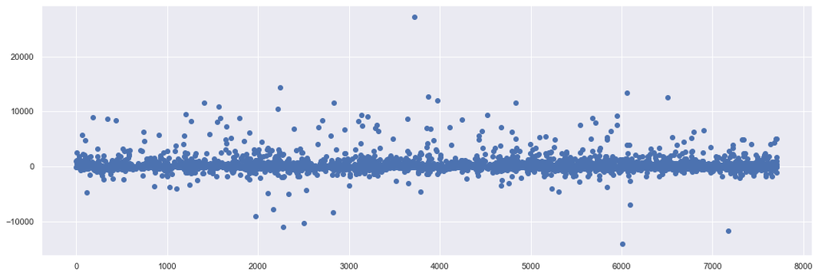

```python
plt.figure(figsize=(18,6))
plt.scatter(x=train_EW.index, y=train_EW['profit'])
```

```python
EW_df.quantile([0.05, 0.95, 0.98, 0.99, 0.999])
```

|  | record_id | order_id | unit_price | order_quantity | sales | profit | ship_cost | discount_sub_mean | discount_mean | discount_zero | ... | order_year | order_month | order_day | order_quarter | ship_yearmonth | ship_year | ship_month | ship_day | ship_quarter | lead_time |
| --- | --- | --- | --- | --- | --- | --- | --- | --- | --- | --- | --- | --- | --- | --- | --- | --- | --- | --- | --- | --- | --- |
| 0.050 | 298.00 | 2684.00 | 2.88 | 3.0 | 35.6956 | -542.31880 | 0.809 | 0.0 | 0.0 | 0.0 | ... | 2016.0 | 1.0 | 0.0 | 1.0 | 197001.0 | 1970.0 | 1.0 | 0.0 | 1.0 | -17359.0 |
| 0.950 | 5662.00 | 52102.00 | 320.98 | 48.0 | 7827.5156 | 1487.94120 | 55.819 | 0.1 | 0.1 | 0.1 | ... | 2019.0 | 12.0 | 6.0 | 4.0 | 201910.0 | 2019.0 | 12.0 | 6.0 | 4.0 | 7.0 |
| 0.980 | 5840.80 | 53885.00 | 500.98 | 50.0 | 14443.5616 | 3037.52920 | 69.009 | 0.1 | 0.1 | 0.1 | ... | 2019.0 | 12.0 | 6.0 | 4.0 | 201911.0 | 2019.0 | 12.0 | 6.0 | 4.0 | 7.0 |
| 0.990 | 5900.40 | 54392.80 | 880.98 | 50.0 | 18938.5016 | 5259.21740 | 71.869 | 0.1 | 0.1 | 0.1 | ... | 2019.0 | 12.0 | 6.0 | 4.0 | 201912.0 | 2019.0 | 12.0 | 6.0 | 4.0 | 9.0 |
| 0.999 | 5954.04 | 54934.48 | 3502.14 | 50.0 | 29192.8468 | 11644.31716 | 110.209 | 0.1 | 0.1 | 0.1 | ... | 2019.0 | 12.0 | 6.0 | 4.0 | 201912.0 | 2019.0 | 12.0 | 6.0 | 4.0 | 19.2 |

5 rows × 24 columns

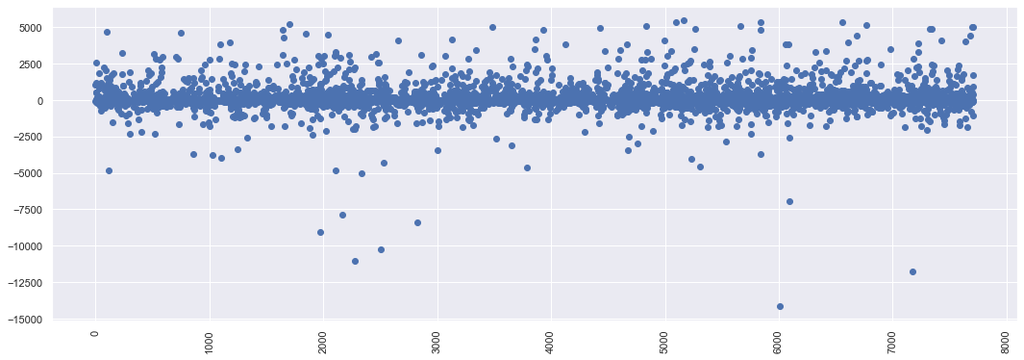

```python
EW_quantile = train_EW[train_EW["profit"] < 5500]
plt.figure(figsize=(18,6))
plt.scatter(x=EW_quantile.index, y=EW_quantile['profit'])
plt.xticks(rotation = 90);
```

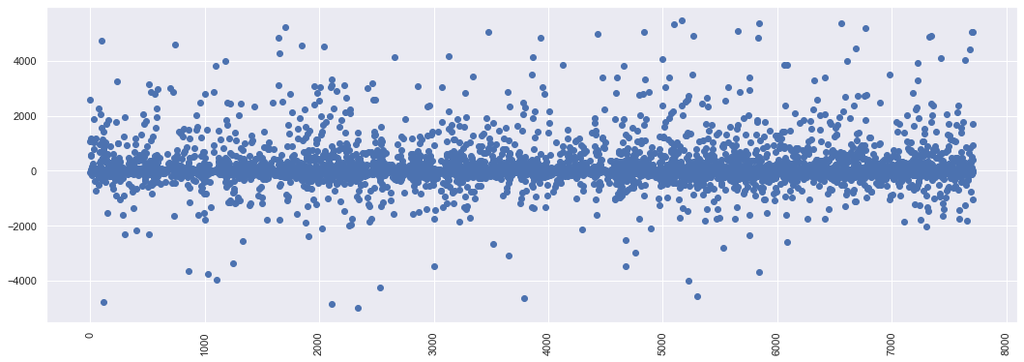

```python
EW_quantile = EW_quantile[EW_quantile["profit"] > -5000]
plt.figure(figsize=(18,6))
plt.scatter(x=EW_quantile.index, y=EW_quantile['profit'])
plt.xticks(rotation = 90);
```

## Trial 2

```python
from sklearn.preprocessing import StandardScaler
from sklearn.compose import ColumnTransformer

ct = ColumnTransformer([
                        ("scaling", StandardScaler(), ["unit_price", "order_quantity","sales","ship_cost","discount_sub_mean",
                                                       "product_base_margin_sub_mean", "order_month" ,"order_day"]),
                        ("onehot", OneHotEncoder(sparse = False), ['order_priority' , 'order_status' , "ship_mode" ,"customer_segment" ,
                                                                   'product_category' ,"product_sub_category" ,"product_container","state_name","region"])
])

OC2 = ct.fit_transform(EW_quantile)
OC2
```

```
array([[ 0.33,  0.31,  0.91, ...,  0.  ,  1.  ,  0.  ],
       [ 0.24,  0.31,  0.82, ...,  0.  ,  0.  ,  1.  ],
       [-0.35, -0.45, -0.53, ...,  0.  ,  0.  ,  0.  ],
       ...,
       [-0.32, -1.49, -0.53, ...,  0.  ,  0.  ,  0.  ],
       [-0.28, -1.14, -0.48, ...,  0.  ,  0.  ,  0.  ],
       [-0.34,  0.52, -0.5 , ...,  1.  ,  0.  ,  0.  ]])
```

### Linear Regression

```python
y = EW_quantile["profit"]
X = OC2
```

```python
from sklearn.model_selection import train_test_split

X_train, X_test, y_train, y_test = train_test_split(X, y, test_size = 0.2, random_state = 42)
```

```python
from sklearn.linear_model import LinearRegression

lr_model = LinearRegression()
lr_model.fit(X_train, y_train)
y_predict = lr_model.predict(X_test)
```

```python
train_performance = lr_model.score(X_train, y_train)
test_performance = lr_model.score(X_test, y_test)
print("예측결과: \n", y_predict)
print("훈련 성능: {}   테스트 성능: {}".format(train_performance, test_performance))
print(X_train)

np.set_printoptions(suppress=True, precision =2) #넘파이 결과가 지수형태로 나와서 보기 안좋아서 지수 제한
print("회귀식: {}  절편: {}".format(lr_model.coef_, lr_model.intercept_))
```

```
예측결과:
 [ 148.44  -91.88  530.22 ... -118.44  944.44 -130.47]
훈련 성능: 0.5747188210479925   테스트 성능: 0.5220541858980958
[[-0.32 -1.56 -0.53 ...  0.    1.    0.  ]
 [-0.12  1.07  0.16 ...  0.    0.    1.  ]
 [ 2.37  1.42  8.94 ...  0.    0.    0.  ]
 ...
 [ 0.19 -0.86 -0.   ...  0.    0.    0.  ]
 [-0.2  -0.24 -0.28 ...  0.    0.    0.  ]
 [ 0.1  -0.31  0.22 ...  0.    0.    1.  ]]
회귀식: [-3.71e+02 -9.00e+01  8.38e+02 -3.10e+02 -6.81e+00 -1.86e+02  7.27e+00
 -9.58e+00 -2.94e+13 -2.94e+13 -2.94e+13 -2.94e+13 -8.20e+13 -8.20e+13
 -8.96e+13 -8.96e+13 -8.96e+13 -1.38e+13 -1.38e+13 -1.38e+13 -1.38e+13
 -2.94e+13  4.93e+12 -6.33e+13 -1.32e+13 -1.32e+13  2.11e+13  2.11e+13
  5.51e+13  5.51e+13 -1.32e+13 -1.32e+13  2.11e+13  5.51e+13 -1.32e+13
 -1.32e+13 -1.32e+13 -1.32e+13 -1.32e+13  2.11e+13  5.51e+13 -4.31e+13
 -4.31e+13 -4.31e+13 -4.31e+13 -4.31e+13 -4.31e+13 -4.31e+13  4.74e+12
  3.38e+11  4.74e+12  3.38e+11  3.38e+11  2.01e+12  2.01e+12  4.74e+12
  4.74e+12  3.38e+11 -3.07e+12 -3.07e+12 -3.07e+12 -3.07e+12  4.74e+12
  4.74e+12  2.01e+12 -3.07e+12  2.01e+12  2.01e+12 -3.07e+12 -3.07e+12
  4.74e+12  3.38e+11 -3.07e+12  3.38e+11  2.01e+12  2.01e+12  3.38e+11
  2.01e+12  4.74e+12 -3.07e+12  2.01e+12 -3.07e+12  3.38e+11  2.01e+12
  2.01e+12  4.74e+12 -3.07e+12  4.74e+12 -3.07e+12  3.38e+11  2.01e+12
  4.74e+12  3.38e+11  2.01e+12 -3.07e+12  3.38e+11  1.10e+12 -3.99e+12
 -6.71e+12 -2.31e+12]  절편: 268125644319094.47
```

```python
from sklearn.metrics import mean_absolute_error
from sklearn.metrics import mean_squared_error

#mean_absolute_error(실제, 예측)
print("MAE:", mean_absolute_error(y_test, y_predict ))
print("RMSE:", mean_squared_error(y_test, y_predict))
```

```
MAE: 266.9690649200368
RMSE: 260265.81694419758
```

### Ridge

```python
from sklearn.linear_model import Ridge

Ridge = Ridge(alpha = 0.3)
Ridge.fit(X_train, y_train)
y_predict = Ridge.predict(X_test)
train_performance3 = Ridge.score(X_train, y_train)
test_performance3 = Ridge.score(X_test, y_test)
print("훈련 성능: {}   테스트 성능: {}".format(train_performance3, test_performance3))
print("MAE:", mean_absolute_error(y_test, y_predict ))
print("RMSE:", mean_squared_error(y_test, y_predict))

print("회귀계수: {}  절편:{}".format(Ridge.coef_, Ridge.intercept_))
```

```
훈련 성능: 0.5747018393126269   테스트 성능: 0.5229055397541171
MAE: 266.6151548261867
RMSE: 259802.21144686243
회귀계수: [ -370.61   -89.72   837.25  -309.12    -6.84  -185.39     7.18    -9.59
    -5.65    -0.03   -23.22    28.91   -19.18    19.18   310.46  -154.25
  -156.21    -0.33     0.33    -4.72     4.72   160.33    39.02  -199.35
   173.5    -79.97    56.16   168.51   340.02 -1154.14   -71.75  -207.04
     9.61   293.96  -142.5     72.91   106.95   146.77    40.15   -73.95
   320.81  -524.53  -353.17   218.75   223.26   190.59   126.45   118.65
    56.16    14.8     28.56    22.39   -46.18    21.06   -96.97   -39.82
    43.31   119.23     5.37   -32.88    25.17   -79.63    17.14    -4.59
    63.57    80.76   -20.88  -127.14   -12.2    114.49    52.53   -63.7
   -67.58     2.64    10.03   -39.53   -75.74    12.71   -22.29    68.3
    18.07    34.56    12.82    27.11    50.77   -18.74  -118.97  -101.2
    28.32    16.9    136.06    18.01   -93.71   -71.53   -43.23    75.66
     2.48   -16.66    29.07   -14.89]  절편:77.55882194815896
```

### Lasso

```python
from sklearn.linear_model import Lasso

Lasso = Lasso(alpha = 0.3)
Lasso.fit(X_train, y_train)
y_predict = Lasso.predict(X_test)
train_performance3 = Lasso.score(X_train, y_train)
test_performance3 = Lasso.score(X_test, y_test)
print("훈련 성능: {}   테스트 성능: {}".format(train_performance3, test_performance3))
print("MAE:", mean_absolute_error(y_test, y_predict ))
print("RMSE:", mean_squared_error(y_test, y_predict))

print("회귀계수: {}  절편:{}".format(Lasso.coef_, Lasso.intercept_))
```

```
훈련 성능: 0.573488654375027   테스트 성능: 0.528394548594266
MAE: 261.63250956942113
RMSE: 256813.16681493123
회귀계수: [ -370.61   -88.32   835.1   -306.47    -6.88  -176.78     6.67    -9.02
    -4.39     0.15   -21.44    28.13   -36.25     0.      -0.       0.
     0.      -0.       0.      -2.65     1.64    51.78   -35.32    -0.
   129.02  -105.96     0.     142.58    14.27 -1404.74   -92.28  -226.62
     0.      -5.51  -174.52    14.59    33.87    74.1     -0.    -109.53
     0.    -174.32   -21.27    66.88    78.54    49.72    -0.      -4.77
    28.28     0.       1.67     8.09   -43.96     0.      -0.     -39.34
    22.88    81.94     0.     -20.28     7.85   -59.9      0.      -0.
    31.91    63.64   -16.03  -130.97    -2.99   102.47     0.      -0.
   -42.04    -0.      -0.     -41.87   -48.53    -0.     -14.26     9.57
     0.       9.76     0.       0.       0.      -0.04   -48.45   -94.3
    22.08     0.      61.68     0.     -94.9    -31.43   -27.34     0.
     0.      -3.57    33.65    -5.47]  절편:193.79066145380983
```

### Decision Tree Regression

```python
from sklearn.tree import DecisionTreeRegressor
from sklearn.model_selection import train_test_split

tree1 = DecisionTreeRegressor(random_state=44)
tree1.fit(X_train, y_train)
y_predict = tree1.predict(X_test)

print("MAE:", mean_absolute_error(y_test, y_predict ))
print("RMSE:", mean_squared_error(y_test, y_predict))
```

```
MAE: 153.96563671231618
RMSE: 227175.6318772731
```

### Random Forest Regression

```python
from sklearn.ensemble import RandomForestRegressor
import math


# 30개 변수를 모두 이용하여 100개의 나무 생성 (정확도가 높아짐)

forest = RandomForestRegressor(random_state=43)
forest.fit(X_train, y_train)
y_predict = forest.predict(X_test)

print("MAE':{}".format(math.sqrt(mean_absolute_error(y_predict, y_test))) )
print("RMSE':{}".format(math.sqrt(mean_squared_error(y_predict, y_test))) )
```

```
MAE':10.53698612763753
RMSE':403.59195676823714
```

### XGBoost

```python
xgb = XGBRegressor(random_state=10)
xgb.fit(X_train, y_train)

y_predict = xgb.predict(X_test)

print("MAE':{}".format(math.sqrt(mean_absolute_error(y_predict, y_test))) )
print("RMSE':{}".format(math.sqrt(mean_squared_error(y_predict, y_test))) )
```

```
MAE':10.144916851386343
RMSE':404.0759220629305
```

### LightGBM

```python
lgbm = LGBMRegressor(random_state=10)
lgbm.fit(X_train, y_train)

y_predict = lgbm.predict(X_test)

print("MAE':{}".format(math.sqrt(mean_absolute_error(y_predict, y_test))) )
print("RMSE':{}".format(math.sqrt(mean_squared_error(y_predict, y_test))) )
```

```
MAE':10.577577212773381
RMSE':441.16719721305833
```

## Hyperparameter 튜닝

### Linear Regression

```python
from sklearn.model_selection import cross_val_score

first_scores_train = cross_val_score(lr_model, X_train, y_train, cv = 5, scoring = "neg_mean_absolute_error")
first_scores_train_1 = cross_val_score(lr_model, X_train, y_train, cv = 5, scoring = "neg_mean_squared_error")
first_scores_test = cross_val_score(lr_model, X_test, y_test, cv = 5, scoring = "neg_mean_absolute_error")
first_scores_test_1 = cross_val_score(lr_model, X_test, y_test, cv = 5, scoring = "neg_mean_squared_error")
second_scores_train = cross_val_score(lr_model, X_train, y_train, cv = 7, scoring = "neg_mean_absolute_error")
second_scores_train_1 = cross_val_score(lr_model, X_train, y_train, cv = 7, scoring = "neg_mean_squared_error")
second_scores_test = cross_val_score(lr_model, X_test, y_test, cv = 7, scoring = "neg_mean_absolute_error")
second_scores_test_1 = cross_val_score(lr_model, X_test, y_test, cv = 7, scoring = "neg_mean_squared_error")
third_scores_train = cross_val_score(lr_model, X_train, y_train, cv = 10, scoring = "neg_mean_absolute_error")
third_scores_train_1 = cross_val_score(lr_model, X_train, y_train, cv = 10, scoring = "neg_mean_squared_error")
third_scores_test = cross_val_score(lr_model, X_test, y_test, cv = 10, scoring = "neg_mean_absolute_error")
third_scores_test_1 = cross_val_score(lr_model, X_test, y_test, cv = 10, scoring = "neg_mean_squared_error")

print("MAE")
print("cv = 5 train : ", first_scores_train)
print("cv = 5 test : ", first_scores_test)
print("cv = 7 train : ", second_scores_train)
print("cv = 7 test : ", second_scores_test)
print("cv = 10 train : ", third_scores_train)
print("cv = 10 test : ", third_scores_test)

print("RMSE")
print("cv = 5 train : ", first_scores_train_1)
print("cv = 5 test : ", first_scores_test_1)
print("cv = 7 train : ", second_scores_train_1)
print("cv = 7 test : ", second_scores_test_1)
print("cv = 10 train : ", third_scores_train_1)
print("cv = 10 test : ", third_scores_test_1)

print("MAE mean")
print("cv = 5 train :{:.9f}".format(first_scores_train.mean()))
print("cv = 5 test :{:.9f}".format(first_scores_test.mean()))
print("cv = 7 train :{:.9f}".format(second_scores_train.mean()))
print("cv = 7 test :{:.9f}".format(second_scores_test.mean()))
print("cv = 10 train :{:.9f}".format(third_scores_train.mean()))
print("cv = 10 test :{:.9f}".format(third_scores_test.mean()))

print("RMSE mean")
print("cv = 5 train :{:.9f}".format(first_scores_train_1.mean()))
print("cv = 5 test :{:.9f}".format(first_scores_test_1.mean()))
print("cv = 7 train :{:.9f}".format(second_scores_train_1.mean()))
print("cv = 7 test :{:.9f}".format(second_scores_test_1.mean()))
print("cv = 10 train :{:.9f}".format(third_scores_train_1.mean()))
print("cv = 10 test :{:.9f}".format(third_scores_test_1.mean()))
```

```
MAE
cv = 5 train :  [-271.6  -248.83 -260.26 -312.21 -260.23]
cv = 5 test :  [-3.02e+02 -3.37e+02 -2.55e+02 -2.56e+02 -4.48e+11]
cv = 7 train :  [-266.73 -266.96 -243.66 -257.49 -307.14 -278.71 -252.66]
cv = 7 test :  [-2.77e+02 -3.84e+02 -3.12e+02 -2.59e+02 -2.68e+02 -3.26e+11 -7.21e+10]
cv = 10 train :  [-255.81 -283.77 -256.81 -235.86 -266.28 -250.59 -334.77 -277.44 -252.43
 -263.08]
cv = 10 test :  [-2.61e+02 -3.57e+02 -3.43e+02 -3.42e+02 -2.62e+02 -2.32e+02 -2.50e+02
 -2.53e+02 -5.33e+10 -2.97e+02]
RMSE
cv = 5 train :  [-324675.75 -181592.92 -239221.72 -377799.18 -228636.71]
cv = 5 test :  [-5.00e+05 -3.90e+05 -1.64e+05 -1.57e+05 -2.02e+25]
cv = 7 train :  [-334221.23 -235958.72 -169770.09 -230000.69 -368181.19 -276214.82
 -223089.16]
cv = 7 test :  [-2.09e+05 -9.39e+05 -3.73e+05 -1.79e+05 -1.91e+05 -1.64e+25 -4.03e+23]
cv = 10 train :  [-293256.99 -313973.12 -199978.95 -160610.28 -246455.82 -229117.62
 -434096.76 -280746.52 -223072.58 -236940.22]
cv = 10 test :  [-1.92e+05 -8.61e+05 -4.16e+05 -4.89e+05 -1.59e+05 -1.48e+05 -1.62e+05
 -1.42e+05 -3.07e+23 -1.98e+05]
MAE mean
cv = 5 train :-270.625740397
cv = 5 test :-89692229490.658309937
cv = 7 train :-267.620904639
cv = 7 test :-56834459028.340507507
cv = 10 train :-267.683352085
cv = 10 test :-5331826066.262464523
RMSE mean
cv = 5 train :-270385.257276795
cv = 5 test :-4031315624550488822775808.000000000
cv = 7 train :-262490.842653673
cv = 7 test :-2407218599251779673653248.000000000
cv = 10 train :-261824.885338735
cv = 10 test :-30702635389909465038848.000000000
```

### Random Forest

```python
forest = RandomForestRegressor(random_state=43)
forest.fit(X_train, y_train)
y_predict = forest.predict(X_test)

print("MAE':{}".format(math.sqrt(mean_absolute_error(y_predict, y_test))) )
print("RMSE':{}".format(math.sqrt(mean_squared_error(y_predict, y_test))) )
```

```
MAE':10.53698612763753
RMSE':403.59195676823714
```

```python
from sklearn.ensemble import RandomForestRegressor
import math

for i in (10,50,100,150,200,250,300):

  forest = RandomForestRegressor(n_estimators = i, random_state=43)
  forest.fit(X_train, y_train)
  y_predict = forest.predict(X_test)

  print("n_estimators':{}".format(forest.n_estimators) )
  print("MAE':{}".format(math.sqrt(mean_absolute_error(y_predict, y_test))) )
  print("RMSE':{}".format(math.sqrt(mean_squared_error(y_predict, y_test))) )
```

```
n_estimators':10
MAE':10.850689560583946
RMSE':404.95302309929457
n_estimators':50
MAE':10.514582044247037
RMSE':404.2082674601675
n_estimators':100
MAE':10.53698612763753
RMSE':403.59195676823714
n_estimators':150
MAE':10.543085411972545
RMSE':404.78217479548255
n_estimators':200
MAE':10.526335900266481
RMSE':404.74813764174223
n_estimators':250
MAE':10.53977651512338
RMSE':406.01840510191744
n_estimators':300
MAE':10.550619826403809
RMSE':408.33645198452297
```

```python
from sklearn.ensemble import RandomForestRegressor
import math

for i in (500,1000, 1500, 2000):

  forest = RandomForestRegressor(n_estimators = i, random_state=43)
  forest.fit(X_train, y_train)
  y_predict = forest.predict(X_test)

  print("n_estimators':{}".format(forest.n_estimators) )
  print("MAE':{}".format(math.sqrt(mean_absolute_error(y_predict, y_test))) )
  print("RMSE':{}".format(math.sqrt(mean_squared_error(y_predict, y_test))) )
```

```
n_estimators':500
MAE':10.54852015444261
RMSE':408.17344205210895
n_estimators':1000
MAE':10.564690902258906
RMSE':409.35396246916605
n_estimators':1500
MAE':10.588046956853194
RMSE':410.9496748716519
n_estimators':2000
MAE':10.591751880848303
RMSE':410.55332990974887
```

#### Grid Search

##### cv = 10

```python
#GRIDSEARCH를 이용한 최적화
from sklearn.model_selection import GridSearchCV

params = {
    'max_depth' : [3,4,5,6,7,8,9,10],
    "max_features" : [3,4,5,6,7,8,9,10],
    'min_samples_split' : [8,9,10,11,12]
}
randomforest = RandomForestRegressor(random_state=43)
grid_cv = GridSearchCV(randomforest, param_grid=params, n_jobs = -1, cv = 10, return_train_score=True)
grid_cv.fit(X_train, y_train)
print(grid_cv)

print("GridSearchCV 최적 파라미터 : ", grid_cv.best_params_)
print("GridSearchCV 최고 정확도 : {0:.4f}".format(grid_cv.best_score_))

grid_cv.fit(X_test, y_test)
print(grid_cv)

print("GridSearchCV 최적 파라미터 : ", grid_cv.best_params_)
print("GridSearchCV 최고 정확도 : {0:.4f}".format(grid_cv.best_score_))
```

```
GridSearchCV(cv=10, estimator=RandomForestRegressor(random_state=43), n_jobs=-1,
             param_grid={'max_depth': [3, 4, 5, 6, 7, 8, 9, 10],
                         'max_features': [3, 4, 5, 6, 7, 8, 9, 10],
                         'min_samples_split': [8, 9, 10, 11, 12]},
             return_train_score=True)
GridSearchCV 최적 파라미터 :  {'max_depth': 10, 'max_features': 10, 'min_samples_split': 8}
GridSearchCV 최고 정확도 : 0.5703
GridSearchCV(cv=10, estimator=RandomForestRegressor(random_state=43), n_jobs=-1,
             param_grid={'max_depth': [3, 4, 5, 6, 7, 8, 9, 10],
                         'max_features': [3, 4, 5, 6, 7, 8, 9, 10],
                         'min_samples_split': [8, 9, 10, 11, 12]},
             return_train_score=True)
GridSearchCV 최적 파라미터 :  {'max_depth': 10, 'max_features': 10, 'min_samples_split': 8}
GridSearchCV 최고 정확도 : 0.4635
```

```python
for i in (450,500,550,1000):
    forest = RandomForestRegressor(random_state=43, max_depth = 10, max_features = 10, min_samples_split = 8, n_estimators = i)
    forest.fit(X_train, y_train)
    y_predict = forest.predict(X_test)

    print("n_estimators':{}".format(forest.n_estimators) )
    print("MAE':{}".format(math.sqrt(mean_absolute_error(y_predict, y_test))) )
    print("RMSE':{}".format(math.sqrt(mean_squared_error(y_predict, y_test))) )
```

```
n_estimators':450
MAE':14.64656129808496
RMSE':475.4453213106288
n_estimators':500
MAE':14.635733608600436
RMSE':475.4393351911682
n_estimators':550
MAE':14.63827326975451
RMSE':475.71174069979327
n_estimators':1000
MAE':14.607067328322733
RMSE':475.0838668621706
```

```python
for i in (1500,2000,2300,2500):
    forest = RandomForestRegressor(random_state=43, max_depth = 10, max_features = 10, min_samples_split = 8, n_estimators = i)
    forest.fit(X_train, y_train)
    y_predict = forest.predict(X_test)

    print("n_estimators':{}".format(forest.n_estimators) )
    print("MAE':{}".format(math.sqrt(mean_absolute_error(y_predict, y_test))) )
    print("RMSE':{}".format(math.sqrt(mean_squared_error(y_predict, y_test))) )
```

```
n_estimators':1500
MAE':14.587110456506773
RMSE':474.1467556998762
n_estimators':2000
MAE':14.578796305723785
RMSE':473.53381081484883
n_estimators':2300
MAE':14.577977301138041
RMSE':473.38433152462244
n_estimators':2500
MAE':14.579336775047096
RMSE':473.2627931578959
```

```python
#GRIDSEARCH를 이용한 최적화
from sklearn.model_selection import GridSearchCV

params = {
    'max_depth' : [10,11,12,13,14,15],
    "max_features" : [10,11,12,13,14,15],
    'min_samples_split' : [8,9,10,11,12]
}
randomforest = RandomForestRegressor(random_state=43)
grid_cv = GridSearchCV(randomforest, param_grid=params, n_jobs = -1, cv = 10, return_train_score=True)
grid_cv.fit(X_train, y_train)
print(grid_cv)

print("GridSearchCV 최적 파라미터 : ", grid_cv.best_params_)
print("GridSearchCV 최고 정확도 : {0:.4f}".format(grid_cv.best_score_))

grid_cv.fit(X_test, y_test)
print(grid_cv)

print("GridSearchCV 최적 파라미터 : ", grid_cv.best_params_)
print("GridSearchCV 최고 정확도 : {0:.4f}".format(grid_cv.best_score_))
```

```
GridSearchCV(cv=10, estimator=RandomForestRegressor(random_state=43), n_jobs=-1,
             param_grid={'max_depth': [10, 11, 12, 13, 14, 15],
                         'max_features': [10, 11, 12, 13, 14, 15],
                         'min_samples_split': [8, 9, 10, 11, 12]},
             return_train_score=True)
GridSearchCV 최적 파라미터 :  {'max_depth': 15, 'max_features': 15, 'min_samples_split': 9}
GridSearchCV 최고 정확도 : 0.6782
GridSearchCV(cv=10, estimator=RandomForestRegressor(random_state=43), n_jobs=-1,
             param_grid={'max_depth': [10, 11, 12, 13, 14, 15],
                         'max_features': [10, 11, 12, 13, 14, 15],
                         'min_samples_split': [8, 9, 10, 11, 12]},
             return_train_score=True)
GridSearchCV 최적 파라미터 :  {'max_depth': 14, 'max_features': 15, 'min_samples_split': 9}
GridSearchCV 최고 정확도 : 0.5442
```

```python
for i in (500,2300,2400,2500):
    forest = RandomForestRegressor(random_state=43, max_depth = 15, max_features = 15, min_samples_split = 9, n_estimators=i)
    forest.fit(X_train, y_train)
    y_predict = forest.predict(X_test)

    print("n_estimators':{}".format(forest.n_estimators) )
    print("MAE':{}".format(math.sqrt(mean_absolute_error(y_predict, y_test))) )
    print("RMSE':{}".format(math.sqrt(mean_squared_error(y_predict, y_test))) )
```

```
n_estimators':500
MAE':12.376625471340741
RMSE':415.384279799512
n_estimators':2300
MAE':12.408658590166619
RMSE':417.84596452710645
n_estimators':2400
MAE':12.40666867192379
RMSE':417.70091856022856
n_estimators':2500
MAE':12.407334018542235
RMSE':417.81987842360655
```

```python
for i in (500,2300,2400,2500):
    forest = RandomForestRegressor(random_state=43, max_depth = 14, max_features = 15, min_samples_split = 9, n_estimators=i)
    forest.fit(X_train, y_train)
    y_predict = forest.predict(X_test)

    print("n_estimators':{}".format(forest.n_estimators) )
    print("MAE':{}".format(math.sqrt(mean_absolute_error(y_predict, y_test))) )
    print("RMSE':{}".format(math.sqrt(mean_squared_error(y_predict, y_test))) )
```

```
n_estimators':500
MAE':12.492617166004475
RMSE':417.6395068435298
n_estimators':2300
MAE':12.507379145498236
RMSE':418.43403984022194
n_estimators':2400
MAE':12.511310389840013
RMSE':418.52701523220384
n_estimators':2500
MAE':12.510628460179436
RMSE':418.3166914100128
```

##### cv = 5

```python
#GRIDSEARCH를 이용한 최적화
from sklearn.model_selection import GridSearchCV

params = {
    'max_depth' : [10,11,12,13,14,15],
    "max_features" : [10,11,12,13,14,15],
    'min_samples_split' : [8,9,10,11,12]
}
randomforest = RandomForestRegressor(random_state=43)
grid_cv = GridSearchCV(randomforest, param_grid=params, n_jobs = -1, cv = 5, return_train_score=True)
grid_cv.fit(X_train, y_train)
print(grid_cv)

print("GridSearchCV 최적 파라미터 : ", grid_cv.best_params_)
print("GridSearchCV 최고 정확도 : {0:.4f}".format(grid_cv.best_score_))

grid_cv.fit(X_test, y_test)
print(grid_cv)

print("GridSearchCV 최적 파라미터 : ", grid_cv.best_params_)
print("GridSearchCV 최고 정확도 : {0:.4f}".format(grid_cv.best_score_))
```

```
GridSearchCV(cv=5, estimator=RandomForestRegressor(random_state=43), n_jobs=-1,
             param_grid={'max_depth': [10, 11, 12, 13, 14, 15],
                         'max_features': [10, 11, 12, 13, 14, 15],
                         'min_samples_split': [8, 9, 10, 11, 12]},
             return_train_score=True)
GridSearchCV 최적 파라미터 :  {'max_depth': 15, 'max_features': 15, 'min_samples_split': 8}
GridSearchCV 최고 정확도 : 0.6615
GridSearchCV(cv=5, estimator=RandomForestRegressor(random_state=43), n_jobs=-1,
             param_grid={'max_depth': [10, 11, 12, 13, 14, 15],
                         'max_features': [10, 11, 12, 13, 14, 15],
                         'min_samples_split': [8, 9, 10, 11, 12]},
             return_train_score=True)
GridSearchCV 최적 파라미터 :  {'max_depth': 12, 'max_features': 15, 'min_samples_split': 8}
GridSearchCV 최고 정확도 : 0.5200
```

```python
for i in (500,2300,2400,2500):
    forest = RandomForestRegressor(random_state=43, max_depth = 15, max_features = 15, min_samples_split = 8, n_estimators=i)
    forest.fit(X_train, y_train)
    y_predict = forest.predict(X_test)

    print("n_estimators':{}".format(forest.n_estimators) )
    print("MAE':{}".format(math.sqrt(mean_absolute_error(y_predict, y_test))) )
    print("RMSE':{}".format(math.sqrt(mean_squared_error(y_predict, y_test))) )
```

```
n_estimators':500
MAE':12.299014606933145
RMSE':413.5342965762295
n_estimators':2300
MAE':12.352523924825716
RMSE':415.46902923741294
n_estimators':2400
MAE':12.350090345231433
RMSE':415.47286792573965
n_estimators':2500
MAE':12.345910528560108
RMSE':415.16311869381326
```

```python
for i in (500,2300,2400,2500):
    forest = RandomForestRegressor(random_state=43, max_depth = 12, max_features = 15, min_samples_split = 8, n_estimators=i)
    forest.fit(X_train, y_train)
    y_predict = forest.predict(X_test)

    print("n_estimators':{}".format(forest.n_estimators) )
    print("MAE':{}".format(math.sqrt(mean_absolute_error(y_predict, y_test))) )
    print("RMSE':{}".format(math.sqrt(mean_squared_error(y_predict, y_test))) )
```

```
n_estimators':500
MAE':12.819574197399698
RMSE':420.5452045618938
n_estimators':2300
MAE':12.825874961813621
RMSE':420.5096577959077
n_estimators':2400
MAE':12.829905155248422
RMSE':420.5298867635841
n_estimators':2500
MAE':12.831357603665525
RMSE':420.7371076297903
```

##### cv = 7

```python
#GRIDSEARCH를 이용한 최적화
from sklearn.model_selection import GridSearchCV

params = {
    'max_depth' : [10,11,12,13,14,15],
    "max_features" : [10,11,12,13,14,15],
    'min_samples_split' : [8,9,10,11,12]
}
randomforest = RandomForestRegressor(random_state=43)
grid_cv = GridSearchCV(randomforest, param_grid=params, n_jobs = -1, cv = 7, return_train_score=True)
grid_cv.fit(X_train, y_train)
print(grid_cv)

print("GridSearchCV 최적 파라미터 : ", grid_cv.best_params_)
print("GridSearchCV 최고 정확도 : {0:.4f}".format(grid_cv.best_score_))

grid_cv.fit(X_test, y_test)
print(grid_cv)

print("GridSearchCV 최적 파라미터 : ", grid_cv.best_params_)
print("GridSearchCV 최고 정확도 : {0:.4f}".format(grid_cv.best_score_))
```

```
GridSearchCV(cv=7, estimator=RandomForestRegressor(random_state=43), n_jobs=-1,
             param_grid={'max_depth': [10, 11, 12, 13, 14, 15],
                         'max_features': [10, 11, 12, 13, 14, 15],
                         'min_samples_split': [8, 9, 10, 11, 12]},
             return_train_score=True)
GridSearchCV 최적 파라미터 :  {'max_depth': 15, 'max_features': 14, 'min_samples_split': 8}
GridSearchCV 최고 정확도 : 0.6693
GridSearchCV(cv=7, estimator=RandomForestRegressor(random_state=43), n_jobs=-1,
             param_grid={'max_depth': [10, 11, 12, 13, 14, 15],
                         'max_features': [10, 11, 12, 13, 14, 15],
                         'min_samples_split': [8, 9, 10, 11, 12]},
             return_train_score=True)
GridSearchCV 최적 파라미터 :  {'max_depth': 12, 'max_features': 15, 'min_samples_split': 8}
GridSearchCV 최고 정확도 : 0.5377
```

```python
for i in (500,2300,2400,2500):
    forest = RandomForestRegressor(random_state=43, max_depth = 15, max_features = 14, min_samples_split = 8, n_estimators=i)
    forest.fit(X_train, y_train)
    y_predict = forest.predict(X_test)

    print("n_estimators':{}".format(forest.n_estimators) )
    print("MAE':{}".format(math.sqrt(mean_absolute_error(y_predict, y_test))) )
    print("RMSE':{}".format(math.sqrt(mean_squared_error(y_predict, y_test))) )
```

```
n_estimators':500
MAE':12.53268766055189
RMSE':417.08726589584495
n_estimators':2300
MAE':12.543589873818622
RMSE':418.6706772971094
n_estimators':2400
MAE':12.544112934907188
RMSE':418.8905404148414
n_estimators':2500
MAE':12.544325666781086
RMSE':419.1070345965327
```

```python
for i in (500,2300,2400,2500):
    forest = RandomForestRegressor(random_state=43, max_depth = 12, max_features = 15, min_samples_split = 8, n_estimators=i)
    forest.fit(X_train, y_train)
    y_predict = forest.predict(X_test)

    print("n_estimators':{}".format(forest.n_estimators) )
    print("MAE':{}".format(math.sqrt(mean_absolute_error(y_predict, y_test))) )
    print("RMSE':{}".format(math.sqrt(mean_squared_error(y_predict, y_test))) )
```

```
n_estimators':500
MAE':12.819574197399698
RMSE':420.5452045618938
n_estimators':2300
MAE':12.825874961813621
RMSE':420.5096577959077
n_estimators':2400
MAE':12.829905155248422
RMSE':420.5298867635841
n_estimators':2500
MAE':12.831357603665525
RMSE':420.7371076297903
```

### XGBoost

#### Grid Search

##### cv = 10

```python
#GRIDSEARCH를 이용한 최적화
from sklearn.model_selection import GridSearchCV

params = { "eta" : (0.01,0.05,0.1,0.15,0.2),
          'max_depth' : (3,4,5,6,7,8,9,10),
          'learning_rate':(0.01, 0.1),
          'gamma': (0.5, 1, 2)
}
xgb = XGBRegressor(random_state=10)
grid_cv = GridSearchCV(xgb, param_grid = params, n_jobs=-1, cv = 10 )
grid_cv.fit(X_train, y_train)
print(grid_cv)

print("GridSearchCV 최적 파라미터 : ", grid_cv.best_params_)
print("GridSearchCV 최고 정확도 : {0:.4f}".format(grid_cv.best_score_))

grid_cv.fit(X_test, y_test)
print(grid_cv)

print("GridSearchCV 최적 파라미터 : ", grid_cv.best_params_)
print("GridSearchCV 최고 정확도 : {0:.4f}".format(grid_cv.best_score_))
```

```
GridSearchCV(cv=10,
             estimator=XGBRegressor(base_score=None, booster=None,
                                    callbacks=None, colsample_bylevel=None,
                                    colsample_bynode=None,
                                    colsample_bytree=None,
                                    early_stopping_rounds=None,
                                    enable_categorical=False, eval_metric=None,
                                    gamma=None, gpu_id=None, grow_policy=None,
                                    importance_type=None,
                                    interaction_constraints=None,
                                    learning_rate=None, max_bin=None,
                                    max_ca...step=None,
                                    max_depth=None, max_leaves=None,
                                    min_child_weight=None, missing=nan,
                                    monotone_constraints=None, n_estimators=100,
                                    n_jobs=None, num_parallel_tree=None,
                                    predictor=None, random_state=10,
                                    reg_alpha=None, reg_lambda=None, ...),
             n_jobs=-1,
             param_grid={'eta': (0.01, 0.05, 0.1, 0.15, 0.2),
                         'gamma': (0.5, 1, 2), 'learning_rate': (0.01, 0.1),
                         'max_depth': (3, 4, 5, 6, 7, 8, 9, 10)})
GridSearchCV 최적 파라미터 :  {'eta': 0.01, 'gamma': 0.5, 'learning_rate': 0.1, 'max_depth': 4}
GridSearchCV 최고 정확도 : 0.7280
GridSearchCV(cv=10,
             estimator=XGBRegressor(base_score=None, booster=None,
                                    callbacks=None, colsample_bylevel=None,
                                    colsample_bynode=None,
                                    colsample_bytree=None,
                                    early_stopping_rounds=None,
                                    enable_categorical=False, eval_metric=None,
                                    gamma=None, gpu_id=None, grow_policy=None,
                                    importance_type=None,
                                    interaction_constraints=None,
                                    learning_rate=None, max_bin=None,
                                    max_ca...step=None,
                                    max_depth=None, max_leaves=None,
                                    min_child_weight=None, missing=nan,
                                    monotone_constraints=None, n_estimators=100,
                                    n_jobs=None, num_parallel_tree=None,
                                    predictor=None, random_state=10,
                                    reg_alpha=None, reg_lambda=None, ...),
             n_jobs=-1,
             param_grid={'eta': (0.01, 0.05, 0.1, 0.15, 0.2),
                         'gamma': (0.5, 1, 2), 'learning_rate': (0.01, 0.1),
                         'max_depth': (3, 4, 5, 6, 7, 8, 9, 10)})
GridSearchCV 최적 파라미터 :  {'eta': 0.01, 'gamma': 0.5, 'learning_rate': 0.1, 'max_depth': 4}
GridSearchCV 최고 정확도 : 0.6550
```

```python
for i in (500,1000,1500,2000,2300,2500,3000):
    xgb = XGBRegressor(random_state=43, eta = 0.01, gamma = 0.5, learning_rate = 0.1, max_depth = 4, n_estimators = i)
    xgb.fit(X_train, y_train)

    y_predict = xgb.predict(X_test)

    print("n_estimators':{}".format(xgb.n_estimators) )
    print("MAE':{}".format(math.sqrt(mean_absolute_error(y_predict, y_test))) )
    print("RMSE':{}".format(math.sqrt(mean_squared_error(y_predict, y_test))) )
```

```
n_estimators':500
MAE':9.893054997828322
RMSE':400.0140593161956
n_estimators':1000
MAE':9.771529471746884
RMSE':400.4928956841036
n_estimators':1500
MAE':9.731991377064338
RMSE':400.41180449372496
n_estimators':2000
MAE':9.720807647557374
RMSE':400.59855385931246
n_estimators':2300
MAE':9.717463993219738
RMSE':400.59271480195196
n_estimators':2500
MAE':9.71534430011353
RMSE':400.5851486291537
n_estimators':3000
MAE':9.710626921568295
RMSE':400.60997061598675
```

```python
for i in (3500,3800,4000,4300,4500):
    xgb = XGBRegressor(random_state=43, eta = 0.01, gamma = 0.5, learning_rate = 0.1, max_depth = 4, n_estimators = i)
    xgb.fit(X_train, y_train)

    y_predict = xgb.predict(X_test)

    print("n_estimators':{}".format(xgb.n_estimators) )
    print("MAE':{}".format(math.sqrt(mean_absolute_error(y_predict, y_test))) )
    print("RMSE':{}".format(math.sqrt(mean_squared_error(y_predict, y_test))) )
```

```
n_estimators':3500
MAE':9.711339863375843
RMSE':400.6442555865115
n_estimators':3800
MAE':9.711516527744834
RMSE':400.65543131458827
n_estimators':4000
MAE':9.711664217676498
RMSE':400.65654640160767
n_estimators':4300
MAE':9.710863816368747
RMSE':400.6336580194754
n_estimators':4500
MAE':9.711411857889757
RMSE':400.638852058694
```

```python
for i in (3100,3200,3300,3400):
    xgb = XGBRegressor(random_state=43, eta = 0.01, gamma = 0.5, learning_rate = 0.1, max_depth = 4, n_estimators = i)
    xgb.fit(X_train, y_train)

    y_predict = xgb.predict(X_test)

    print("n_estimators':{}".format(xgb.n_estimators) )
    print("MAE':{}".format(math.sqrt(mean_absolute_error(y_predict, y_test))) )
    print("RMSE':{}".format(math.sqrt(mean_squared_error(y_predict, y_test))) )
```

```
n_estimators':3100
MAE':9.710687973076354
RMSE':400.61037799726114
n_estimators':3200
MAE':9.710744230805664
RMSE':400.61529529274964
n_estimators':3300
MAE':9.711353084028845
RMSE':400.63343492172896
n_estimators':3400
MAE':9.711819638363652
RMSE':400.6320098755009
```

##### cv = 5

```python
#GRIDSEARCH를 이용한 최적화
from sklearn.model_selection import GridSearchCV

params = { "eta" : (0.01,0.05,0.1,0.15,0.2),
          'max_depth' : (3,4,5,6,7,8,9,10),
          'learning_rate':(0.01, 0.1),
          'gamma': (0.5, 1, 2)
}
xgboo = XGBRegressor(random_state=10)
grid_cv = GridSearchCV(xgboo, param_grid = params, n_jobs=-1, cv = 5 )
grid_cv.fit(X_train, y_train)
print(grid_cv)

print("GridSearchCV 최적 파라미터 : ", grid_cv.best_params_)
print("GridSearchCV 최고 정확도 : {0:.4f}".format(grid_cv.best_score_))

grid_cv.fit(X_test, y_test)
print(grid_cv)

print("GridSearchCV 최적 파라미터 : ", grid_cv.best_params_)
print("GridSearchCV 최고 정확도 : {0:.4f}".format(grid_cv.best_score_))
```

```
GridSearchCV(cv=5,
             estimator=XGBRegressor(base_score=None, booster=None,
                                    callbacks=None, colsample_bylevel=None,
                                    colsample_bynode=None,
                                    colsample_bytree=None,
                                    early_stopping_rounds=None,
                                    enable_categorical=False, eval_metric=None,
                                    gamma=None, gpu_id=None, grow_policy=None,
                                    importance_type=None,
                                    interaction_constraints=None,
                                    learning_rate=None, max_bin=None,
                                    max_cat...step=None,
                                    max_depth=None, max_leaves=None,
                                    min_child_weight=None, missing=nan,
                                    monotone_constraints=None, n_estimators=100,
                                    n_jobs=None, num_parallel_tree=None,
                                    predictor=None, random_state=10,
                                    reg_alpha=None, reg_lambda=None, ...),
             n_jobs=-1,
             param_grid={'eta': (0.01, 0.05, 0.1, 0.15, 0.2),
                         'gamma': (0.5, 1, 2), 'learning_rate': (0.01, 0.1),
                         'max_depth': (3, 4, 5, 6, 7, 8, 9, 10)})
GridSearchCV 최적 파라미터 :  {'eta': 0.01, 'gamma': 0.5, 'learning_rate': 0.1, 'max_depth': 4}
GridSearchCV 최고 정확도 : 0.7220
GridSearchCV(cv=5,
             estimator=XGBRegressor(base_score=None, booster=None,
                                    callbacks=None, colsample_bylevel=None,
                                    colsample_bynode=None,
                                    colsample_bytree=None,
                                    early_stopping_rounds=None,
                                    enable_categorical=False, eval_metric=None,
                                    gamma=None, gpu_id=None, grow_policy=None,
                                    importance_type=None,
                                    interaction_constraints=None,
                                    learning_rate=None, max_bin=None,
                                    max_cat...step=None,
                                    max_depth=None, max_leaves=None,
                                    min_child_weight=None, missing=nan,
                                    monotone_constraints=None, n_estimators=100,
                                    n_jobs=None, num_parallel_tree=None,
                                    predictor=None, random_state=10,
                                    reg_alpha=None, reg_lambda=None, ...),
             n_jobs=-1,
             param_grid={'eta': (0.01, 0.05, 0.1, 0.15, 0.2),
                         'gamma': (0.5, 1, 2), 'learning_rate': (0.01, 0.1),
                         'max_depth': (3, 4, 5, 6, 7, 8, 9, 10)})
GridSearchCV 최적 파라미터 :  {'eta': 0.01, 'gamma': 0.5, 'learning_rate': 0.1, 'max_depth': 4}
GridSearchCV 최고 정확도 : 0.6242
```

##### cv = 7

```python
#GRIDSEARCH를 이용한 최적화
from sklearn.model_selection import GridSearchCV

params = { "eta" : (0.01,0.05,0.1,0.15,0.2),
          'max_depth' : (3,4,5,6,7,8,9,10),
          'learning_rate':(0.01, 0.1),
          'gamma': (0.5, 1, 2)
}
xgb = XGBRegressor(random_state=10)
grid_cv = GridSearchCV(xgb, param_grid = params, n_jobs=-1, cv = 7 )
grid_cv.fit(X_train, y_train)
print(grid_cv)

print("GridSearchCV 최적 파라미터 : ", grid_cv.best_params_)
print("GridSearchCV 최고 정확도 : {0:.4f}".format(grid_cv.best_score_))

grid_cv.fit(X_test, y_test)
print(grid_cv)

print("GridSearchCV 최적 파라미터 : ", grid_cv.best_params_)
print("GridSearchCV 최고 정확도 : {0:.4f}".format(grid_cv.best_score_))
```

```
GridSearchCV(cv=7,
             estimator=XGBRegressor(base_score=None, booster=None,
                                    callbacks=None, colsample_bylevel=None,
                                    colsample_bynode=None,
                                    colsample_bytree=None,
                                    early_stopping_rounds=None,
                                    enable_categorical=False, eval_metric=None,
                                    gamma=None, gpu_id=None, grow_policy=None,
                                    importance_type=None,
                                    interaction_constraints=None,
                                    learning_rate=None, max_bin=None,
                                    max_cat...step=None,
                                    max_depth=None, max_leaves=None,
                                    min_child_weight=None, missing=nan,
                                    monotone_constraints=None, n_estimators=100,
                                    n_jobs=None, num_parallel_tree=None,
                                    predictor=None, random_state=10,
                                    reg_alpha=None, reg_lambda=None, ...),
             n_jobs=-1,
             param_grid={'eta': (0.01, 0.05, 0.1, 0.15, 0.2),
                         'gamma': (0.5, 1, 2), 'learning_rate': (0.01, 0.1),
                         'max_depth': (3, 4, 5, 6, 7, 8, 9, 10)})
GridSearchCV 최적 파라미터 :  {'eta': 0.01, 'gamma': 0.5, 'learning_rate': 0.1, 'max_depth': 5}
GridSearchCV 최고 정확도 : 0.7279
GridSearchCV(cv=7,
             estimator=XGBRegressor(base_score=None, booster=None,
                                    callbacks=None, colsample_bylevel=None,
                                    colsample_bynode=None,
                                    colsample_bytree=None,
                                    early_stopping_rounds=None,
                                    enable_categorical=False, eval_metric=None,
                                    gamma=None, gpu_id=None, grow_policy=None,
                                    importance_type=None,
                                    interaction_constraints=None,
                                    learning_rate=None, max_bin=None,
                                    max_cat...step=None,
                                    max_depth=None, max_leaves=None,
                                    min_child_weight=None, missing=nan,
                                    monotone_constraints=None, n_estimators=100,
                                    n_jobs=None, num_parallel_tree=None,
                                    predictor=None, random_state=10,
                                    reg_alpha=None, reg_lambda=None, ...),
             n_jobs=-1,
             param_grid={'eta': (0.01, 0.05, 0.1, 0.15, 0.2),
                         'gamma': (0.5, 1, 2), 'learning_rate': (0.01, 0.1),
                         'max_depth': (3, 4, 5, 6, 7, 8, 9, 10)})
GridSearchCV 최적 파라미터 :  {'eta': 0.01, 'gamma': 0.5, 'learning_rate': 0.1, 'max_depth': 4}
GridSearchCV 최고 정확도 : 0.6401
```

```python
for i in (500,1000,1500,2000,2300,2500,3000):
    xgb = XGBRegressor(random_state=43, eta = 0.01, gamma = 0.5, learning_rate = 0.1, max_depth = 5, n_estimators = i)
    xgb.fit(X_train, y_train)

    y_predict = xgb.predict(X_test)

    print("n_estimators':{}".format(xgb.n_estimators) )
    print("MAE':{}".format(math.sqrt(mean_absolute_error(y_predict, y_test))) )
    print("RMSE':{}".format(math.sqrt(mean_squared_error(y_predict, y_test))) )
```

```
n_estimators':500
MAE':9.93272660888937
RMSE':404.7887252415117
n_estimators':1000
MAE':9.87020647920149
RMSE':404.9199602828307
n_estimators':1500
MAE':9.86826960009077
RMSE':404.9356025164341
n_estimators':2000
MAE':9.867449145894534
RMSE':404.9347896580974
n_estimators':2300
MAE':9.86762296669353
RMSE':404.9478171784624
n_estimators':2500
MAE':9.867530491367418
RMSE':404.9571865503766
n_estimators':3000
MAE':9.867530497490485
RMSE':404.957186558512
```

```python
for i in (3500,3800,4000,4300,4500):
    xgb = XGBRegressor(random_state=43, eta = 0.01, gamma = 0.5, learning_rate = 0.1, max_depth = 5, n_estimators = i)
    xgb.fit(X_train, y_train)

    y_predict = xgb.predict(X_test)

    print("n_estimators':{}".format(xgb.n_estimators) )
    print("MAE':{}".format(math.sqrt(mean_absolute_error(y_predict, y_test))) )
    print("RMSE':{}".format(math.sqrt(mean_squared_error(y_predict, y_test))) )
```

```
n_estimators':3500
MAE':9.86753049942741
RMSE':404.9571865578991
n_estimators':3800
MAE':9.867530500260196
RMSE':404.9571865579548
n_estimators':4000
MAE':9.867530500797345
RMSE':404.95718655799584
n_estimators':4300
MAE':9.867530501421935
RMSE':404.9571865580974
n_estimators':4500
MAE':9.867530501838328
RMSE':404.95718655816523
```

```python
for i in (3100,3200,3300,3400):
    xgb = XGBRegressor(random_state=43, eta = 0.01, gamma = 0.5, learning_rate = 0.1, max_depth = 5, n_estimators = i)
    xgb.fit(X_train, y_train)

    y_predict = xgb.predict(X_test)

    print("n_estimators':{}".format(xgb.n_estimators) )
    print("MAE':{}".format(math.sqrt(mean_absolute_error(y_predict, y_test))) )
    print("RMSE':{}".format(math.sqrt(mean_squared_error(y_predict, y_test))) )
```

```
n_estimators':3100
MAE':9.867530498031103
RMSE':404.95718655839227
n_estimators':3200
MAE':9.867530498508568
RMSE':404.9571865582817
n_estimators':3300
MAE':9.867530498855562
RMSE':404.95718655812493
n_estimators':3400
MAE':9.867530499149813
RMSE':404.95718655797975
```

### LightGBM

##### cv = 10

```python
#GRIDSEARCH를 이용한 최적화
from sklearn.model_selection import GridSearchCV

params = { "learning_rate" : (0.05, 0.06, 0.07, 0.08, 0.09, 0.1),
          'max_depth' : (3,4,5,6,7,8,9,10),
          'n_estimators' : (500,1000,1500,2000)
}
lgbm = LGBMRegressor(random_state=43)
grid_cv = GridSearchCV(lgbm, param_grid = params, n_jobs=-1, cv = 10)
grid_cv.fit(X_train, y_train)
print(grid_cv)

print("GridSearchCV 최적 파라미터 : ", grid_cv.best_params_)
print("GridSearchCV 최고 정확도 : {0:.4f}".format(grid_cv.best_score_))

grid_cv.fit(X_test, y_test)
print(grid_cv)

print("GridSearchCV 최적 파라미터 : ", grid_cv.best_params_)
print("GridSearchCV 최고 정확도 : {0:.4f}".format(grid_cv.best_score_))
```

```
GridSearchCV(cv=10, estimator=LGBMRegressor(random_state=43), n_jobs=-1,
             param_grid={'learning_rate': (0.05, 0.06, 0.07, 0.08, 0.09, 0.1),
                         'max_depth': (3, 4, 5, 6, 7, 8, 9, 10),
                         'n_estimators': (500, 1000, 1500, 2000)})
GridSearchCV 최적 파라미터 :  {'learning_rate': 0.05, 'max_depth': 5, 'n_estimators': 500}
GridSearchCV 최고 정확도 : 0.7079
GridSearchCV(cv=10, estimator=LGBMRegressor(random_state=43), n_jobs=-1,
             param_grid={'learning_rate': (0.05, 0.06, 0.07, 0.08, 0.09, 0.1),
                         'max_depth': (3, 4, 5, 6, 7, 8, 9, 10),
                         'n_estimators': (500, 1000, 1500, 2000)})
GridSearchCV 최적 파라미터 :  {'learning_rate': 0.06, 'max_depth': 4, 'n_estimators': 500}
GridSearchCV 최고 정확도 : 0.6707
```

```python
for i in (500,700,1000,1500,2000,2300):
    lgbm = LGBMRegressor(random_state=43, learning_rate = 0.06, max_depth = 15, n_estimators = i)
    lgbm.fit(X_train, y_train)

    y_predict = lgbm.predict(X_test)

    print("n_estimators':{}".format(lgbm.n_estimators) )
    print("MAE':{}".format(math.sqrt(mean_absolute_error(y_predict, y_test))) )
    print("RMSE':{}".format(math.sqrt(mean_squared_error(y_predict, y_test))) )
```

```
n_estimators':500
MAE':10.38468506078643
RMSE':445.7478968041202
n_estimators':700
MAE':10.326854965097276
RMSE':448.10607335384196
n_estimators':1000
MAE':10.309005014794746
RMSE':451.0379762824888
n_estimators':1500
MAE':10.374472596889099
RMSE':455.3250709431549
n_estimators':2000
MAE':10.395345957654701
RMSE':458.833681431061
n_estimators':2300
MAE':10.405373500405956
RMSE':459.3017291260261
```

```python
for i in (500,700,1000,1500,2000):
    lgbm = LGBMRegressor(random_state=43, learning_rate = 0.07, max_depth = 5, n_estimators = i)
    lgbm.fit(X_train, y_train)

    y_predict = lgbm.predict(X_test)

    print("n_estimators':{}".format(lgbm.n_estimators) )
    print("MAE':{}".format(math.sqrt(mean_absolute_error(y_predict, y_test))) )
    print("RMSE':{}".format(math.sqrt(mean_squared_error(y_predict, y_test))) )
```

```
n_estimators':500
MAE':10.607731391991665
RMSE':435.8632959882312
n_estimators':700
MAE':10.519466166406415
RMSE':437.68188245871755
n_estimators':1000
MAE':10.38001327427322
RMSE':438.95750644307367
n_estimators':1500
MAE':10.316435332278667
RMSE':437.72780020014267
n_estimators':2000
MAE':10.27320393799874
RMSE':437.63163111863537
```

##### cv = 5

```python
#GRIDSEARCH를 이용한 최적화
from sklearn.model_selection import GridSearchCV

params = { "learning_rate" : (0.05, 0.06, 0.07, 0.08, 0.09, 0.1),
          'max_depth' : (2,3,4,5,6,7,8,9,10,11,12,13,14),
          'n_estimators' : (500,1000,1500,2000)
}
lgbm = LGBMRegressor(random_state=43)
grid_cv = GridSearchCV(lgbm, param_grid = params, n_jobs=-1, cv = 5)
grid_cv.fit(X_train, y_train)
print(grid_cv)

print("GridSearchCV 최적 파라미터 : ", grid_cv.best_params_)
print("GridSearchCV 최고 정확도 : {0:.4f}".format(grid_cv.best_score_))

grid_cv.fit(X_test, y_test)
print(grid_cv)

print("GridSearchCV 최적 파라미터 : ", grid_cv.best_params_)
print("GridSearchCV 최고 정확도 : {0:.4f}".format(grid_cv.best_score_))
```

```
GridSearchCV(estimator=LGBMRegressor(random_state=43), n_jobs=-1,
             param_grid={'learning_rate': (0.05, 0.06, 0.07, 0.08, 0.09, 0.1),
                         'max_depth': (2, 3, 4, 5, 6, 7, 8, 9, 10, 11, 12, 13,
                                       14),
                         'n_estimators': (500, 1000, 1500, 2000)})
GridSearchCV 최적 파라미터 :  {'learning_rate': 0.06, 'max_depth': 3, 'n_estimators': 500}
GridSearchCV 최고 정확도 : 0.6979
GridSearchCV(estimator=LGBMRegressor(random_state=43), n_jobs=-1,
             param_grid={'learning_rate': (0.05, 0.06, 0.07, 0.08, 0.09, 0.1),
                         'max_depth': (2, 3, 4, 5, 6, 7, 8, 9, 10, 11, 12, 13,
                                       14),
                         'n_estimators': (500, 1000, 1500, 2000)})
GridSearchCV 최적 파라미터 :  {'learning_rate': 0.09, 'max_depth': 3, 'n_estimators': 500}
GridSearchCV 최고 정확도 : 0.6576
```

```python
for i in (3500,3600,3700,3800,3900,4000):
    lgbm = LGBMRegressor(random_state=43, learning_rate = 0.06, max_depth = 5, n_estimators = i)
    lgbm.fit(X_train, y_train)

    y_predict = lgbm.predict(X_test)

    print("n_estimators':{}".format(lgbm.n_estimators) )
    print("MAE':{}".format(math.sqrt(mean_absolute_error(y_predict, y_test))) )
    print("RMSE':{}".format(math.sqrt(mean_squared_error(y_predict, y_test))) )
```

```
n_estimators':3500
MAE':10.145710662762978
RMSE':431.8884366535898
n_estimators':3600
MAE':10.141844288218836
RMSE':431.87454352006904
n_estimators':3700
MAE':10.135966038392317
RMSE':431.79528655776585
n_estimators':3800
MAE':10.134734113062967
RMSE':431.7930939538773
n_estimators':3900
MAE':10.132459167272598
RMSE':431.7331410729826
n_estimators':4000
MAE':10.130891097484998
RMSE':431.66832603243284
```

```python
for i in (500,700,1000,1500,2000,2300):
    lgbm = LGBMRegressor(random_state=43, learning_rate = 0.09, max_depth = 15, n_estimators = i)
    lgbm.fit(X_train, y_train)

    y_predict = lgbm.predict(X_test)

    print("n_estimators':{}".format(lgbm.n_estimators) )
    print("MAE':{}".format(math.sqrt(mean_absolute_error(y_predict, y_test))) )
    print("RMSE':{}".format(math.sqrt(mean_squared_error(y_predict, y_test))) )
```

```
n_estimators':500
MAE':10.35741014315368
RMSE':439.33146319653895
n_estimators':700
MAE':10.393124378384753
RMSE':446.3686758943788
n_estimators':1000
MAE':10.41424405777681
RMSE':448.66487716580554
n_estimators':1500
MAE':10.432761545950749
RMSE':453.17855853839956
n_estimators':2000
MAE':10.451079265197432
RMSE':454.1217564171385
n_estimators':2300
MAE':10.448112925847804
RMSE':453.9250224916075
```

```python
#GRIDSEARCH를 이용한 최적화
from sklearn.model_selection import GridSearchCV

params = { "learning_rate" : (0.05, 0.06, 0.07, 0.08, 0.09, 0.1),
          'max_depth' : (2,3,4,5,6,7,8,9,10,11,12,13,14),
          'n_estimators' : (500,1000,1500,2000)
}
lgbm = LGBMRegressor(random_state=43)
grid_cv = GridSearchCV(lgbm, param_grid = params, n_jobs=-1, cv = 10)
grid_cv.fit(X_train, y_train)
print(grid_cv)

print("GridSearchCV 최적 파라미터 : ", grid_cv.best_params_)
print("GridSearchCV 최고 정확도 : {0:.4f}".format(grid_cv.best_score_))

grid_cv.fit(X_test, y_test)
print(grid_cv)

print("GridSearchCV 최적 파라미터 : ", grid_cv.best_params_)
print("GridSearchCV 최고 정확도 : {0:.4f}".format(grid_cv.best_score_))
```

```
GridSearchCV(cv=10, estimator=LGBMRegressor(random_state=43), n_jobs=-1,
             param_grid={'learning_rate': (0.05, 0.06, 0.07, 0.08, 0.09, 0.1),
                         'max_depth': (2, 3, 4, 5, 6, 7, 8, 9, 10, 11, 12, 13,
                                       14),
                         'n_estimators': (500, 1000, 1500, 2000)})
GridSearchCV 최적 파라미터 :  {'learning_rate': 0.05, 'max_depth': 5, 'n_estimators': 500}
GridSearchCV 최고 정확도 : 0.7079
GridSearchCV(cv=10, estimator=LGBMRegressor(random_state=43), n_jobs=-1,
             param_grid={'learning_rate': (0.05, 0.06, 0.07, 0.08, 0.09, 0.1),
                         'max_depth': (2, 3, 4, 5, 6, 7, 8, 9, 10, 11, 12, 13,
                                       14),
                         'n_estimators': (500, 1000, 1500, 2000)})
GridSearchCV 최적 파라미터 :  {'learning_rate': 0.06, 'max_depth': 4, 'n_estimators': 500}
GridSearchCV 최고 정확도 : 0.6707
```

```python
for i in (500,700,1000,1250,1500,2000,2300):
    lgbm = LGBMRegressor(random_state=43, learning_rate = 0.05, max_depth = 5, n_estimators = i)
    lgbm.fit(X_train, y_train)

    y_predict = lgbm.predict(X_test)

    print("n_estimators':{}".format(lgbm.n_estimators) )
    print("MAE':{}".format(math.sqrt(mean_absolute_error(y_predict, y_test))) )
    print("RMSE':{}".format(math.sqrt(mean_squared_error(y_predict, y_test))) )
```

```
n_estimators':500
MAE':10.607978971970729
RMSE':429.23711675219937
n_estimators':700
MAE':10.514281997317699
RMSE':431.42360498131734
n_estimators':1000
MAE':10.385802005024651
RMSE':436.0223582011215
n_estimators':1250
MAE':10.30431820903557
RMSE':437.5070545646201
n_estimators':1500
MAE':10.271685818014104
RMSE':437.4859618655658
n_estimators':2000
MAE':10.235604599226738
RMSE':438.79455811025434
n_estimators':2300
MAE':10.218276025767908
RMSE':437.7612224524417
```

## test_data 로 예측해보기

```python
test_EW
```

|  | unit_price | order_quantity | sales | ship_cost | discount_sub_mean | product_base_margin_sub_mean | order_month | order_day | order_priority | order_status | ship_mode | customer_segment | product_category | product_sub_category | product_container | state_name | region | src |
| --- | --- | --- | --- | --- | --- | --- | --- | --- | --- | --- | --- | --- | --- | --- | --- | --- | --- | --- |
| 2514 | 6.37 | 22 | 138.2456 | 5.199 | 0.06 | 0.380000 | 2 | 1 | medium | completed | Regular Air | Corporate | Office Supplies | Binders and Binder Accessories | Small Box | Texas | Central | test |
| 5061 | 50.98 | 34 | 1608.0856 | 6.509 | 0.09 | 0.730000 | 8 | 1 | high | returned | Express Air | Corporate | Technology | Computer Peripherals | Small Box | Illinois | Central | test |
| 7398 | 4.82 | 44 | 226.1856 | 5.729 | 0.01 | 0.470000 | 3 | 0 | medium | completed | Regular Air | Corporate | Furniture | Office Furnishings | Small Pack | Indiana | Central | test |
| 5915 | 14.98 | 6 | 97.8656 | 8.999 | 0.04 | 0.390000 | 6 | 5 | critical | completed | Regular Air | Corporate | Furniture | Office Furnishings | Small Pack | Michigan | Central | test |
| 5048 | 349.45 | 20 | 6865.1956 | 60.009 | 0.09 | 0.695043 | 11 | 1 | high | completed | Delivery Truck | Corporate | Furniture | Tables | Jumbo Drum | North Carolina | South | test |
| ... | ... | ... | ... | ... | ... | ... | ... | ... | ... | ... | ... | ... | ... | ... | ... | ... | ... | ... |
| 6043 | 88.84 | 38 | 3531.7556 | 20.799 | 0.00 | 0.590000 | 1 | 2 | critical | completed | Regular Air | Home Office | Furniture | Office Furnishings | Large Box | Florida | South | test |
| 2847 | 12.53 | 26 | 299.0756 | 0.499 | 0.10 | 0.380000 | 7 | 4 | high | completed | Regular Air | Corporate | Office Supplies | Labels | Small Box | Florida | South | test |
| 3216 | 130.98 | 26 | 3662.1656 | 54.749 | 0.01 | 0.690000 | 4 | 0 | low | returned | Delivery Truck | Small Business | Furniture | Bookcases | Jumbo Box | Florida | South | test |
| 7254 | 9.48 | 4 | 47.8656 | 7.299 | 0.00 | 0.450000 | 8 | 0 | critical | completed | Regular Air | Consumer | Furniture | Office Furnishings | Small Pack | Arizona | West | test |
| 5520 | 48.58 | 12 | 580.4656 | 3.999 | 0.03 | 0.560000 | 2 | 1 | critical | completed | Express Air | Corporate | Office Supplies | Appliances | Small Box | New York | East | test |

461 rows × 18 columns

```python
EW_quantile
```

|  | profit | unit_price | order_quantity | sales | ship_cost | discount_sub_mean | product_base_margin_sub_mean | order_month | order_day | order_priority | order_status | ship_mode | customer_segment | product_category | product_sub_category | product_container | state_name | region | src |
| --- | --- | --- | --- | --- | --- | --- | --- | --- | --- | --- | --- | --- | --- | --- | --- | --- | --- | --- | --- |
| 3098 | -955.5588 | 150.98 | 30 | 4278.6156 | 66.279 | 0.070000 | 0.65 | 4 | 4 | high | returned | Delivery Truck | Small Business | Furniture | Bookcases | Jumbo Box | Florida | South | train |
| 362 | -603.7988 | 130.98 | 30 | 4011.6556 | 54.749 | 0.050000 | 0.69 | 6 | 3 | medium | completed | Delivery Truck | Consumer | Furniture | Bookcases | Jumbo Box | Idaho | West | train |
| 1398 | -9.8198 | 1.88 | 19 | 36.7556 | 1.499 | 0.060000 | 0.37 | 11 | 1 | critical | completed | Regular Air | Corporate | Office Supplies | Binders and Binder Accessories | Small Box | Michigan | Central | train |
| 106 | 469.2777 | 67.28 | 29 | 2046.8156 | 19.999 | 0.020000 | 0.40 | 9 | 5 | medium | completed | Regular Air | Small Business | Office Supplies | Binders and Binder Accessories | Small Box | Indiana | Central | train |
| 6283 | 140.1492 | 12.97 | 27 | 353.6256 | 1.499 | 0.010000 | 0.35 | 2 | 2 | medium | completed | Regular Air | Consumer | Office Supplies | Binders and Binder Accessories | Small Box | Arkansas | South | train |
| ... | ... | ... | ... | ... | ... | ... | ... | ... | ... | ... | ... | ... | ... | ... | ... | ... | ... | ... | ... |
| 1032 | 5.7612 | 2.88 | 30 | 80.9056 | 0.709 | 0.051156 | 0.56 | 8 | 5 | high | completed | Regular Air | Home Office | Office Supplies | Pens & Art Supplies | Wrap Bag | Illinois | Central | train |
| 2121 | -109.8588 | 4.89 | 31 | 162.5856 | 4.939 | 0.000000 | 0.66 | 1 | 1 | high | completed | Regular Air | Small Business | Technology | Computer Peripherals | Small Pack | Tennessee | South | train |
| 7286 | 14.1912 | 7.38 | 4 | 36.8056 | 5.219 | 0.048495 | 0.56 | 3 | 5 | medium | completed | Regular Air | Home Office | Furniture | Office Furnishings | Small Box | South Dakota | Central | train |
| 1725 | -27.4734 | 17.98 | 9 | 181.6656 | 8.519 | 0.000000 | 0.40 | 11 | 5 | high | completed | Regular Air | Small Business | Technology | Office Machines | Medium Box | Michigan | Central | train |
| 2254 | -140.5388 | 4.13 | 33 | 139.9856 | 6.899 | 0.050161 | 0.39 | 1 | 2 | low | completed | Regular Air | Small Business | Office Supplies | Labels | Small Box | New York | East | train |

5436 rows × 19 columns

```python
train_data = EW_quantile
train_y = train_data.profit.copy()

train_data.drop(["src","profit"], axis = 1, inplace = True)

test_data = test_EW
test_data.drop(["src"], axis = 1, inplace = True)
```

```python
print(train_data.shape)
print(test_data.shape)
print(train_y.shape)
```

```
(5436, 17)
(461, 17)
(5436,)
```

```python
from sklearn.preprocessing import StandardScaler
from sklearn.compose import ColumnTransformer

ct = ColumnTransformer([
                        ("scaling", StandardScaler(), ["unit_price", "order_quantity","sales","ship_cost","discount_sub_mean",
                                                       "product_base_margin_sub_mean", "order_month" ,"order_day"]),
                        ("onehot", OneHotEncoder(sparse = False), ['order_priority' , 'order_status' , "ship_mode" ,"customer_segment" ,
                                                                   'product_category' ,"product_sub_category" ,"product_container","state_name","region"])
])

OC15 = ct.fit_transform(train_data)
OC15
```

```
array([[ 0.33,  0.31,  0.91, ...,  0.  ,  1.  ,  0.  ],
       [ 0.24,  0.31,  0.82, ...,  0.  ,  0.  ,  1.  ],
       [-0.35, -0.45, -0.53, ...,  0.  ,  0.  ,  0.  ],
       ...,
       [-0.32, -1.49, -0.53, ...,  0.  ,  0.  ,  0.  ],
       [-0.28, -1.14, -0.48, ...,  0.  ,  0.  ,  0.  ],
       [-0.34,  0.52, -0.5 , ...,  1.  ,  0.  ,  0.  ]])
```

```python
xgb = XGBRegressor(random_state=43, eta = 0.01, gamma = 0.5, learning_rate = 0.1, max_depth = 4, n_estimators = 3000)
```

```python
xgb.fit(OC15, train_y)
```

```
XGBRegressor(base_score=0.5, booster='gbtree', callbacks=None,
             colsample_bylevel=1, colsample_bynode=1, colsample_bytree=1,
             early_stopping_rounds=None, enable_categorical=False, eta=0.01,
             eval_metric=None, gamma=0.5, gpu_id=-1, grow_policy='depthwise',
             importance_type=None, interaction_constraints='',
             learning_rate=0.1, max_bin=256, max_cat_to_onehot=4,
             max_delta_step=0, max_depth=4, max_leaves=0, min_child_weight=1,
             missing=nan, monotone_constraints='()', n_estimators=3000,
             n_jobs=0, num_parallel_tree=1, predictor='auto', random_state=43,
             reg_alpha=0, ...)
```

```python
train_data
```

|  | unit_price | order_quantity | sales | ship_cost | discount_sub_mean | product_base_margin_sub_mean | order_month | order_day | order_priority | order_status | ship_mode | customer_segment | product_category | product_sub_category | product_container | state_name | region |
| --- | --- | --- | --- | --- | --- | --- | --- | --- | --- | --- | --- | --- | --- | --- | --- | --- | --- |
| 3098 | 150.98 | 30 | 4278.6156 | 66.279 | 0.070000 | 0.65 | 4 | 4 | high | returned | Delivery Truck | Small Business | Furniture | Bookcases | Jumbo Box | Florida | South |
| 362 | 130.98 | 30 | 4011.6556 | 54.749 | 0.050000 | 0.69 | 6 | 3 | medium | completed | Delivery Truck | Consumer | Furniture | Bookcases | Jumbo Box | Idaho | West |
| 1398 | 1.88 | 19 | 36.7556 | 1.499 | 0.060000 | 0.37 | 11 | 1 | critical | completed | Regular Air | Corporate | Office Supplies | Binders and Binder Accessories | Small Box | Michigan | Central |
| 106 | 67.28 | 29 | 2046.8156 | 19.999 | 0.020000 | 0.40 | 9 | 5 | medium | completed | Regular Air | Small Business | Office Supplies | Binders and Binder Accessories | Small Box | Indiana | Central |
| 6283 | 12.97 | 27 | 353.6256 | 1.499 | 0.010000 | 0.35 | 2 | 2 | medium | completed | Regular Air | Consumer | Office Supplies | Binders and Binder Accessories | Small Box | Arkansas | South |
| ... | ... | ... | ... | ... | ... | ... | ... | ... | ... | ... | ... | ... | ... | ... | ... | ... | ... |
| 1032 | 2.88 | 30 | 80.9056 | 0.709 | 0.051156 | 0.56 | 8 | 5 | high | completed | Regular Air | Home Office | Office Supplies | Pens & Art Supplies | Wrap Bag | Illinois | Central |
| 2121 | 4.89 | 31 | 162.5856 | 4.939 | 0.000000 | 0.66 | 1 | 1 | high | completed | Regular Air | Small Business | Technology | Computer Peripherals | Small Pack | Tennessee | South |
| 7286 | 7.38 | 4 | 36.8056 | 5.219 | 0.048495 | 0.56 | 3 | 5 | medium | completed | Regular Air | Home Office | Furniture | Office Furnishings | Small Box | South Dakota | Central |
| 1725 | 17.98 | 9 | 181.6656 | 8.519 | 0.000000 | 0.40 | 11 | 5 | high | completed | Regular Air | Small Business | Technology | Office Machines | Medium Box | Michigan | Central |
| 2254 | 4.13 | 33 | 139.9856 | 6.899 | 0.050161 | 0.39 | 1 | 2 | low | completed | Regular Air | Small Business | Office Supplies | Labels | Small Box | New York | East |

5436 rows × 17 columns

```python
train_y
```

```
3098   -955.5588
362    -603.7988
1398     -9.8198
106     469.2777
6283    140.1492
          ...
1032      5.7612
2121   -109.8588
7286     14.1912
1725    -27.4734
2254   -140.5388
Name: profit, Length: 5436, dtype: float64
```

```python
test_data
```

|  | unit_price | order_quantity | sales | ship_cost | discount_sub_mean | product_base_margin_sub_mean | order_month | order_day | order_priority | order_status | ship_mode | customer_segment | product_category | product_sub_category | product_container | state_name | region |
| --- | --- | --- | --- | --- | --- | --- | --- | --- | --- | --- | --- | --- | --- | --- | --- | --- | --- |
| 2514 | 6.37 | 22 | 138.2456 | 5.199 | 0.06 | 0.380000 | 2 | 1 | medium | completed | Regular Air | Corporate | Office Supplies | Binders and Binder Accessories | Small Box | Texas | Central |
| 5061 | 50.98 | 34 | 1608.0856 | 6.509 | 0.09 | 0.730000 | 8 | 1 | high | returned | Express Air | Corporate | Technology | Computer Peripherals | Small Box | Illinois | Central |
| 7398 | 4.82 | 44 | 226.1856 | 5.729 | 0.01 | 0.470000 | 3 | 0 | medium | completed | Regular Air | Corporate | Furniture | Office Furnishings | Small Pack | Indiana | Central |
| 5915 | 14.98 | 6 | 97.8656 | 8.999 | 0.04 | 0.390000 | 6 | 5 | critical | completed | Regular Air | Corporate | Furniture | Office Furnishings | Small Pack | Michigan | Central |
| 5048 | 349.45 | 20 | 6865.1956 | 60.009 | 0.09 | 0.695043 | 11 | 1 | high | completed | Delivery Truck | Corporate | Furniture | Tables | Jumbo Drum | North Carolina | South |
| ... | ... | ... | ... | ... | ... | ... | ... | ... | ... | ... | ... | ... | ... | ... | ... | ... | ... |
| 6043 | 88.84 | 38 | 3531.7556 | 20.799 | 0.00 | 0.590000 | 1 | 2 | critical | completed | Regular Air | Home Office | Furniture | Office Furnishings | Large Box | Florida | South |
| 2847 | 12.53 | 26 | 299.0756 | 0.499 | 0.10 | 0.380000 | 7 | 4 | high | completed | Regular Air | Corporate | Office Supplies | Labels | Small Box | Florida | South |
| 3216 | 130.98 | 26 | 3662.1656 | 54.749 | 0.01 | 0.690000 | 4 | 0 | low | returned | Delivery Truck | Small Business | Furniture | Bookcases | Jumbo Box | Florida | South |
| 7254 | 9.48 | 4 | 47.8656 | 7.299 | 0.00 | 0.450000 | 8 | 0 | critical | completed | Regular Air | Consumer | Furniture | Office Furnishings | Small Pack | Arizona | West |
| 5520 | 48.58 | 12 | 580.4656 | 3.999 | 0.03 | 0.560000 | 2 | 1 | critical | completed | Express Air | Corporate | Office Supplies | Appliances | Small Box | New York | East |

461 rows × 17 columns

```python
full_train_test = pd.concat([train_data, test_data])
```

```python
full_train_test
```

|  | unit_price | order_quantity | sales | ship_cost | discount_sub_mean | product_base_margin_sub_mean | order_month | order_day | order_priority | order_status | ship_mode | customer_segment | product_category | product_sub_category | product_container | state_name | region |
| --- | --- | --- | --- | --- | --- | --- | --- | --- | --- | --- | --- | --- | --- | --- | --- | --- | --- |
| 3098 | 150.98 | 30 | 4278.6156 | 66.279 | 0.07 | 0.65 | 4 | 4 | high | returned | Delivery Truck | Small Business | Furniture | Bookcases | Jumbo Box | Florida | South |
| 362 | 130.98 | 30 | 4011.6556 | 54.749 | 0.05 | 0.69 | 6 | 3 | medium | completed | Delivery Truck | Consumer | Furniture | Bookcases | Jumbo Box | Idaho | West |
| 1398 | 1.88 | 19 | 36.7556 | 1.499 | 0.06 | 0.37 | 11 | 1 | critical | completed | Regular Air | Corporate | Office Supplies | Binders and Binder Accessories | Small Box | Michigan | Central |
| 106 | 67.28 | 29 | 2046.8156 | 19.999 | 0.02 | 0.40 | 9 | 5 | medium | completed | Regular Air | Small Business | Office Supplies | Binders and Binder Accessories | Small Box | Indiana | Central |
| 6283 | 12.97 | 27 | 353.6256 | 1.499 | 0.01 | 0.35 | 2 | 2 | medium | completed | Regular Air | Consumer | Office Supplies | Binders and Binder Accessories | Small Box | Arkansas | South |
| ... | ... | ... | ... | ... | ... | ... | ... | ... | ... | ... | ... | ... | ... | ... | ... | ... | ... |
| 6043 | 88.84 | 38 | 3531.7556 | 20.799 | 0.00 | 0.59 | 1 | 2 | critical | completed | Regular Air | Home Office | Furniture | Office Furnishings | Large Box | Florida | South |
| 2847 | 12.53 | 26 | 299.0756 | 0.499 | 0.10 | 0.38 | 7 | 4 | high | completed | Regular Air | Corporate | Office Supplies | Labels | Small Box | Florida | South |
| 3216 | 130.98 | 26 | 3662.1656 | 54.749 | 0.01 | 0.69 | 4 | 0 | low | returned | Delivery Truck | Small Business | Furniture | Bookcases | Jumbo Box | Florida | South |
| 7254 | 9.48 | 4 | 47.8656 | 7.299 | 0.00 | 0.45 | 8 | 0 | critical | completed | Regular Air | Consumer | Furniture | Office Furnishings | Small Pack | Arizona | West |
| 5520 | 48.58 | 12 | 580.4656 | 3.999 | 0.03 | 0.56 | 2 | 1 | critical | completed | Express Air | Corporate | Office Supplies | Appliances | Small Box | New York | East |

5897 rows × 17 columns

```python
from sklearn.preprocessing import scale
full_train_test["unit_price"] = scale(full_train_test["unit_price"])
```

```python
full_train_test["order_quantity"] = scale(full_train_test["order_quantity"])
```

```python
full_train_test["sales"] = scale(full_train_test["sales"])
```

```python
full_train_test["ship_cost"] = scale(full_train_test["ship_cost"])
```

```python
full_train_test["discount_sub_mean"] = scale(full_train_test["discount_sub_mean"])
```

```python
full_train_test["product_base_margin_sub_mean"] = scale(full_train_test["product_base_margin_sub_mean"])
```

```python
full_train_test["order_month"] = scale(full_train_test["order_month"])
```

```python
full_train_test["order_day"] = scale(full_train_test["order_day"])
```

```python
full_train_test
```

|  | unit_price | order_quantity | sales | ship_cost | discount_sub_mean | product_base_margin_sub_mean | order_month | order_day | order_priority | order_status | ship_mode | customer_segment | product_category | product_sub_category | product_container | state_name | region |
| --- | --- | --- | --- | --- | --- | --- | --- | --- | --- | --- | --- | --- | --- | --- | --- | --- | --- |
| 3098 | 0.313890 | 0.317794 | 0.916687 | 3.126243 | 0.679814 | 0.988622 | -0.732678 | 0.473874 | high | returned | Delivery Truck | Small Business | Furniture | Bookcases | Jumbo Box | Florida | South |
| 362 | 0.225623 | 0.317794 | 0.825474 | 2.453458 | 0.009703 | 1.283991 | -0.151718 | -0.027280 | medium | completed | Delivery Truck | Consumer | Furniture | Bookcases | Jumbo Box | Idaho | West |
| 1398 | -0.344138 | -0.444318 | -0.532650 | -0.653723 | 0.344759 | -1.078958 | 1.300683 | -1.029587 | critical | completed | Regular Air | Corporate | Office Supplies | Binders and Binder Accessories | Small Box | Michigan | Central |
| 106 | -0.055506 | 0.248512 | 0.154137 | 0.425767 | -0.995464 | -0.857432 | 0.719723 | 0.975027 | medium | completed | Regular Air | Small Business | Office Supplies | Binders and Binder Accessories | Small Box | Indiana | Central |
| 6283 | -0.295194 | 0.109946 | -0.424384 | -0.653723 | -1.330520 | -1.226643 | -1.313638 | -0.528434 | medium | completed | Regular Air | Consumer | Office Supplies | Binders and Binder Accessories | Small Box | Arkansas | South |
| ... | ... | ... | ... | ... | ... | ... | ... | ... | ... | ... | ... | ... | ... | ... | ... | ... | ... |
| 6043 | 0.039645 | 0.872058 | 0.661504 | 0.472447 | -1.665576 | 0.545569 | -1.604118 | -0.528434 | critical | completed | Regular Air | Home Office | Furniture | Office Furnishings | Large Box | Florida | South |
| 2847 | -0.297136 | 0.040663 | -0.443022 | -0.712074 | 1.684981 | -1.005116 | 0.138762 | 0.473874 | high | completed | Regular Air | Corporate | Office Supplies | Labels | Small Box | Florida | South |
| 3216 | 0.225623 | 0.040663 | 0.706062 | 2.453458 | -1.330520 | 1.283991 | -0.732678 | -1.530741 | low | returned | Delivery Truck | Small Business | Furniture | Bookcases | Jumbo Box | Florida | South |
| 7254 | -0.310597 | -1.483562 | -0.528854 | -0.315289 | -1.665576 | -0.488221 | 0.429243 | -1.530741 | critical | completed | Regular Air | Consumer | Furniture | Office Furnishings | Small Pack | Arizona | West |
| 5520 | -0.138036 | -0.929298 | -0.346878 | -0.507846 | -0.660408 | 0.324043 | -1.313638 | -1.029587 | critical | completed | Express Air | Corporate | Office Supplies | Appliances | Small Box | New York | East |

5897 rows × 17 columns

```python
features_df = pd.get_dummies(full_train_test, columns=['order_priority' , 'order_status' , "ship_mode" ,"customer_segment" ,'product_category' ,"product_sub_category" ,"product_container","state_name","region"])
```

```python
features_df
```

|  | unit_price | order_quantity | sales | ship_cost | discount_sub_mean | product_base_margin_sub_mean | order_month | order_day | order_priority_critical | order_priority_high | ... | state_name_Vermont | state_name_Virginia | state_name_Washington | state_name_West Virginia | state_name_Wisconsin | state_name_Wyoming | region_Central | region_East | region_South | region_West |
| --- | --- | --- | --- | --- | --- | --- | --- | --- | --- | --- | --- | --- | --- | --- | --- | --- | --- | --- | --- | --- | --- |
| 3098 | 0.313890 | 0.317794 | 0.916687 | 3.126243 | 0.679814 | 0.988622 | -0.732678 | 0.473874 | 0 | 1 | ... | 0 | 0 | 0 | 0 | 0 | 0 | 0 | 0 | 1 | 0 |
| 362 | 0.225623 | 0.317794 | 0.825474 | 2.453458 | 0.009703 | 1.283991 | -0.151718 | -0.027280 | 0 | 0 | ... | 0 | 0 | 0 | 0 | 0 | 0 | 0 | 0 | 0 | 1 |
| 1398 | -0.344138 | -0.444318 | -0.532650 | -0.653723 | 0.344759 | -1.078958 | 1.300683 | -1.029587 | 1 | 0 | ... | 0 | 0 | 0 | 0 | 0 | 0 | 1 | 0 | 0 | 0 |
| 106 | -0.055506 | 0.248512 | 0.154137 | 0.425767 | -0.995464 | -0.857432 | 0.719723 | 0.975027 | 0 | 0 | ... | 0 | 0 | 0 | 0 | 0 | 0 | 1 | 0 | 0 | 0 |
| 6283 | -0.295194 | 0.109946 | -0.424384 | -0.653723 | -1.330520 | -1.226643 | -1.313638 | -0.528434 | 0 | 0 | ... | 0 | 0 | 0 | 0 | 0 | 0 | 0 | 0 | 1 | 0 |
| ... | ... | ... | ... | ... | ... | ... | ... | ... | ... | ... | ... | ... | ... | ... | ... | ... | ... | ... | ... | ... | ... |
| 6043 | 0.039645 | 0.872058 | 0.661504 | 0.472447 | -1.665576 | 0.545569 | -1.604118 | -0.528434 | 1 | 0 | ... | 0 | 0 | 0 | 0 | 0 | 0 | 0 | 0 | 1 | 0 |
| 2847 | -0.297136 | 0.040663 | -0.443022 | -0.712074 | 1.684981 | -1.005116 | 0.138762 | 0.473874 | 0 | 1 | ... | 0 | 0 | 0 | 0 | 0 | 0 | 0 | 0 | 1 | 0 |
| 3216 | 0.225623 | 0.040663 | 0.706062 | 2.453458 | -1.330520 | 1.283991 | -0.732678 | -1.530741 | 0 | 0 | ... | 0 | 0 | 0 | 0 | 0 | 0 | 0 | 0 | 1 | 0 |
| 7254 | -0.310597 | -1.483562 | -0.528854 | -0.315289 | -1.665576 | -0.488221 | 0.429243 | -1.530741 | 1 | 0 | ... | 0 | 0 | 0 | 0 | 0 | 0 | 0 | 0 | 0 | 1 |
| 5520 | -0.138036 | -0.929298 | -0.346878 | -0.507846 | -0.660408 | 0.324043 | -1.313638 | -1.029587 | 1 | 0 | ... | 0 | 0 | 0 | 0 | 0 | 0 | 0 | 1 | 0 | 0 |

5897 rows × 100 columns

```python
train_data_new = features_df.iloc[:5436,:]
train_data_new
```

|  | unit_price | order_quantity | sales | ship_cost | discount_sub_mean | product_base_margin_sub_mean | order_month | order_day | order_priority_critical | order_priority_high | ... | state_name_Vermont | state_name_Virginia | state_name_Washington | state_name_West Virginia | state_name_Wisconsin | state_name_Wyoming | region_Central | region_East | region_South | region_West |
| --- | --- | --- | --- | --- | --- | --- | --- | --- | --- | --- | --- | --- | --- | --- | --- | --- | --- | --- | --- | --- | --- |
| 3098 | 0.313890 | 0.317794 | 0.916687 | 3.126243 | 0.679814 | 0.988622 | -0.732678 | 0.473874 | 0 | 1 | ... | 0 | 0 | 0 | 0 | 0 | 0 | 0 | 0 | 1 | 0 |
| 362 | 0.225623 | 0.317794 | 0.825474 | 2.453458 | 0.009703 | 1.283991 | -0.151718 | -0.027280 | 0 | 0 | ... | 0 | 0 | 0 | 0 | 0 | 0 | 0 | 0 | 0 | 1 |
| 1398 | -0.344138 | -0.444318 | -0.532650 | -0.653723 | 0.344759 | -1.078958 | 1.300683 | -1.029587 | 1 | 0 | ... | 0 | 0 | 0 | 0 | 0 | 0 | 1 | 0 | 0 | 0 |
| 106 | -0.055506 | 0.248512 | 0.154137 | 0.425767 | -0.995464 | -0.857432 | 0.719723 | 0.975027 | 0 | 0 | ... | 0 | 0 | 0 | 0 | 0 | 0 | 1 | 0 | 0 | 0 |
| 6283 | -0.295194 | 0.109946 | -0.424384 | -0.653723 | -1.330520 | -1.226643 | -1.313638 | -0.528434 | 0 | 0 | ... | 0 | 0 | 0 | 0 | 0 | 0 | 0 | 0 | 1 | 0 |
| ... | ... | ... | ... | ... | ... | ... | ... | ... | ... | ... | ... | ... | ... | ... | ... | ... | ... | ... | ... | ... | ... |
| 1032 | -0.339725 | 0.317794 | -0.517565 | -0.699821 | 0.048428 | 0.324043 | 0.429243 | 0.975027 | 0 | 1 | ... | 0 | 0 | 0 | 0 | 0 | 0 | 1 | 0 | 0 | 0 |
| 2121 | -0.330854 | 0.387077 | -0.489657 | -0.452997 | -1.665576 | 1.062464 | -1.604118 | -1.029587 | 0 | 1 | ... | 0 | 0 | 0 | 0 | 0 | 0 | 0 | 0 | 1 | 0 |
| 7286 | -0.319865 | -1.483562 | -0.532633 | -0.436658 | -0.040728 | 0.324043 | -1.023158 | 0.975027 | 0 | 0 | ... | 0 | 0 | 0 | 0 | 0 | 0 | 1 | 0 | 0 | 0 |
| 1725 | -0.273084 | -1.137147 | -0.483138 | -0.244101 | -1.665576 | -0.857432 | 1.300683 | 0.975027 | 0 | 1 | ... | 0 | 0 | 0 | 0 | 0 | 0 | 1 | 0 | 0 | 0 |
| 2254 | -0.334208 | 0.525643 | -0.497379 | -0.338629 | 0.015107 | -0.931274 | -1.604118 | -0.528434 | 0 | 0 | ... | 0 | 0 | 0 | 0 | 0 | 0 | 0 | 1 | 0 | 0 |

5436 rows × 100 columns

```python
test_data_new = features_df.iloc[5436:,:]
test_data_new
```

|  | unit_price | order_quantity | sales | ship_cost | discount_sub_mean | product_base_margin_sub_mean | order_month | order_day | order_priority_critical | order_priority_high | ... | state_name_Vermont | state_name_Virginia | state_name_Washington | state_name_West Virginia | state_name_Wisconsin | state_name_Wyoming | region_Central | region_East | region_South | region_West |
| --- | --- | --- | --- | --- | --- | --- | --- | --- | --- | --- | --- | --- | --- | --- | --- | --- | --- | --- | --- | --- | --- |
| 2514 | -0.324322 | -0.236469 | -0.497974 | -0.437825 | 0.344759 | -1.005116 | -1.313638 | -1.029587 | 0 | 0 | ... | 0 | 0 | 0 | 0 | 0 | 0 | 1 | 0 | 0 | 0 |
| 5061 | -0.127444 | 0.594926 | 0.004234 | -0.361386 | 1.349926 | 1.579359 | 0.429243 | -1.029587 | 0 | 1 | ... | 0 | 0 | 0 | 0 | 0 | 0 | 1 | 0 | 0 | 0 |
| 7398 | -0.331163 | 1.287756 | -0.467927 | -0.406899 | -1.330520 | -0.340537 | -1.023158 | -1.530741 | 0 | 0 | ... | 0 | 0 | 0 | 0 | 0 | 0 | 1 | 0 | 0 | 0 |
| 5915 | -0.286324 | -1.344996 | -0.511770 | -0.216092 | -0.325353 | -0.931274 | -0.151718 | 0.975027 | 1 | 0 | ... | 0 | 0 | 0 | 0 | 0 | 0 | 1 | 0 | 0 | 0 |
| 5048 | 1.189804 | -0.375035 | 1.800457 | 2.760383 | 1.349926 | 1.321227 | 1.300683 | -1.029587 | 0 | 1 | ... | 0 | 0 | 0 | 0 | 0 | 0 | 0 | 0 | 1 | 0 |
| ... | ... | ... | ... | ... | ... | ... | ... | ... | ... | ... | ... | ... | ... | ... | ... | ... | ... | ... | ... | ... | ... |
| 6043 | 0.039645 | 0.872058 | 0.661504 | 0.472447 | -1.665576 | 0.545569 | -1.604118 | -0.528434 | 1 | 0 | ... | 0 | 0 | 0 | 0 | 0 | 0 | 0 | 0 | 1 | 0 |
| 2847 | -0.297136 | 0.040663 | -0.443022 | -0.712074 | 1.684981 | -1.005116 | 0.138762 | 0.473874 | 0 | 1 | ... | 0 | 0 | 0 | 0 | 0 | 0 | 0 | 0 | 1 | 0 |
| 3216 | 0.225623 | 0.040663 | 0.706062 | 2.453458 | -1.330520 | 1.283991 | -0.732678 | -1.530741 | 0 | 0 | ... | 0 | 0 | 0 | 0 | 0 | 0 | 0 | 0 | 1 | 0 |
| 7254 | -0.310597 | -1.483562 | -0.528854 | -0.315289 | -1.665576 | -0.488221 | 0.429243 | -1.530741 | 1 | 0 | ... | 0 | 0 | 0 | 0 | 0 | 0 | 0 | 0 | 0 | 1 |
| 5520 | -0.138036 | -0.929298 | -0.346878 | -0.507846 | -0.660408 | 0.324043 | -1.313638 | -1.029587 | 1 | 0 | ... | 0 | 0 | 0 | 0 | 0 | 0 | 0 | 1 | 0 | 0 |

461 rows × 100 columns

### 예측하기

```python
pred_y = lgbm.predict(test_data_new)
```

```python
import collections, numpy
collections.Counter(pred_y)
```

[output not shown]

[output cut: 406 more lines]

[output not shown]

```python
test_data_new['profit'] = pred_y
test_data_new['record_id'] = range(5500,5961,1)
```

```python
test_data_new
```

|  | unit_price | order_quantity | sales | ship_cost | discount_sub_mean | product_base_margin_sub_mean | order_month | order_day | order_priority_critical | order_priority_high | ... | state_name_Washington | state_name_West Virginia | state_name_Wisconsin | state_name_Wyoming | region_Central | region_East | region_South | region_West | profit | record_id |
| --- | --- | --- | --- | --- | --- | --- | --- | --- | --- | --- | --- | --- | --- | --- | --- | --- | --- | --- | --- | --- | --- |
| 2514 | -0.324322 | -0.236469 | -0.497974 | -0.437825 | 0.344759 | -1.005116 | -1.313638 | -1.029587 | 0 | 0 | ... | 0 | 0 | 0 | 0 | 1 | 0 | 0 | 0 | -38.840942 | 5500 |
| 5061 | -0.127444 | 0.594926 | 0.004234 | -0.361386 | 1.349926 | 1.579359 | 0.429243 | -1.029587 | 0 | 1 | ... | 0 | 0 | 0 | 0 | 1 | 0 | 0 | 0 | -67.630812 | 5501 |
| 7398 | -0.331163 | 1.287756 | -0.467927 | -0.406899 | -1.330520 | -0.340537 | -1.023158 | -1.530741 | 0 | 0 | ... | 0 | 0 | 0 | 0 | 1 | 0 | 0 | 0 | -103.370548 | 5502 |
| 5915 | -0.286324 | -1.344996 | -0.511770 | -0.216092 | -0.325353 | -0.931274 | -0.151718 | 0.975027 | 1 | 0 | ... | 0 | 0 | 0 | 0 | 1 | 0 | 0 | 0 | -14.125755 | 5503 |
| 5048 | 1.189804 | -0.375035 | 1.800457 | 2.760383 | 1.349926 | 1.321227 | 1.300683 | -1.029587 | 0 | 1 | ... | 0 | 0 | 0 | 0 | 0 | 0 | 1 | 0 | 813.529898 | 5504 |
| ... | ... | ... | ... | ... | ... | ... | ... | ... | ... | ... | ... | ... | ... | ... | ... | ... | ... | ... | ... | ... | ... |
| 6043 | 0.039645 | 0.872058 | 0.661504 | 0.472447 | -1.665576 | 0.545569 | -1.604118 | -0.528434 | 1 | 0 | ... | 0 | 0 | 0 | 0 | 0 | 0 | 1 | 0 | 729.169841 | 5956 |
| 2847 | -0.297136 | 0.040663 | -0.443022 | -0.712074 | 1.684981 | -1.005116 | 0.138762 | 0.473874 | 0 | 1 | ... | 0 | 0 | 0 | 0 | 0 | 0 | 1 | 0 | 156.823515 | 5957 |
| 3216 | 0.225623 | 0.040663 | 0.706062 | 2.453458 | -1.330520 | 1.283991 | -0.732678 | -1.530741 | 0 | 0 | ... | 0 | 0 | 0 | 0 | 0 | 0 | 1 | 0 | -554.900906 | 5958 |
| 7254 | -0.310597 | -1.483562 | -0.528854 | -0.315289 | -1.665576 | -0.488221 | 0.429243 | -1.530741 | 1 | 0 | ... | 0 | 0 | 0 | 0 | 0 | 0 | 0 | 1 | -24.090141 | 5959 |
| 5520 | -0.138036 | -0.929298 | -0.346878 | -0.507846 | -0.660408 | 0.324043 | -1.313638 | -1.029587 | 1 | 0 | ... | 0 | 0 | 0 | 0 | 0 | 1 | 0 | 0 | 103.954934 | 5960 |

461 rows × 102 columns

```python
test_data_new
```

|  | unit_price | order_quantity | sales | ship_cost | discount_sub_mean | product_base_margin_sub_mean | order_month | order_day | order_priority_critical | order_priority_high | ... | state_name_Washington | state_name_West Virginia | state_name_Wisconsin | state_name_Wyoming | region_Central | region_East | region_South | region_West | profit | record_id |
| --- | --- | --- | --- | --- | --- | --- | --- | --- | --- | --- | --- | --- | --- | --- | --- | --- | --- | --- | --- | --- | --- |
| 2514 | -0.324322 | -0.236469 | -0.497974 | -0.437825 | 0.344759 | -1.005116 | -1.313638 | -1.029587 | 0 | 0 | ... | 0 | 0 | 0 | 0 | 1 | 0 | 0 | 0 | -38.840942 | 5500 |
| 5061 | -0.127444 | 0.594926 | 0.004234 | -0.361386 | 1.349926 | 1.579359 | 0.429243 | -1.029587 | 0 | 1 | ... | 0 | 0 | 0 | 0 | 1 | 0 | 0 | 0 | -67.630812 | 5501 |
| 7398 | -0.331163 | 1.287756 | -0.467927 | -0.406899 | -1.330520 | -0.340537 | -1.023158 | -1.530741 | 0 | 0 | ... | 0 | 0 | 0 | 0 | 1 | 0 | 0 | 0 | -103.370548 | 5502 |
| 5915 | -0.286324 | -1.344996 | -0.511770 | -0.216092 | -0.325353 | -0.931274 | -0.151718 | 0.975027 | 1 | 0 | ... | 0 | 0 | 0 | 0 | 1 | 0 | 0 | 0 | -14.125755 | 5503 |
| 5048 | 1.189804 | -0.375035 | 1.800457 | 2.760383 | 1.349926 | 1.321227 | 1.300683 | -1.029587 | 0 | 1 | ... | 0 | 0 | 0 | 0 | 0 | 0 | 1 | 0 | 813.529898 | 5504 |
| ... | ... | ... | ... | ... | ... | ... | ... | ... | ... | ... | ... | ... | ... | ... | ... | ... | ... | ... | ... | ... | ... |
| 6043 | 0.039645 | 0.872058 | 0.661504 | 0.472447 | -1.665576 | 0.545569 | -1.604118 | -0.528434 | 1 | 0 | ... | 0 | 0 | 0 | 0 | 0 | 0 | 1 | 0 | 729.169841 | 5956 |
| 2847 | -0.297136 | 0.040663 | -0.443022 | -0.712074 | 1.684981 | -1.005116 | 0.138762 | 0.473874 | 0 | 1 | ... | 0 | 0 | 0 | 0 | 0 | 0 | 1 | 0 | 156.823515 | 5957 |
| 3216 | 0.225623 | 0.040663 | 0.706062 | 2.453458 | -1.330520 | 1.283991 | -0.732678 | -1.530741 | 0 | 0 | ... | 0 | 0 | 0 | 0 | 0 | 0 | 1 | 0 | -554.900906 | 5958 |
| 7254 | -0.310597 | -1.483562 | -0.528854 | -0.315289 | -1.665576 | -0.488221 | 0.429243 | -1.530741 | 1 | 0 | ... | 0 | 0 | 0 | 0 | 0 | 0 | 0 | 1 | -24.090141 | 5959 |
| 5520 | -0.138036 | -0.929298 | -0.346878 | -0.507846 | -0.660408 | 0.324043 | -1.313638 | -1.029587 | 1 | 0 | ... | 0 | 0 | 0 | 0 | 0 | 1 | 0 | 0 | 103.954934 | 5960 |

461 rows × 102 columns

```python
test_data_new.loc[:,['record_id', 'profit']].to_csv('ans_profit.csv', index=False)
```

# A3

A2의 결과와 기존의 test_data를 병합

```python
a2_result = test_data_new.loc[:,['record_id', 'profit']]
a2_result
```

|  | record_id | profit |
| --- | --- | --- |
| 2514 | 5500 | -38.840942 |
| 5061 | 5501 | -67.630812 |
| 7398 | 5502 | -103.370548 |
| 5915 | 5503 | -14.125755 |
| 5048 | 5504 | 813.529898 |
| ... | ... | ... |
| 6043 | 5956 | 729.169841 |
| 2847 | 5957 | 156.823515 |
| 3216 | 5958 | -554.900906 |
| 7254 | 5959 | -24.090141 |
| 5520 | 5960 | 103.954934 |

461 rows × 2 columns

```python
question3 = pd.merge(a2_result, A3_test_rawdata, how = "outer", left_on='record_id', right_on='record_id')
question3
```

|  | record_id | profit_x | city | order_id | order_date | order_priority | unit_price | order_quantity | sales | order_status | ... | order_year | order_month | order_day | order_quarter | ship_yearmonth | ship_year | ship_month | ship_day | ship_quarter | lead_time |
| --- | --- | --- | --- | --- | --- | --- | --- | --- | --- | --- | --- | --- | --- | --- | --- | --- | --- | --- | --- | --- | --- |
| 0 | 5500 | -38.840942 | Nashville | 39501 | 2019-05-02 | low | 3.36 | 20 | 71.4556 | completed | ... | 2019 | 5 | 3 | 2 | 197001 | 1970 | 1 | 3 | 1 | -18018 |
| 1 | 5501 | -67.630812 | Burlington | 40624 | 2017-08-26 | low | 33.98 | 20 | 677.9056 | completed | ... | 2017 | 8 | 5 | 3 | 197001 | 1970 | 1 | 3 | 1 | -17404 |
| 2 | 5502 | -103.370548 | Buffalo | 4925 | 2017-05-23 | critical | 6.68 | 3 | 26.5356 | completed | ... | 2017 | 5 | 1 | 2 | 197001 | 1970 | 1 | 3 | 1 | -17309 |
| 3 | 5503 | -14.125755 | Denton | 18988 | 2016-01-09 | critical | 3.28 | 19 | 63.1456 | completed | ... | 2016 | 1 | 5 | 1 | 197001 | 1970 | 1 | 3 | 1 | -16809 |
| 4 | 5504 | 813.529898 | Green Bay | 51146 | 2017-02-15 | critical | 4.98 | 18 | 95.2256 | returned | ... | 2017 | 2 | 2 | 1 | 197001 | 1970 | 1 | 3 | 1 | -17212 |
| ... | ... | ... | ... | ... | ... | ... | ... | ... | ... | ... | ... | ... | ... | ... | ... | ... | ... | ... | ... | ... | ... |
| 456 | 5956 | 729.169841 | Vincennes | 25188 | 2018-01-14 | medium | 5.98 | 29 | 181.8356 | completed | ... | 2018 | 1 | 6 | 1 | 197001 | 1970 | 1 | 3 | 1 | -17545 |
| 457 | 5957 | 156.823515 | Arlington | 14952 | 2017-08-15 | low | 48.04 | 38 | 1785.7456 | completed | ... | 2017 | 8 | 1 | 3 | 197001 | 1970 | 1 | 3 | 1 | -17393 |
| 458 | 5958 | -554.900906 | Fridley | 46942 | 2017-09-15 | low | 64.65 | 15 | 926.3056 | completed | ... | 2017 | 9 | 4 | 3 | 197001 | 1970 | 1 | 3 | 1 | -17424 |
| 459 | 5959 | -24.090141 | Kansas City | 21112 | 2017-02-25 | low | 111.03 | 40 | 4538.6656 | completed | ... | 2017 | 2 | 5 | 1 | 197001 | 1970 | 1 | 3 | 1 | -17222 |
| 460 | 5960 | 103.954934 | Palm Springs | 8504 | 2017-07-15 | high | 19.84 | 28 | 541.9556 | completed | ... | 2017 | 7 | 5 | 3 | 197001 | 1970 | 1 | 3 | 1 | -17362 |

461 rows × 40 columns

```python
question3 = question3.rename(columns = {"profit_x":"profit"})
question3
```

|  | record_id | profit | city | order_id | order_date | order_priority | unit_price | order_quantity | sales | order_status | ... | order_year | order_month | order_day | order_quarter | ship_yearmonth | ship_year | ship_month | ship_day | ship_quarter | lead_time |
| --- | --- | --- | --- | --- | --- | --- | --- | --- | --- | --- | --- | --- | --- | --- | --- | --- | --- | --- | --- | --- | --- |
| 0 | 5500 | -38.840942 | Nashville | 39501 | 2019-05-02 | low | 3.36 | 20 | 71.4556 | completed | ... | 2019 | 5 | 3 | 2 | 197001 | 1970 | 1 | 3 | 1 | -18018 |
| 1 | 5501 | -67.630812 | Burlington | 40624 | 2017-08-26 | low | 33.98 | 20 | 677.9056 | completed | ... | 2017 | 8 | 5 | 3 | 197001 | 1970 | 1 | 3 | 1 | -17404 |
| 2 | 5502 | -103.370548 | Buffalo | 4925 | 2017-05-23 | critical | 6.68 | 3 | 26.5356 | completed | ... | 2017 | 5 | 1 | 2 | 197001 | 1970 | 1 | 3 | 1 | -17309 |
| 3 | 5503 | -14.125755 | Denton | 18988 | 2016-01-09 | critical | 3.28 | 19 | 63.1456 | completed | ... | 2016 | 1 | 5 | 1 | 197001 | 1970 | 1 | 3 | 1 | -16809 |
| 4 | 5504 | 813.529898 | Green Bay | 51146 | 2017-02-15 | critical | 4.98 | 18 | 95.2256 | returned | ... | 2017 | 2 | 2 | 1 | 197001 | 1970 | 1 | 3 | 1 | -17212 |
| ... | ... | ... | ... | ... | ... | ... | ... | ... | ... | ... | ... | ... | ... | ... | ... | ... | ... | ... | ... | ... | ... |
| 456 | 5956 | 729.169841 | Vincennes | 25188 | 2018-01-14 | medium | 5.98 | 29 | 181.8356 | completed | ... | 2018 | 1 | 6 | 1 | 197001 | 1970 | 1 | 3 | 1 | -17545 |
| 457 | 5957 | 156.823515 | Arlington | 14952 | 2017-08-15 | low | 48.04 | 38 | 1785.7456 | completed | ... | 2017 | 8 | 1 | 3 | 197001 | 1970 | 1 | 3 | 1 | -17393 |
| 458 | 5958 | -554.900906 | Fridley | 46942 | 2017-09-15 | low | 64.65 | 15 | 926.3056 | completed | ... | 2017 | 9 | 4 | 3 | 197001 | 1970 | 1 | 3 | 1 | -17424 |
| 459 | 5959 | -24.090141 | Kansas City | 21112 | 2017-02-25 | low | 111.03 | 40 | 4538.6656 | completed | ... | 2017 | 2 | 5 | 1 | 197001 | 1970 | 1 | 3 | 1 | -17222 |
| 460 | 5960 | 103.954934 | Palm Springs | 8504 | 2017-07-15 | high | 19.84 | 28 | 541.9556 | completed | ... | 2017 | 7 | 5 | 3 | 197001 | 1970 | 1 | 3 | 1 | -17362 |

461 rows × 40 columns

```python
question3 = question3.drop(labels="profit_y", axis = 1)
question3 = question3.drop(labels="ship_date", axis = 1)
question3 = question3.drop(labels="src", axis = 1)
question3
```

|  | record_id | profit | city | order_id | order_date | order_priority | unit_price | order_quantity | sales | order_status | ... | order_year | order_month | order_day | order_quarter | ship_yearmonth | ship_year | ship_month | ship_day | ship_quarter | lead_time |
| --- | --- | --- | --- | --- | --- | --- | --- | --- | --- | --- | --- | --- | --- | --- | --- | --- | --- | --- | --- | --- | --- |
| 0 | 5500 | -38.840942 | Nashville | 39501 | 2019-05-02 | low | 3.36 | 20 | 71.4556 | completed | ... | 2019 | 5 | 3 | 2 | 197001 | 1970 | 1 | 3 | 1 | -18018 |
| 1 | 5501 | -67.630812 | Burlington | 40624 | 2017-08-26 | low | 33.98 | 20 | 677.9056 | completed | ... | 2017 | 8 | 5 | 3 | 197001 | 1970 | 1 | 3 | 1 | -17404 |
| 2 | 5502 | -103.370548 | Buffalo | 4925 | 2017-05-23 | critical | 6.68 | 3 | 26.5356 | completed | ... | 2017 | 5 | 1 | 2 | 197001 | 1970 | 1 | 3 | 1 | -17309 |
| 3 | 5503 | -14.125755 | Denton | 18988 | 2016-01-09 | critical | 3.28 | 19 | 63.1456 | completed | ... | 2016 | 1 | 5 | 1 | 197001 | 1970 | 1 | 3 | 1 | -16809 |
| 4 | 5504 | 813.529898 | Green Bay | 51146 | 2017-02-15 | critical | 4.98 | 18 | 95.2256 | returned | ... | 2017 | 2 | 2 | 1 | 197001 | 1970 | 1 | 3 | 1 | -17212 |
| ... | ... | ... | ... | ... | ... | ... | ... | ... | ... | ... | ... | ... | ... | ... | ... | ... | ... | ... | ... | ... | ... |
| 456 | 5956 | 729.169841 | Vincennes | 25188 | 2018-01-14 | medium | 5.98 | 29 | 181.8356 | completed | ... | 2018 | 1 | 6 | 1 | 197001 | 1970 | 1 | 3 | 1 | -17545 |
| 457 | 5957 | 156.823515 | Arlington | 14952 | 2017-08-15 | low | 48.04 | 38 | 1785.7456 | completed | ... | 2017 | 8 | 1 | 3 | 197001 | 1970 | 1 | 3 | 1 | -17393 |
| 458 | 5958 | -554.900906 | Fridley | 46942 | 2017-09-15 | low | 64.65 | 15 | 926.3056 | completed | ... | 2017 | 9 | 4 | 3 | 197001 | 1970 | 1 | 3 | 1 | -17424 |
| 459 | 5959 | -24.090141 | Kansas City | 21112 | 2017-02-25 | low | 111.03 | 40 | 4538.6656 | completed | ... | 2017 | 2 | 5 | 1 | 197001 | 1970 | 1 | 3 | 1 | -17222 |
| 460 | 5960 | 103.954934 | Palm Springs | 8504 | 2017-07-15 | high | 19.84 | 28 | 541.9556 | completed | ... | 2017 | 7 | 5 | 3 | 197001 | 1970 | 1 | 3 | 1 | -17362 |

461 rows × 37 columns

profit이 0보다 작은 데이터만 추출하여 새로운 데이터프레임 생성

```python
profit_m = question3.query("profit < 0")
profit_m
```

|  | record_id | profit | city | order_id | order_date | order_priority | unit_price | order_quantity | sales | order_status | ... | order_year | order_month | order_day | order_quarter | ship_yearmonth | ship_year | ship_month | ship_day | ship_quarter | lead_time |
| --- | --- | --- | --- | --- | --- | --- | --- | --- | --- | --- | --- | --- | --- | --- | --- | --- | --- | --- | --- | --- | --- |
| 0 | 5500 | -38.840942 | Nashville | 39501 | 2019-05-02 | low | 3.36 | 20 | 71.4556 | completed | ... | 2019 | 5 | 3 | 2 | 197001 | 1970 | 1 | 3 | 1 | -18018 |
| 1 | 5501 | -67.630812 | Burlington | 40624 | 2017-08-26 | low | 33.98 | 20 | 677.9056 | completed | ... | 2017 | 8 | 5 | 3 | 197001 | 1970 | 1 | 3 | 1 | -17404 |
| 2 | 5502 | -103.370548 | Buffalo | 4925 | 2017-05-23 | critical | 6.68 | 3 | 26.5356 | completed | ... | 2017 | 5 | 1 | 2 | 197001 | 1970 | 1 | 3 | 1 | -17309 |
| 3 | 5503 | -14.125755 | Denton | 18988 | 2016-01-09 | critical | 3.28 | 19 | 63.1456 | completed | ... | 2016 | 1 | 5 | 1 | 197001 | 1970 | 1 | 3 | 1 | -16809 |
| 5 | 5505 | -62.410229 | Weatherford | 26935 | 2016-08-09 | high | 4.98 | 5 | 25.1056 | completed | ... | 2016 | 8 | 1 | 3 | 197001 | 1970 | 1 | 3 | 1 | -17022 |
| ... | ... | ... | ... | ... | ... | ... | ... | ... | ... | ... | ... | ... | ... | ... | ... | ... | ... | ... | ... | ... | ... |
| 452 | 5952 | -49.702274 | Brownsville | 28385 | 2018-02-05 | low | 90.98 | 37 | 3351.5556 | returned | ... | 2018 | 2 | 0 | 1 | 197001 | 1970 | 1 | 3 | 1 | -17567 |
| 453 | 5953 | -22.507214 | Johnson City | 32053 | 2018-04-13 | critical | 15.67 | 46 | 662.5156 | completed | ... | 2018 | 4 | 4 | 2 | 197001 | 1970 | 1 | 3 | 1 | -17634 |
| 454 | 5954 | -22.466398 | Alamogordo | 8216 | 2016-05-01 | medium | 8.09 | 27 | 216.9556 | completed | ... | 2016 | 5 | 6 | 2 | 197001 | 1970 | 1 | 3 | 1 | -16922 |
| 458 | 5958 | -554.900906 | Fridley | 46942 | 2017-09-15 | low | 64.65 | 15 | 926.3056 | completed | ... | 2017 | 9 | 4 | 3 | 197001 | 1970 | 1 | 3 | 1 | -17424 |
| 459 | 5959 | -24.090141 | Kansas City | 21112 | 2017-02-25 | low | 111.03 | 40 | 4538.6656 | completed | ... | 2017 | 2 | 5 | 1 | 197001 | 1970 | 1 | 3 | 1 | -17222 |

238 rows × 37 columns

```python
profit_m.to_excel("profit_m.xlsx")
```

### 반품 건수 알아보기

```python
profit_m.query("order_status == 'returned'").groupby("order_yearmonth").mean()
```

| order_yearmonth | record_id | profit | order_id | unit_price | order_quantity | sales | ship_cost | discount_sub_mean | discount_mean | discount_zero | ... | order_year | order_month | order_day | order_quarter | ship_yearmonth | ship_year | ship_month | ship_day | ship_quarter | lead_time |
| --- | --- | --- | --- | --- | --- | --- | --- | --- | --- | --- | --- | --- | --- | --- | --- | --- | --- | --- | --- | --- | --- |
| 201601 | 5651.500000 | -623.206864 | 27224.0 | 497.860000 | 34.500000 | 16107.235600 | 22.2490 | 0.045000 | 0.045000 | 0.045000 | ... | 2016.0 | 1.0 | 3.5 | 1.0 | 197001.0 | 1970.0 | 1.0 | 3.0 | 1.0 | -16828.500000 |
| 201605 | 5711.000000 | -84.699449 | 12413.0 | 10.277500 | 19.250000 | 192.260600 | 4.0715 | 0.057500 | 0.057500 | 0.057500 | ... | 2016.0 | 5.0 | 2.5 | 2.0 | 197001.0 | 1970.0 | 1.0 | 3.0 | 1.0 | -16932.500000 |
| 201607 | 5619.000000 | -3.939918 | 48025.0 | 33.890000 | 20.000000 | 668.805600 | 5.1090 | 0.040000 | 0.040000 | 0.040000 | ... | 2016.0 | 7.0 | 1.0 | 3.0 | 197001.0 | 1970.0 | 1.0 | 3.0 | 1.0 | -16987.000000 |
| 201611 | 5872.000000 | -220.364082 | 45109.0 | 16.910000 | 36.000000 | 572.405600 | 6.2590 | 0.070000 | 0.070000 | 0.070000 | ... | 2016.0 | 11.0 | 0.0 | 4.0 | 197001.0 | 1970.0 | 1.0 | 3.0 | 1.0 | -17126.000000 |
| 201612 | 5825.000000 | -200.718371 | 10212.0 | 4.910000 | 22.000000 | 118.565600 | 5.6890 | 0.060000 | 0.060000 | 0.060000 | ... | 2016.0 | 12.0 | 6.0 | 4.0 | 197001.0 | 1970.0 | 1.0 | 3.0 | 1.0 | -17146.000000 |
| 201702 | 5866.000000 | -80.717712 | 42824.0 | 12.440000 | 25.000000 | 298.115600 | 6.2790 | 0.080000 | 0.080000 | 0.080000 | ... | 2017.0 | 2.0 | 0.0 | 1.0 | 197001.0 | 1970.0 | 1.0 | 3.0 | 1.0 | -17210.000000 |
| 201704 | 5728.000000 | -52.354843 | 13761.0 | 194.776667 | 25.333333 | 7634.245600 | 36.6790 | 0.063333 | 0.063333 | 0.063333 | ... | 2017.0 | 4.0 | 3.0 | 2.0 | 197001.0 | 1970.0 | 1.0 | 3.0 | 1.0 | -17269.000000 |
| 201705 | 5636.500000 | -206.663247 | 18612.0 | 143.410000 | 33.500000 | 2845.235600 | 18.4440 | 0.070000 | 0.070000 | 0.070000 | ... | 2017.0 | 5.0 | 0.5 | 2.0 | 197001.0 | 1970.0 | 1.0 | 3.0 | 1.0 | -17312.000000 |
| 201707 | 5787.000000 | -14.183991 | 15200.0 | 19.980000 | 5.000000 | 102.185600 | 4.0090 | 0.090000 | 0.090000 | 0.090000 | ... | 2017.0 | 7.0 | 6.0 | 3.0 | 197001.0 | 1970.0 | 1.0 | 3.0 | 1.0 | -17349.000000 |
| 201708 | 5596.666667 | -544.296877 | 15910.0 | 96.210000 | 26.333333 | 3032.452267 | 25.7390 | 0.036667 | 0.036667 | 0.036667 | ... | 2017.0 | 8.0 | 1.0 | 3.0 | 197001.0 | 1970.0 | 1.0 | 3.0 | 1.0 | -17388.333333 |
| 201709 | 5640.000000 | -148.386998 | 2685.0 | 8.740000 | 7.000000 | 66.415600 | 8.2990 | 0.050000 | 0.050000 | 0.050000 | ... | 2017.0 | 9.0 | 4.0 | 3.0 | 197001.0 | 1970.0 | 1.0 | 3.0 | 1.0 | -17410.000000 |
| 201711 | 5568.000000 | -201.901242 | 19781.0 | 150.980000 | 35.000000 | 5287.165600 | 66.2790 | 0.050000 | 0.050000 | 0.050000 | ... | 2017.0 | 11.0 | 3.0 | 4.0 | 197001.0 | 1970.0 | 1.0 | 3.0 | 1.0 | -17472.000000 |
| 201802 | 5952.000000 | -49.702274 | 28385.0 | 90.980000 | 37.000000 | 3351.555600 | 56.2090 | 0.040000 | 0.040000 | 0.040000 | ... | 2018.0 | 2.0 | 0.0 | 1.0 | 197001.0 | 1970.0 | 1.0 | 3.0 | 1.0 | -17567.000000 |
| 201803 | 5650.000000 | -12.402109 | 48607.0 | 3.550000 | 42.000000 | 151.195600 | 1.4390 | 0.070000 | 0.070000 | 0.070000 | ... | 2018.0 | 3.0 | 4.0 | 1.0 | 197001.0 | 1970.0 | 1.0 | 3.0 | 1.0 | -17620.000000 |
| 201804 | 5942.000000 | -455.794753 | 23394.0 | 110.980000 | 4.000000 | 473.885600 | 30.0090 | 0.010000 | 0.010000 | 0.010000 | ... | 2018.0 | 4.0 | 1.0 | 2.0 | 197001.0 | 1970.0 | 1.0 | 3.0 | 1.0 | -17631.000000 |
| 201805 | 5798.000000 | -21.223672 | 1726.0 | 5.280000 | 29.000000 | 156.705600 | 5.5790 | 0.060000 | 0.060000 | 0.060000 | ... | 2018.0 | 5.0 | 2.0 | 2.0 | 197001.0 | 1970.0 | 1.0 | 3.0 | 1.0 | -17667.000000 |
| 201806 | 5627.000000 | -0.486451 | 11663.0 | 39.980000 | 15.000000 | 627.695600 | 4.0090 | 0.000000 | 0.000000 | 0.000000 | ... | 2018.0 | 6.0 | 1.0 | 2.0 | 197001.0 | 1970.0 | 1.0 | 3.0 | 1.0 | -17708.000000 |
| 201808 | 5641.500000 | -46.593822 | 47692.0 | 61.905000 | 23.500000 | 1699.770600 | 11.0990 | 0.060000 | 0.060000 | 0.060000 | ... | 2018.0 | 8.0 | 3.0 | 3.0 | 197001.0 | 1970.0 | 1.0 | 3.0 | 1.0 | -17766.000000 |
| 201811 | 5666.000000 | -61.720912 | 29368.5 | 23.485000 | 24.000000 | 336.810600 | 13.9440 | 0.075000 | 0.075000 | 0.075000 | ... | 2018.0 | 11.0 | 3.5 | 4.0 | 197001.0 | 1970.0 | 1.0 | 3.0 | 1.0 | -17854.000000 |
| 201908 | 5854.000000 | -133.290830 | 51350.0 | 11.970000 | 38.000000 | 456.035600 | 5.8190 | 0.020000 | 0.020000 | 0.020000 | ... | 2019.0 | 8.0 | 6.0 | 3.0 | 197001.0 | 1970.0 | 1.0 | 3.0 | 1.0 | -18119.000000 |
| 201910 | 5696.500000 | -413.502498 | 3181.0 | 37.045000 | 36.000000 | 909.875600 | 33.1390 | 0.070000 | 0.070000 | 0.070000 | ... | 2019.0 | 10.0 | 3.0 | 4.0 | 197001.0 | 1970.0 | 1.0 | 3.0 | 1.0 | -18179.000000 |

21 rows × 23 columns

```python
profit_m.query("order_status == 'returned'").groupby("order_yearmonth").mean().profit/profit_m.query("order_status == 'returned'").groupby("order_yearmonth").mean().sales
```

```
order_yearmonth
201601   -0.038691
201605   -0.440545
201607   -0.005891
201611   -0.384979
201612   -1.692889
201702   -0.270760
201704   -0.006858
201705   -0.072635
201707   -0.138806
201708   -0.179491
201709   -2.234219
201711   -0.038187
201802   -0.014830
201803   -0.082027
201804   -0.961824
201805   -0.135437
201806   -0.000775
201808   -0.027412
201811   -0.183251
201908   -0.292282
201910   -0.454460
dtype: float64
```

```python
q3_returned = profit_m.query("order_status == 'returned'")
q3_returned
```

|  | record_id | profit | city | order_id | order_date | order_priority | unit_price | order_quantity | sales | order_status | ... | order_year | order_month | order_day | order_quarter | ship_yearmonth | ship_year | ship_month | ship_day | ship_quarter | lead_time |
| --- | --- | --- | --- | --- | --- | --- | --- | --- | --- | --- | --- | --- | --- | --- | --- | --- | --- | --- | --- | --- | --- |
| 21 | 5521 | -1464.244369 | Shelton | 1810 | 2017-08-14 | low | 220.98 | 31 | 7180.8356 | returned | ... | 2017 | 8 | 0 | 3 | 197001 | 1970 | 1 | 3 | 1 | -17392 |
| 46 | 5546 | -13.575133 | Louisville | 22520 | 2016-05-05 | high | 4.76 | 27 | 130.4956 | returned | ... | 2016 | 5 | 3 | 2 | 197001 | 1970 | 1 | 3 | 1 | -16926 |
| 50 | 5550 | -14.823173 | Upper Arlington | 43576 | 2018-11-30 | high | 40.99 | 11 | 449.7956 | returned | ... | 2018 | 11 | 4 | 4 | 197001 | 1970 | 1 | 3 | 1 | -17865 |
| 52 | 5552 | -6.490261 | Savannah | 47692 | 2018-08-23 | critical | 100.97 | 32 | 3046.0156 | returned | ... | 2018 | 8 | 3 | 3 | 197001 | 1970 | 1 | 3 | 1 | -17766 |
| 54 | 5554 | -22.220444 | Tallahassee | 16241 | 2017-08-02 | critical | 59.76 | 30 | 1771.6756 | returned | ... | 2017 | 8 | 2 | 3 | 197001 | 1970 | 1 | 3 | 1 | -17380 |
| 68 | 5568 | -201.901242 | East Los Angeles | 19781 | 2017-11-02 | low | 150.98 | 35 | 5287.1656 | returned | ... | 2017 | 11 | 3 | 4 | 197001 | 1970 | 1 | 3 | 1 | -17472 |
| 94 | 5594 | -6.033965 | Van Buren | 809 | 2019-10-19 | medium | 5.28 | 50 | 262.8756 | returned | ... | 2019 | 10 | 5 | 4 | 197001 | 1970 | 1 | 3 | 1 | -18188 |
| 100 | 5600 | -698.814275 | Mechanicsville | 26637 | 2016-01-28 | medium | 420.98 | 38 | 16147.6156 | returned | ... | 2016 | 1 | 3 | 1 | 197001 | 1970 | 1 | 3 | 1 | -16828 |
| 119 | 5619 | -3.939918 | Lake Worth | 48025 | 2016-07-05 | low | 33.89 | 20 | 668.8056 | returned | ... | 2016 | 7 | 1 | 3 | 197001 | 1970 | 1 | 3 | 1 | -16987 |
| 127 | 5627 | -0.486451 | McKeesport | 11663 | 2018-06-26 | low | 39.98 | 15 | 627.6956 | returned | ... | 2018 | 6 | 1 | 2 | 197001 | 1970 | 1 | 3 | 1 | -17708 |
| 135 | 5635 | -388.054901 | Attleboro | 4506 | 2017-05-29 | low | 280.98 | 20 | 5418.6856 | returned | ... | 2017 | 5 | 0 | 2 | 197001 | 1970 | 1 | 3 | 1 | -17315 |
| 138 | 5638 | -25.271593 | Rutland | 32718 | 2017-05-23 | low | 5.84 | 47 | 271.7856 | returned | ... | 2017 | 5 | 1 | 2 | 197001 | 1970 | 1 | 3 | 1 | -17309 |
| 140 | 5640 | -148.386998 | Antioch | 2685 | 2017-09-01 | critical | 8.74 | 7 | 66.4156 | returned | ... | 2017 | 9 | 4 | 3 | 197001 | 1970 | 1 | 3 | 1 | -17410 |
| 149 | 5649 | -188.890538 | Independence | 9587 | 2016-05-06 | high | 16.98 | 15 | 260.3956 | returned | ... | 2016 | 5 | 4 | 2 | 197001 | 1970 | 1 | 3 | 1 | -16927 |
| 150 | 5650 | -12.402109 | Denver | 48607 | 2018-03-30 | critical | 3.55 | 42 | 151.1956 | returned | ... | 2018 | 3 | 4 | 1 | 197001 | 1970 | 1 | 3 | 1 | -17620 |
| 187 | 5687 | -18.514227 | West Linn | 8673 | 2017-04-14 | low | 449.99 | 47 | 19224.9256 | returned | ... | 2017 | 4 | 4 | 2 | 197001 | 1970 | 1 | 3 | 1 | -17270 |
| 203 | 5703 | -547.599453 | Franklin Park | 27811 | 2016-01-29 | low | 574.74 | 31 | 16066.8556 | returned | ... | 2016 | 1 | 4 | 1 | 197001 | 1970 | 1 | 3 | 1 | -16829 |
| 215 | 5715 | -146.425818 | Saco | 29679 | 2017-08-15 | high | 7.89 | 18 | 144.8456 | returned | ... | 2017 | 8 | 1 | 3 | 197001 | 1970 | 1 | 3 | 1 | -17393 |
| 231 | 5731 | -86.697383 | Savannah | 47692 | 2018-08-23 | critical | 22.84 | 15 | 353.5256 | returned | ... | 2018 | 8 | 3 | 3 | 197001 | 1970 | 1 | 3 | 1 | -17766 |
| 245 | 5745 | -25.265542 | Marrero | 16410 | 2017-04-08 | medium | 3.36 | 3 | 15.6456 | returned | ... | 2017 | 4 | 5 | 2 | 197001 | 1970 | 1 | 3 | 1 | -17264 |
| 252 | 5752 | -113.284760 | Ponte Vedra Beach | 16200 | 2017-04-17 | low | 130.98 | 26 | 3662.1656 | returned | ... | 2017 | 4 | 0 | 2 | 197001 | 1970 | 1 | 3 | 1 | -17273 |
| 263 | 5763 | -28.605297 | Hilton Head Island | 14867 | 2016-05-05 | medium | 16.48 | 19 | 333.6856 | returned | ... | 2016 | 5 | 3 | 2 | 197001 | 1970 | 1 | 3 | 1 | -16926 |
| 282 | 5782 | -108.618651 | La Crosse | 15161 | 2018-11-08 | critical | 5.98 | 37 | 223.8256 | returned | ... | 2018 | 11 | 3 | 4 | 197001 | 1970 | 1 | 3 | 1 | -17843 |
| 287 | 5787 | -14.183991 | Los Altos | 15200 | 2017-07-02 | low | 19.98 | 5 | 102.1856 | returned | ... | 2017 | 7 | 6 | 3 | 197001 | 1970 | 1 | 3 | 1 | -17349 |
| 298 | 5798 | -21.223672 | Fayetteville | 1726 | 2018-05-16 | high | 5.28 | 29 | 156.7056 | returned | ... | 2018 | 5 | 2 | 2 | 197001 | 1970 | 1 | 3 | 1 | -17667 |
| 299 | 5799 | -820.971031 | Southfield | 5553 | 2019-10-01 | critical | 68.81 | 22 | 1556.8756 | returned | ... | 2019 | 10 | 1 | 4 | 197001 | 1970 | 1 | 3 | 1 | -18170 |
| 325 | 5825 | -200.718371 | Waukesha | 10212 | 2016-12-11 | critical | 4.91 | 22 | 118.5656 | returned | ... | 2016 | 12 | 6 | 4 | 197001 | 1970 | 1 | 3 | 1 | -17146 |
| 354 | 5854 | -133.290830 | Glendale | 51350 | 2019-08-11 | low | 11.97 | 38 | 456.0356 | returned | ... | 2019 | 8 | 6 | 3 | 197001 | 1970 | 1 | 3 | 1 | -18119 |
| 366 | 5866 | -80.717712 | Coeur D Alene | 42824 | 2017-02-13 | low | 12.44 | 25 | 298.1156 | returned | ... | 2017 | 2 | 0 | 1 | 197001 | 1970 | 1 | 3 | 1 | -17210 |
| 372 | 5872 | -220.364082 | Millville | 45109 | 2016-11-21 | low | 16.91 | 36 | 572.4056 | returned | ... | 2016 | 11 | 0 | 4 | 197001 | 1970 | 1 | 3 | 1 | -17126 |
| 386 | 5886 | -107.726826 | Alexandria | 2678 | 2016-05-30 | low | 2.89 | 16 | 44.4656 | returned | ... | 2016 | 5 | 0 | 2 | 197001 | 1970 | 1 | 3 | 1 | -16951 |
| 442 | 5942 | -455.794753 | Omaha | 23394 | 2018-04-10 | medium | 110.98 | 4 | 473.8856 | returned | ... | 2018 | 4 | 1 | 2 | 197001 | 1970 | 1 | 3 | 1 | -17631 |
| 452 | 5952 | -49.702274 | Brownsville | 28385 | 2018-02-05 | low | 90.98 | 37 | 3351.5556 | returned | ... | 2018 | 2 | 0 | 1 | 197001 | 1970 | 1 | 3 | 1 | -17567 |

33 rows × 37 columns

```python
q3_returned.query("order_yearmonth == 201709")
```

|  | record_id | profit | city | order_id | order_date | order_priority | unit_price | order_quantity | sales | order_status | ... | order_year | order_month | order_day | order_quarter | ship_yearmonth | ship_year | ship_month | ship_day | ship_quarter | lead_time |
| --- | --- | --- | --- | --- | --- | --- | --- | --- | --- | --- | --- | --- | --- | --- | --- | --- | --- | --- | --- | --- | --- |
| 140 | 5640 | -148.386998 | Antioch | 2685 | 2017-09-01 | critical | 8.74 | 7 | 66.4156 | returned | ... | 2017 | 9 | 4 | 3 | 197001 | 1970 | 1 | 3 | 1 | -17410 |

1 rows × 37 columns

```python
q3_returned.query("order_yearmonth == 201804")
```

|  | record_id | profit | city | order_id | order_date | order_priority | unit_price | order_quantity | sales | order_status | ... | order_year | order_month | order_day | order_quarter | ship_yearmonth | ship_year | ship_month | ship_day | ship_quarter | lead_time |
| --- | --- | --- | --- | --- | --- | --- | --- | --- | --- | --- | --- | --- | --- | --- | --- | --- | --- | --- | --- | --- | --- |
| 442 | 5942 | -455.794753 | Omaha | 23394 | 2018-04-10 | medium | 110.98 | 4 | 473.8856 | returned | ... | 2018 | 4 | 1 | 2 | 197001 | 1970 | 1 | 3 | 1 | -17631 |

1 rows × 37 columns

```python
# 고유값 컬럼
value_cols = ['order_id', 'customer_name', 'city', 'state_name', 'region', 'product_name']

# 범주형 컬럼
category_cols = ['order_priority', 'order_status', 'ship_mode', 'customer_segment', 'product_category', 'product_sub_category', 'product_container']

# 숫자형 컬럼
numerical_cols = ['unit_price', 'order_quantity', 'sales', 'profit', 'ship_cost', 'discount_sub_mean', 'product_base_margin_sub_mean']

# 날짜형 컬럼
datetime_cols = ['order_date', 'order_yearmonth', 'order_year', 'order_month', 'order_day', 'order_quarter']
```

```
(4, 2)
(8,)
```

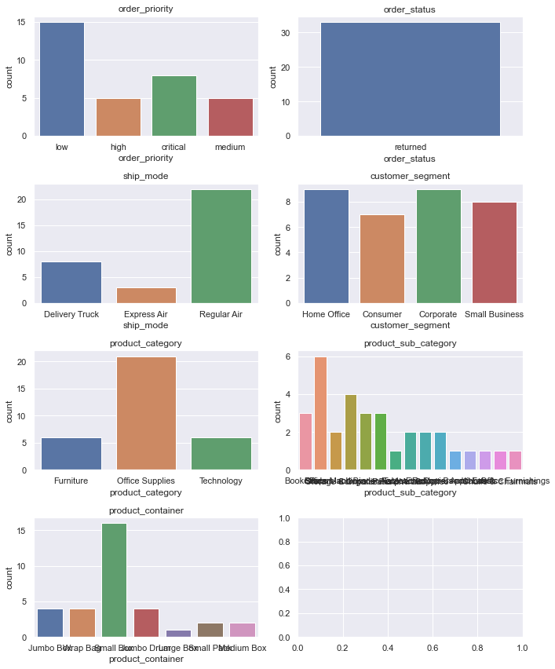

```python
figure, ax_list_list = plt.subplots(nrows=4, ncols=2);
figure.set_size_inches(10,12)

ax_list = ax_list_list.reshape(8)
print(ax_list_list.shape)
print(ax_list.shape)

for i in range(len(category_cols)):
    col = category_cols[i]
    sns.countplot(data=q3_returned, x=col, ax=ax_list[i])
    ax_list[i].set_title(col)

plt.tight_layout();
```

```
(4, 2)
(8,)
```

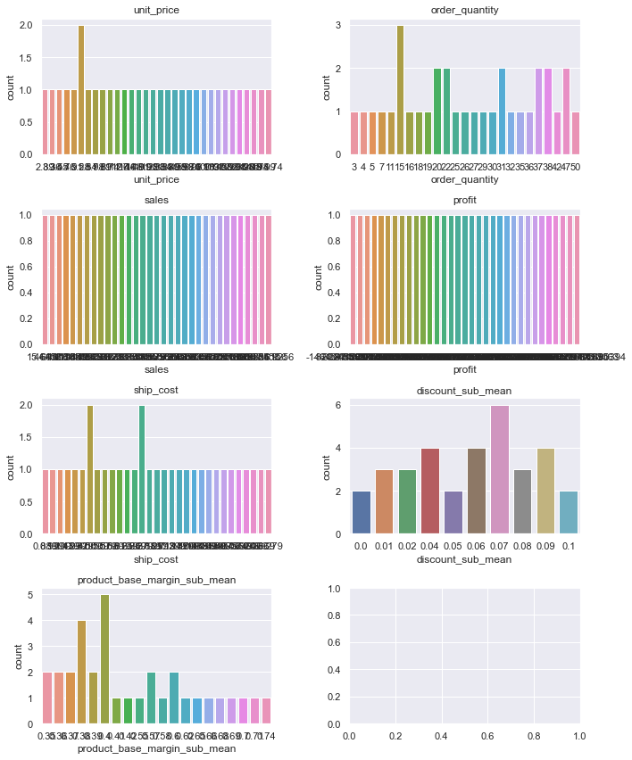

```python
figure, ax_list_list = plt.subplots(nrows=4, ncols=2);
figure.set_size_inches(10,12)

ax_list = ax_list_list.reshape(8)
print(ax_list_list.shape)
print(ax_list.shape)

for i in range(len(numerical_cols)):
    col = numerical_cols[i]
    sns.countplot(data=q3_returned, x=col, ax=ax_list[i])
    ax_list[i].set_title(col)

plt.tight_layout();
```

```
(3, 2)
(6,)
```

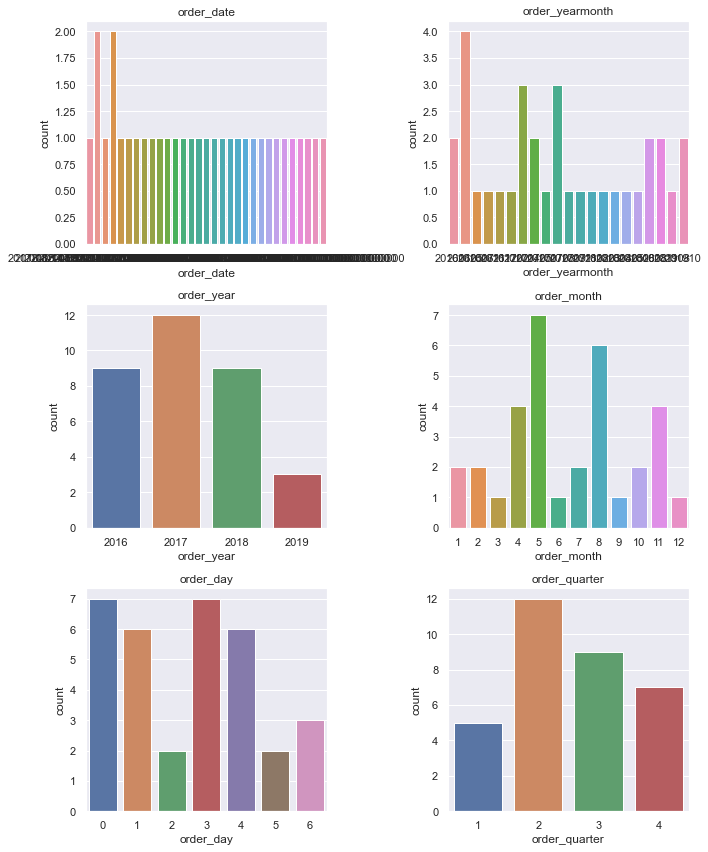

```python
figure, ax_list_list = plt.subplots(nrows=3, ncols=2);
figure.set_size_inches(10,12)

ax_list = ax_list_list.reshape(6)
print(ax_list_list.shape)
print(ax_list.shape)

for i in range(len(datetime_cols)):
    col = datetime_cols[i]
    sns.countplot(data=q3_returned, x=col, ax=ax_list[i])
    ax_list[i].set_title(col)

plt.tight_layout();
```

A1에서 목요일에 고객들의 주문수량이 이익과 매출의 감소로 이어지는 것을 확인  
월요일에 고객들이 구매하는 물품은 단가가 높지만 구매 수량이 현저히 낮은 것을 확인  
오히려 수익성이 낮은 물품 중 반품된 건은 월요일과 목요일에 많음

5월에 현저히 반품량이 많음

```python
q3_returned.query("order_day == 0").product_category
```

```
21           Furniture
135          Furniture
252          Furniture
366    Office Supplies
372    Office Supplies
386    Office Supplies
452          Furniture
Name: product_category, dtype: object
```

```python
q3_returned.query("order_day == 3").loc[:,("record_id","product_category")]
```

|  | record_id | product_category |
| --- | --- | --- |
| 46 | 5546 | Office Supplies |
| 52 | 5552 | Technology |
| 68 | 5568 | Furniture |
| 100 | 5600 | Office Supplies |
| 231 | 5731 | Office Supplies |
| 263 | 5763 | Technology |
| 282 | 5782 | Office Supplies |

```python
returned_thurs_fix = pd.read_excel("C:/Users/jinje/1학기_전자산업데이터분석/profit_m.xlsx")
```

```python
returned_thurs_fix
```

|  | record_id | profit | city | order_id | order_date | order_priority | unit_price | order_quantity | sales | order_status | ... | order_year | order_month | order_day | order_quarter | ship_yearmonth | ship_year | ship_month | ship_day | ship_quarter | lead_time |
| --- | --- | --- | --- | --- | --- | --- | --- | --- | --- | --- | --- | --- | --- | --- | --- | --- | --- | --- | --- | --- | --- |
| 0 | 5500 | -38.840942 | Nashville | 39501 | 2019-05-02 | low | 3.36 | 20 | 71.4556 | completed | ... | 2019 | 5 | 3 | 2 | 197001 | 1970 | 1 | 3 | 1 | -18018 |
| 1 | 5501 | -67.630812 | Burlington | 40624 | 2017-08-26 | low | 33.98 | 20 | 677.9056 | completed | ... | 2017 | 8 | 5 | 3 | 197001 | 1970 | 1 | 3 | 1 | -17404 |
| 2 | 5502 | -103.370548 | Buffalo | 4925 | 2017-05-23 | critical | 6.68 | 3 | 26.5356 | completed | ... | 2017 | 5 | 1 | 2 | 197001 | 1970 | 1 | 3 | 1 | -17309 |
| 3 | 5503 | -14.125755 | Denton | 18988 | 2016-01-09 | critical | 3.28 | 19 | 63.1456 | completed | ... | 2016 | 1 | 5 | 1 | 197001 | 1970 | 1 | 3 | 1 | -16809 |
| 4 | 5505 | -62.410229 | Weatherford | 26935 | 2016-08-09 | high | 4.98 | 5 | 25.1056 | completed | ... | 2016 | 8 | 1 | 3 | 197001 | 1970 | 1 | 3 | 1 | -17022 |
| ... | ... | ... | ... | ... | ... | ... | ... | ... | ... | ... | ... | ... | ... | ... | ... | ... | ... | ... | ... | ... | ... |
| 233 | 5952 | -49.702274 | Brownsville | 28385 | 2018-02-05 | low | 90.98 | 37 | 3351.5556 | returned | ... | 2018 | 2 | 0 | 1 | 197001 | 1970 | 1 | 3 | 1 | -17567 |
| 234 | 5953 | -22.507214 | Johnson City | 32053 | 2018-04-13 | critical | 15.67 | 46 | 662.5156 | completed | ... | 2018 | 4 | 4 | 2 | 197001 | 1970 | 1 | 3 | 1 | -17634 |
| 235 | 5954 | -22.466398 | Alamogordo | 8216 | 2016-05-01 | medium | 8.09 | 27 | 216.9556 | completed | ... | 2016 | 5 | 6 | 2 | 197001 | 1970 | 1 | 3 | 1 | -16922 |
| 236 | 5958 | -554.900906 | Fridley | 46942 | 2017-09-15 | low | 64.65 | 15 | 926.3056 | completed | ... | 2017 | 9 | 4 | 3 | 197001 | 1970 | 1 | 3 | 1 | -17424 |
| 237 | 5959 | -24.090141 | Kansas City | 21112 | 2017-02-25 | low | 111.03 | 40 | 4538.6656 | completed | ... | 2017 | 2 | 5 | 1 | 197001 | 1970 | 1 | 3 | 1 | -17222 |

238 rows × 37 columns

이 데이터에서 profit 행을 지우고 다시 위의 모델에 적합시켜 profit을 예측하여 개선되었는지 확인해보도록 하겠습니다

```python
returned_thurs_fix.iloc[:,2:]
```

|  | city | order_id | order_date | order_priority | unit_price | order_quantity | sales | order_status | ship_mode | ship_cost | ... | order_year | order_month | order_day | order_quarter | ship_yearmonth | ship_year | ship_month | ship_day | ship_quarter | lead_time |
| --- | --- | --- | --- | --- | --- | --- | --- | --- | --- | --- | --- | --- | --- | --- | --- | --- | --- | --- | --- | --- | --- |
| 0 | Nashville | 39501 | 2019-05-02 | low | 3.36 | 20 | 71.4556 | completed | Regular Air | 6.279 | ... | 2019 | 5 | 3 | 2 | 197001 | 1970 | 1 | 3 | 1 | -18018 |
| 1 | Burlington | 40624 | 2017-08-26 | low | 33.98 | 20 | 677.9056 | completed | Regular Air | 1.999 | ... | 2017 | 8 | 5 | 3 | 197001 | 1970 | 1 | 3 | 1 | -17404 |
| 2 | Buffalo | 4925 | 2017-05-23 | critical | 6.68 | 3 | 26.5356 | completed | Regular Air | 6.929 | ... | 2017 | 5 | 1 | 2 | 197001 | 1970 | 1 | 3 | 1 | -17309 |
| 3 | Denton | 18988 | 2016-01-09 | critical | 3.28 | 19 | 63.1456 | completed | Regular Air | 3.979 | ... | 2016 | 1 | 5 | 1 | 197001 | 1970 | 1 | 3 | 1 | -16809 |
| 4 | Weatherford | 26935 | 2016-08-09 | high | 4.98 | 5 | 25.1056 | completed | Regular Air | 0.499 | ... | 2016 | 8 | 1 | 3 | 197001 | 1970 | 1 | 3 | 1 | -17022 |
| ... | ... | ... | ... | ... | ... | ... | ... | ... | ... | ... | ... | ... | ... | ... | ... | ... | ... | ... | ... | ... | ... |
| 233 | Brownsville | 28385 | 2018-02-05 | low | 90.98 | 37 | 3351.5556 | returned | Express Air | 56.209 | ... | 2018 | 2 | 0 | 1 | 197001 | 1970 | 1 | 3 | 1 | -17567 |
| 234 | Johnson City | 32053 | 2018-04-13 | critical | 15.67 | 46 | 662.5156 | completed | Regular Air | 1.399 | ... | 2018 | 4 | 4 | 2 | 197001 | 1970 | 1 | 3 | 1 | -17634 |
| 235 | Alamogordo | 8216 | 2016-05-01 | medium | 8.09 | 27 | 216.9556 | completed | Regular Air | 7.969 | ... | 2016 | 5 | 6 | 2 | 197001 | 1970 | 1 | 3 | 1 | -16922 |
| 236 | Fridley | 46942 | 2017-09-15 | low | 64.65 | 15 | 926.3056 | completed | Regular Air | 35.009 | ... | 2017 | 9 | 4 | 3 | 197001 | 1970 | 1 | 3 | 1 | -17424 |
| 237 | Kansas City | 21112 | 2017-02-25 | low | 111.03 | 40 | 4538.6656 | completed | Regular Air | 8.649 | ... | 2017 | 2 | 5 | 1 | 197001 | 1970 | 1 | 3 | 1 | -17222 |

238 rows × 35 columns

```python
train_data
```

|  | unit_price | order_quantity | sales | ship_cost | discount_sub_mean | product_base_margin_sub_mean | order_month | order_day | order_priority | order_status | ship_mode | customer_segment | product_category | product_sub_category | product_container | state_name | region |
| --- | --- | --- | --- | --- | --- | --- | --- | --- | --- | --- | --- | --- | --- | --- | --- | --- | --- |
| 3098 | 150.98 | 30 | 4278.6156 | 66.279 | 0.070000 | 0.65 | 4 | 4 | high | returned | Delivery Truck | Small Business | Furniture | Bookcases | Jumbo Box | Florida | South |
| 362 | 130.98 | 30 | 4011.6556 | 54.749 | 0.050000 | 0.69 | 6 | 3 | medium | completed | Delivery Truck | Consumer | Furniture | Bookcases | Jumbo Box | Idaho | West |
| 1398 | 1.88 | 19 | 36.7556 | 1.499 | 0.060000 | 0.37 | 11 | 1 | critical | completed | Regular Air | Corporate | Office Supplies | Binders and Binder Accessories | Small Box | Michigan | Central |
| 106 | 67.28 | 29 | 2046.8156 | 19.999 | 0.020000 | 0.40 | 9 | 5 | medium | completed | Regular Air | Small Business | Office Supplies | Binders and Binder Accessories | Small Box | Indiana | Central |
| 6283 | 12.97 | 27 | 353.6256 | 1.499 | 0.010000 | 0.35 | 2 | 2 | medium | completed | Regular Air | Consumer | Office Supplies | Binders and Binder Accessories | Small Box | Arkansas | South |
| ... | ... | ... | ... | ... | ... | ... | ... | ... | ... | ... | ... | ... | ... | ... | ... | ... | ... |
| 1032 | 2.88 | 30 | 80.9056 | 0.709 | 0.051156 | 0.56 | 8 | 5 | high | completed | Regular Air | Home Office | Office Supplies | Pens & Art Supplies | Wrap Bag | Illinois | Central |
| 2121 | 4.89 | 31 | 162.5856 | 4.939 | 0.000000 | 0.66 | 1 | 1 | high | completed | Regular Air | Small Business | Technology | Computer Peripherals | Small Pack | Tennessee | South |
| 7286 | 7.38 | 4 | 36.8056 | 5.219 | 0.048495 | 0.56 | 3 | 5 | medium | completed | Regular Air | Home Office | Furniture | Office Furnishings | Small Box | South Dakota | Central |
| 1725 | 17.98 | 9 | 181.6656 | 8.519 | 0.000000 | 0.40 | 11 | 5 | high | completed | Regular Air | Small Business | Technology | Office Machines | Medium Box | Michigan | Central |
| 2254 | 4.13 | 33 | 139.9856 | 6.899 | 0.050161 | 0.39 | 1 | 2 | low | completed | Regular Air | Small Business | Office Supplies | Labels | Small Box | New York | East |

5436 rows × 17 columns

```python
test_data = returned_thurs_fix
```

```python
test_data
```

|  | record_id | profit | city | order_id | order_date | order_priority | unit_price | order_quantity | sales | order_status | ... | order_year | order_month | order_day | order_quarter | ship_yearmonth | ship_year | ship_month | ship_day | ship_quarter | lead_time |
| --- | --- | --- | --- | --- | --- | --- | --- | --- | --- | --- | --- | --- | --- | --- | --- | --- | --- | --- | --- | --- | --- |
| 0 | 5500 | -38.840942 | Nashville | 39501 | 2019-05-02 | low | 3.36 | 20 | 71.4556 | completed | ... | 2019 | 5 | 3 | 2 | 197001 | 1970 | 1 | 3 | 1 | -18018 |
| 1 | 5501 | -67.630812 | Burlington | 40624 | 2017-08-26 | low | 33.98 | 20 | 677.9056 | completed | ... | 2017 | 8 | 5 | 3 | 197001 | 1970 | 1 | 3 | 1 | -17404 |
| 2 | 5502 | -103.370548 | Buffalo | 4925 | 2017-05-23 | critical | 6.68 | 3 | 26.5356 | completed | ... | 2017 | 5 | 1 | 2 | 197001 | 1970 | 1 | 3 | 1 | -17309 |
| 3 | 5503 | -14.125755 | Denton | 18988 | 2016-01-09 | critical | 3.28 | 19 | 63.1456 | completed | ... | 2016 | 1 | 5 | 1 | 197001 | 1970 | 1 | 3 | 1 | -16809 |
| 4 | 5505 | -62.410229 | Weatherford | 26935 | 2016-08-09 | high | 4.98 | 5 | 25.1056 | completed | ... | 2016 | 8 | 1 | 3 | 197001 | 1970 | 1 | 3 | 1 | -17022 |
| ... | ... | ... | ... | ... | ... | ... | ... | ... | ... | ... | ... | ... | ... | ... | ... | ... | ... | ... | ... | ... | ... |
| 233 | 5952 | -49.702274 | Brownsville | 28385 | 2018-02-05 | low | 90.98 | 37 | 3351.5556 | returned | ... | 2018 | 2 | 0 | 1 | 197001 | 1970 | 1 | 3 | 1 | -17567 |
| 234 | 5953 | -22.507214 | Johnson City | 32053 | 2018-04-13 | critical | 15.67 | 46 | 662.5156 | completed | ... | 2018 | 4 | 4 | 2 | 197001 | 1970 | 1 | 3 | 1 | -17634 |
| 235 | 5954 | -22.466398 | Alamogordo | 8216 | 2016-05-01 | medium | 8.09 | 27 | 216.9556 | completed | ... | 2016 | 5 | 6 | 2 | 197001 | 1970 | 1 | 3 | 1 | -16922 |
| 236 | 5958 | -554.900906 | Fridley | 46942 | 2017-09-15 | low | 64.65 | 15 | 926.3056 | completed | ... | 2017 | 9 | 4 | 3 | 197001 | 1970 | 1 | 3 | 1 | -17424 |
| 237 | 5959 | -24.090141 | Kansas City | 21112 | 2017-02-25 | low | 111.03 | 40 | 4538.6656 | completed | ... | 2017 | 2 | 5 | 1 | 197001 | 1970 | 1 | 3 | 1 | -17222 |

238 rows × 37 columns

```python
test_data_remove = test_data.loc[:,("unit_price","order_quantity","sales","ship_cost","discount_sub_mean","product_base_margin_sub_mean","order_month","order_day","order_priority","order_status","ship_mode","customer_segment","product_category","product_sub_category","product_container","state_name","region")]
```

```python
test_data_remove
```

|  | unit_price | order_quantity | sales | ship_cost | discount_sub_mean | product_base_margin_sub_mean | order_month | order_day | order_priority | order_status | ship_mode | customer_segment | product_category | product_sub_category | product_container | state_name | region |
| --- | --- | --- | --- | --- | --- | --- | --- | --- | --- | --- | --- | --- | --- | --- | --- | --- | --- |
| 0 | 3.36 | 20 | 71.4556 | 6.279 | 0.03 | 0.40 | 5 | 3 | low | completed | Regular Air | Corporate | Office Supplies | Binders and Binder Accessories | Small Box | Tennessee | South |
| 1 | 33.98 | 20 | 677.9056 | 1.999 | 0.05 | 0.45 | 8 | 5 | low | completed | Regular Air | Corporate | Technology | Computer Peripherals | Small Pack | Vermont | East |
| 2 | 6.68 | 3 | 26.5356 | 6.929 | 0.05 | 0.37 | 5 | 1 | critical | completed | Regular Air | Home Office | Office Supplies | Paper | Small Box | New York | East |
| 3 | 3.28 | 19 | 63.1456 | 3.979 | 0.06 | 0.56 | 1 | 5 | critical | completed | Regular Air | Corporate | Office Supplies | Pens & Art Supplies | Wrap Bag | Texas | Central |
| 4 | 4.98 | 5 | 25.1056 | 0.499 | 0.04 | 0.39 | 8 | 1 | high | completed | Regular Air | Consumer | Office Supplies | Labels | Small Box | Texas | Central |
| ... | ... | ... | ... | ... | ... | ... | ... | ... | ... | ... | ... | ... | ... | ... | ... | ... | ... |
| 233 | 90.98 | 37 | 3351.5556 | 56.209 | 0.04 | 0.74 | 2 | 0 | low | returned | Express Air | Home Office | Furniture | Office Furnishings | Medium Box | Texas | Central |
| 234 | 15.67 | 46 | 662.5156 | 1.399 | 0.09 | 0.38 | 4 | 4 | critical | completed | Regular Air | Small Business | Office Supplies | Envelopes | Small Box | Tennessee | South |
| 235 | 8.09 | 27 | 216.9556 | 7.969 | 0.08 | 0.49 | 5 | 6 | medium | completed | Regular Air | Consumer | Furniture | Office Furnishings | Small Box | New Mexico | West |
| 236 | 64.65 | 15 | 926.3056 | 35.009 | 0.09 | 0.80 | 9 | 4 | low | completed | Regular Air | Home Office | Office Supplies | Storage & Organization | Large Box | Minnesota | Central |
| 237 | 111.03 | 40 | 4538.6656 | 8.649 | 0.00 | 0.78 | 2 | 5 | low | completed | Regular Air | Corporate | Office Supplies | Storage & Organization | Small Box | MO | Central |

238 rows × 17 columns

```python
print(train_data.shape)
print(test_data_remove.shape)
print(train_y.shape)
```

```
(5436, 17)
(238, 17)
(5436,)
```

```python
full_train_test_A3 = pd.concat([train_data, test_data_remove])
```

```python
full_train_test_A3
```

|  | unit_price | order_quantity | sales | ship_cost | discount_sub_mean | product_base_margin_sub_mean | order_month | order_day | order_priority | order_status | ship_mode | customer_segment | product_category | product_sub_category | product_container | state_name | region |
| --- | --- | --- | --- | --- | --- | --- | --- | --- | --- | --- | --- | --- | --- | --- | --- | --- | --- |
| 3098 | 150.98 | 30 | 4278.6156 | 66.279 | 0.07 | 0.65 | 4 | 4 | high | returned | Delivery Truck | Small Business | Furniture | Bookcases | Jumbo Box | Florida | South |
| 362 | 130.98 | 30 | 4011.6556 | 54.749 | 0.05 | 0.69 | 6 | 3 | medium | completed | Delivery Truck | Consumer | Furniture | Bookcases | Jumbo Box | Idaho | West |
| 1398 | 1.88 | 19 | 36.7556 | 1.499 | 0.06 | 0.37 | 11 | 1 | critical | completed | Regular Air | Corporate | Office Supplies | Binders and Binder Accessories | Small Box | Michigan | Central |
| 106 | 67.28 | 29 | 2046.8156 | 19.999 | 0.02 | 0.40 | 9 | 5 | medium | completed | Regular Air | Small Business | Office Supplies | Binders and Binder Accessories | Small Box | Indiana | Central |
| 6283 | 12.97 | 27 | 353.6256 | 1.499 | 0.01 | 0.35 | 2 | 2 | medium | completed | Regular Air | Consumer | Office Supplies | Binders and Binder Accessories | Small Box | Arkansas | South |
| ... | ... | ... | ... | ... | ... | ... | ... | ... | ... | ... | ... | ... | ... | ... | ... | ... | ... |
| 233 | 90.98 | 37 | 3351.5556 | 56.209 | 0.04 | 0.74 | 2 | 0 | low | returned | Express Air | Home Office | Furniture | Office Furnishings | Medium Box | Texas | Central |
| 234 | 15.67 | 46 | 662.5156 | 1.399 | 0.09 | 0.38 | 4 | 4 | critical | completed | Regular Air | Small Business | Office Supplies | Envelopes | Small Box | Tennessee | South |
| 235 | 8.09 | 27 | 216.9556 | 7.969 | 0.08 | 0.49 | 5 | 6 | medium | completed | Regular Air | Consumer | Furniture | Office Furnishings | Small Box | New Mexico | West |
| 236 | 64.65 | 15 | 926.3056 | 35.009 | 0.09 | 0.80 | 9 | 4 | low | completed | Regular Air | Home Office | Office Supplies | Storage & Organization | Large Box | Minnesota | Central |
| 237 | 111.03 | 40 | 4538.6656 | 8.649 | 0.00 | 0.78 | 2 | 5 | low | completed | Regular Air | Corporate | Office Supplies | Storage & Organization | Small Box | MO | Central |

5674 rows × 17 columns

```python
from sklearn.preprocessing import scale
full_train_test_A3["unit_price"] = scale(full_train_test_A3["unit_price"])
```

```python
full_train_test_A3["order_quantity"] = scale(full_train_test_A3["order_quantity"])
```

```python
full_train_test_A3["sales"] = scale(full_train_test_A3["sales"])
```

```python
full_train_test_A3["ship_cost"] = scale(full_train_test_A3["ship_cost"])
```

```python
full_train_test_A3["discount_sub_mean"] = scale(full_train_test_A3["discount_sub_mean"])
```

```python
full_train_test_A3["product_base_margin_sub_mean"] = scale(full_train_test_A3["product_base_margin_sub_mean"])
```

```python
full_train_test_A3["order_month"] = scale(full_train_test_A3["order_month"])
```

```python
full_train_test_A3["order_day"] = scale(full_train_test_A3["order_day"])
```

```python
full_train_test_A3
```

|  | unit_price | order_quantity | sales | ship_cost | discount_sub_mean | product_base_margin_sub_mean | order_month | order_day | order_priority | order_status | ship_mode | customer_segment | product_category | product_sub_category | product_container | state_name | region |
| --- | --- | --- | --- | --- | --- | --- | --- | --- | --- | --- | --- | --- | --- | --- | --- | --- | --- |
| 3098 | 0.323874 | 0.313592 | 0.909680 | 3.113687 | 0.680881 | 0.984811 | -0.734681 | 0.471973 | high | returned | Delivery Truck | Small Business | Furniture | Bookcases | Jumbo Box | Florida | South |
| 362 | 0.233666 | 0.313592 | 0.818875 | 2.442960 | 0.008343 | 1.280304 | -0.153451 | -0.029708 | medium | completed | Delivery Truck | Consumer | Furniture | Bookcases | Jumbo Box | Idaho | West |
| 1398 | -0.348623 | -0.449380 | -0.533159 | -0.654715 | 0.344612 | -1.083645 | 1.299624 | -1.033072 | critical | completed | Regular Air | Corporate | Office Supplies | Binders and Binder Accessories | Small Box | Michigan | Central |
| 106 | -0.053645 | 0.244231 | 0.150549 | 0.421473 | -1.000465 | -0.862025 | 0.718394 | 0.973655 | medium | completed | Regular Air | Small Business | Office Supplies | Binders and Binder Accessories | Small Box | Indiana | Central |
| 6283 | -0.298603 | 0.105509 | -0.425377 | -0.654715 | -1.336734 | -1.231392 | -1.315911 | -0.531390 | medium | completed | Regular Air | Consumer | Office Supplies | Binders and Binder Accessories | Small Box | Arkansas | South |
| ... | ... | ... | ... | ... | ... | ... | ... | ... | ... | ... | ... | ... | ... | ... | ... | ... | ... |
| 233 | 0.053251 | 0.799120 | 0.594347 | 2.527892 | -0.327926 | 1.649671 | -1.315911 | -1.534753 | low | returned | Express Air | Home Office | Furniture | Office Furnishings | Medium Box | Texas | Central |
| 234 | -0.286425 | 1.423369 | -0.320311 | -0.660532 | 1.353419 | -1.009772 | -0.734681 | 0.471973 | critical | completed | Regular Air | Small Business | Office Supplies | Envelopes | Small Box | Tennessee | South |
| 235 | -0.320614 | 0.105509 | -0.471865 | -0.278340 | 1.017150 | -0.197164 | -0.444066 | 1.475337 | medium | completed | Regular Air | Consumer | Furniture | Office Furnishings | Small Box | New Mexico | West |
| 236 | -0.065507 | -0.726825 | -0.230585 | 1.294639 | 1.353419 | 2.092912 | 0.718394 | 0.471973 | low | completed | Regular Air | Home Office | Office Supplies | Storage & Organization | Large Box | Minnesota | Central |
| 237 | 0.143684 | 1.007203 | 0.998134 | -0.238783 | -1.673003 | 1.945165 | -1.315911 | 0.973655 | low | completed | Regular Air | Corporate | Office Supplies | Storage & Organization | Small Box | MO | Central |

5674 rows × 17 columns

```python
features_df_A3 = pd.get_dummies(full_train_test_A3, columns=['order_priority' , 'order_status' , "ship_mode" ,"customer_segment" ,'product_category' ,"product_sub_category" ,"product_container","state_name","region"])
```

```python
features_df_A3
```

|  | unit_price | order_quantity | sales | ship_cost | discount_sub_mean | product_base_margin_sub_mean | order_month | order_day | order_priority_critical | order_priority_high | ... | state_name_Vermont | state_name_Virginia | state_name_Washington | state_name_West Virginia | state_name_Wisconsin | state_name_Wyoming | region_Central | region_East | region_South | region_West |
| --- | --- | --- | --- | --- | --- | --- | --- | --- | --- | --- | --- | --- | --- | --- | --- | --- | --- | --- | --- | --- | --- |
| 3098 | 0.323874 | 0.313592 | 0.909680 | 3.113687 | 0.680881 | 0.984811 | -0.734681 | 0.471973 | 0 | 1 | ... | 0 | 0 | 0 | 0 | 0 | 0 | 0 | 0 | 1 | 0 |
| 362 | 0.233666 | 0.313592 | 0.818875 | 2.442960 | 0.008343 | 1.280304 | -0.153451 | -0.029708 | 0 | 0 | ... | 0 | 0 | 0 | 0 | 0 | 0 | 0 | 0 | 0 | 1 |
| 1398 | -0.348623 | -0.449380 | -0.533159 | -0.654715 | 0.344612 | -1.083645 | 1.299624 | -1.033072 | 1 | 0 | ... | 0 | 0 | 0 | 0 | 0 | 0 | 1 | 0 | 0 | 0 |
| 106 | -0.053645 | 0.244231 | 0.150549 | 0.421473 | -1.000465 | -0.862025 | 0.718394 | 0.973655 | 0 | 0 | ... | 0 | 0 | 0 | 0 | 0 | 0 | 1 | 0 | 0 | 0 |
| 6283 | -0.298603 | 0.105509 | -0.425377 | -0.654715 | -1.336734 | -1.231392 | -1.315911 | -0.531390 | 0 | 0 | ... | 0 | 0 | 0 | 0 | 0 | 0 | 0 | 0 | 1 | 0 |
| ... | ... | ... | ... | ... | ... | ... | ... | ... | ... | ... | ... | ... | ... | ... | ... | ... | ... | ... | ... | ... | ... |
| 233 | 0.053251 | 0.799120 | 0.594347 | 2.527892 | -0.327926 | 1.649671 | -1.315911 | -1.534753 | 0 | 0 | ... | 0 | 0 | 0 | 0 | 0 | 0 | 1 | 0 | 0 | 0 |
| 234 | -0.286425 | 1.423369 | -0.320311 | -0.660532 | 1.353419 | -1.009772 | -0.734681 | 0.471973 | 1 | 0 | ... | 0 | 0 | 0 | 0 | 0 | 0 | 0 | 0 | 1 | 0 |
| 235 | -0.320614 | 0.105509 | -0.471865 | -0.278340 | 1.017150 | -0.197164 | -0.444066 | 1.475337 | 0 | 0 | ... | 0 | 0 | 0 | 0 | 0 | 0 | 0 | 0 | 0 | 1 |
| 236 | -0.065507 | -0.726825 | -0.230585 | 1.294639 | 1.353419 | 2.092912 | 0.718394 | 0.471973 | 0 | 0 | ... | 0 | 0 | 0 | 0 | 0 | 0 | 1 | 0 | 0 | 0 |
| 237 | 0.143684 | 1.007203 | 0.998134 | -0.238783 | -1.673003 | 1.945165 | -1.315911 | 0.973655 | 0 | 0 | ... | 0 | 0 | 0 | 0 | 0 | 0 | 1 | 0 | 0 | 0 |

5674 rows × 100 columns

```python
train_data_A3 = features_df_A3.iloc[:5436,:]
train_data_A3
```

|  | unit_price | order_quantity | sales | ship_cost | discount_sub_mean | product_base_margin_sub_mean | order_month | order_day | order_priority_critical | order_priority_high | ... | state_name_Vermont | state_name_Virginia | state_name_Washington | state_name_West Virginia | state_name_Wisconsin | state_name_Wyoming | region_Central | region_East | region_South | region_West |
| --- | --- | --- | --- | --- | --- | --- | --- | --- | --- | --- | --- | --- | --- | --- | --- | --- | --- | --- | --- | --- | --- |
| 3098 | 0.323874 | 0.313592 | 0.909680 | 3.113687 | 0.680881 | 0.984811 | -0.734681 | 0.471973 | 0 | 1 | ... | 0 | 0 | 0 | 0 | 0 | 0 | 0 | 0 | 1 | 0 |
| 362 | 0.233666 | 0.313592 | 0.818875 | 2.442960 | 0.008343 | 1.280304 | -0.153451 | -0.029708 | 0 | 0 | ... | 0 | 0 | 0 | 0 | 0 | 0 | 0 | 0 | 0 | 1 |
| 1398 | -0.348623 | -0.449380 | -0.533159 | -0.654715 | 0.344612 | -1.083645 | 1.299624 | -1.033072 | 1 | 0 | ... | 0 | 0 | 0 | 0 | 0 | 0 | 1 | 0 | 0 | 0 |
| 106 | -0.053645 | 0.244231 | 0.150549 | 0.421473 | -1.000465 | -0.862025 | 0.718394 | 0.973655 | 0 | 0 | ... | 0 | 0 | 0 | 0 | 0 | 0 | 1 | 0 | 0 | 0 |
| 6283 | -0.298603 | 0.105509 | -0.425377 | -0.654715 | -1.336734 | -1.231392 | -1.315911 | -0.531390 | 0 | 0 | ... | 0 | 0 | 0 | 0 | 0 | 0 | 0 | 0 | 1 | 0 |
| ... | ... | ... | ... | ... | ... | ... | ... | ... | ... | ... | ... | ... | ... | ... | ... | ... | ... | ... | ... | ... | ... |
| 1032 | -0.344113 | 0.313592 | -0.518141 | -0.700671 | 0.047208 | 0.319950 | 0.427779 | 0.973655 | 0 | 1 | ... | 0 | 0 | 0 | 0 | 0 | 0 | 1 | 0 | 0 | 0 |
| 2121 | -0.335047 | 0.382953 | -0.490358 | -0.454602 | -1.673003 | 1.058684 | -1.606526 | -1.033072 | 0 | 1 | ... | 0 | 0 | 0 | 0 | 0 | 0 | 0 | 0 | 1 | 0 |
| 7286 | -0.323816 | -1.489797 | -0.533142 | -0.438314 | -0.042271 | 0.319950 | -1.025296 | 0.973655 | 0 | 0 | ... | 0 | 0 | 0 | 0 | 0 | 0 | 1 | 0 | 0 | 0 |
| 1725 | -0.276006 | -1.142991 | -0.483868 | -0.246345 | -1.673003 | -0.862025 | 1.299624 | 0.973655 | 0 | 1 | ... | 0 | 0 | 0 | 0 | 0 | 0 | 1 | 0 | 0 | 0 |
| 2254 | -0.338475 | 0.521675 | -0.498046 | -0.340584 | 0.013766 | -0.935898 | -1.606526 | -0.531390 | 0 | 0 | ... | 0 | 0 | 0 | 0 | 0 | 0 | 0 | 1 | 0 | 0 |

5436 rows × 100 columns

```python
test_data_A3 = features_df_A3.iloc[5436:,:]
test_data_A3
```

|  | unit_price | order_quantity | sales | ship_cost | discount_sub_mean | product_base_margin_sub_mean | order_month | order_day | order_priority_critical | order_priority_high | ... | state_name_Vermont | state_name_Virginia | state_name_Washington | state_name_West Virginia | state_name_Wisconsin | state_name_Wyoming | region_Central | region_East | region_South | region_West |
| --- | --- | --- | --- | --- | --- | --- | --- | --- | --- | --- | --- | --- | --- | --- | --- | --- | --- | --- | --- | --- | --- |
| 0 | -0.341948 | -0.380019 | -0.521356 | -0.376651 | -0.664196 | -0.862025 | -0.444066 | -0.029708 | 0 | 0 | ... | 0 | 0 | 0 | 0 | 0 | 0 | 0 | 0 | 1 | 0 |
| 1 | -0.203840 | -0.380019 | -0.315076 | -0.625628 | 0.008343 | -0.492658 | 0.427779 | 0.973655 | 0 | 0 | ... | 1 | 0 | 0 | 0 | 0 | 0 | 0 | 1 | 0 | 0 |
| 2 | -0.326973 | -1.559158 | -0.536635 | -0.338839 | 0.008343 | -1.083645 | -0.444066 | -1.033072 | 1 | 0 | ... | 0 | 0 | 0 | 0 | 0 | 0 | 0 | 1 | 0 | 0 |
| 3 | -0.342309 | -0.449380 | -0.524182 | -0.510447 | 0.344612 | 0.319950 | -1.606526 | 0.973655 | 1 | 0 | ... | 0 | 0 | 0 | 0 | 0 | 0 | 1 | 0 | 0 | 0 |
| 4 | -0.334641 | -1.420436 | -0.537121 | -0.712887 | -0.327926 | -0.935898 | 0.427779 | -1.033072 | 0 | 1 | ... | 0 | 0 | 0 | 0 | 0 | 0 | 1 | 0 | 0 | 0 |
| ... | ... | ... | ... | ... | ... | ... | ... | ... | ... | ... | ... | ... | ... | ... | ... | ... | ... | ... | ... | ... | ... |
| 233 | 0.053251 | 0.799120 | 0.594347 | 2.527892 | -0.327926 | 1.649671 | -1.315911 | -1.534753 | 0 | 0 | ... | 0 | 0 | 0 | 0 | 0 | 0 | 1 | 0 | 0 | 0 |
| 234 | -0.286425 | 1.423369 | -0.320311 | -0.660532 | 1.353419 | -1.009772 | -0.734681 | 0.471973 | 1 | 0 | ... | 0 | 0 | 0 | 0 | 0 | 0 | 0 | 0 | 1 | 0 |
| 235 | -0.320614 | 0.105509 | -0.471865 | -0.278340 | 1.017150 | -0.197164 | -0.444066 | 1.475337 | 0 | 0 | ... | 0 | 0 | 0 | 0 | 0 | 0 | 0 | 0 | 0 | 1 |
| 236 | -0.065507 | -0.726825 | -0.230585 | 1.294639 | 1.353419 | 2.092912 | 0.718394 | 0.471973 | 0 | 0 | ... | 0 | 0 | 0 | 0 | 0 | 0 | 1 | 0 | 0 | 0 |
| 237 | 0.143684 | 1.007203 | 0.998134 | -0.238783 | -1.673003 | 1.945165 | -1.315911 | 0.973655 | 0 | 0 | ... | 0 | 0 | 0 | 0 | 0 | 0 | 1 | 0 | 0 | 0 |

238 rows × 100 columns

### 다시 예측하기

```python
pred_y_A3 = xgb.predict(test_data_A3)
```

```python
import collections, numpy
collections.Counter(pred_y_A3)
```

```
Counter({-75.334785: 1,
         199.4786: 1,
         -31.688505: 1,
         -35.185635: 1,
         6.9668226: 1,
         -74.279434: 1,
         175.67421: 1,
         -905.75006: 1,
         1840.7805: 1,
         17.68371: 1,
         -1.5810841: 1,
         505.79205: 1,
         -222.21915: 1,
         -0.70805097: 1,
         -111.909874: 1,
         131.83107: 1,
         270.66278: 1,
         -82.39854: 1,
         7.521124: 1,
         342.1579: 1,
         49.971897: 1,
         30.612303: 1,
         28.072361: 1,
         -10.12654: 1,
         884.6463: 1,
         228.58719: 1,
         -117.74318: 1,
         -7.7062736: 1,
         40.978447: 1,
         328.0195: 1,
         -91.516556: 1,
         -746.8735: 1,
         -10.02801: 1,
         24.138285: 1,
         -125.46413: 1,
         622.0763: 1,
         41.99326: 1,
         -29.416212: 1,
         418.20886: 1,
         -427.6105: 1,
```

[output cut: 183 more lines]

```
         -1184.0691: 1,
         0.452838: 1,
         -277.34457: 1,
         -171.56027: 1,
         339.30594: 1,
         80.63371: 1,
         8.073135: 1,
         188.17546: 1,
         338.29337: 1,
         -21.931656: 1,
         -820.67175: 1,
         292.17288: 1,
         -60.51061: 1,
         -508.9035: 1,
         756.9462: 1})
```

```python
test_data.iloc[:,0]
```

```
0      5500
1      5501
2      5502
3      5503
4      5505
       ...
233    5952
234    5953
235    5954
236    5958
237    5959
Name: record_id, Length: 238, dtype: int64
```

```python
test_data_A3['profit'] = pred_y_A3
test_data_A3['record_id'] = test_data.iloc[:,0]
```

```python
test_data_A3
```

|  | unit_price | order_quantity | sales | ship_cost | discount_sub_mean | product_base_margin_sub_mean | order_month | order_day | order_priority_critical | order_priority_high | ... | state_name_Washington | state_name_West Virginia | state_name_Wisconsin | state_name_Wyoming | region_Central | region_East | region_South | region_West | profit | record_id |
| --- | --- | --- | --- | --- | --- | --- | --- | --- | --- | --- | --- | --- | --- | --- | --- | --- | --- | --- | --- | --- | --- |
| 0 | -0.341948 | -0.380019 | -0.521356 | -0.376651 | -0.664196 | -0.862025 | -0.444066 | -0.029708 | 0 | 0 | ... | 0 | 0 | 0 | 0 | 0 | 0 | 1 | 0 | -75.334785 | 5500 |
| 1 | -0.203840 | -0.380019 | -0.315076 | -0.625628 | 0.008343 | -0.492658 | 0.427779 | 0.973655 | 0 | 0 | ... | 0 | 0 | 0 | 0 | 0 | 1 | 0 | 0 | 199.478607 | 5501 |
| 2 | -0.326973 | -1.559158 | -0.536635 | -0.338839 | 0.008343 | -1.083645 | -0.444066 | -1.033072 | 1 | 0 | ... | 0 | 0 | 0 | 0 | 0 | 1 | 0 | 0 | -31.688505 | 5502 |
| 3 | -0.342309 | -0.449380 | -0.524182 | -0.510447 | 0.344612 | 0.319950 | -1.606526 | 0.973655 | 1 | 0 | ... | 0 | 0 | 0 | 0 | 1 | 0 | 0 | 0 | -35.185635 | 5503 |
| 4 | -0.334641 | -1.420436 | -0.537121 | -0.712887 | -0.327926 | -0.935898 | 0.427779 | -1.033072 | 0 | 1 | ... | 0 | 0 | 0 | 0 | 1 | 0 | 0 | 0 | 6.966823 | 5505 |
| ... | ... | ... | ... | ... | ... | ... | ... | ... | ... | ... | ... | ... | ... | ... | ... | ... | ... | ... | ... | ... | ... |
| 233 | 0.053251 | 0.799120 | 0.594347 | 2.527892 | -0.327926 | 1.649671 | -1.315911 | -1.534753 | 0 | 0 | ... | 0 | 0 | 0 | 0 | 1 | 0 | 0 | 0 | -820.671753 | 5952 |
| 234 | -0.286425 | 1.423369 | -0.320311 | -0.660532 | 1.353419 | -1.009772 | -0.734681 | 0.471973 | 1 | 0 | ... | 0 | 0 | 0 | 0 | 0 | 0 | 1 | 0 | 292.172882 | 5953 |
| 235 | -0.320614 | 0.105509 | -0.471865 | -0.278340 | 1.017150 | -0.197164 | -0.444066 | 1.475337 | 0 | 0 | ... | 0 | 0 | 0 | 0 | 0 | 0 | 0 | 1 | -60.510609 | 5954 |
| 236 | -0.065507 | -0.726825 | -0.230585 | 1.294639 | 1.353419 | 2.092912 | 0.718394 | 0.471973 | 0 | 0 | ... | 0 | 0 | 0 | 0 | 1 | 0 | 0 | 0 | -508.903503 | 5958 |
| 237 | 0.143684 | 1.007203 | 0.998134 | -0.238783 | -1.673003 | 1.945165 | -1.315911 | 0.973655 | 0 | 0 | ... | 0 | 0 | 0 | 0 | 1 | 0 | 0 | 0 | 756.946228 | 5959 |

238 rows × 102 columns

```python
test_data_A3.loc[:,['record_id', 'profit']].to_csv('A3_prediction.csv', index=False)
```

### 수익성 비교하기

할인율을 인위적으로 조정한 데이터에 대해 수익성이 개선되었는지 살펴보겠습니다.

```python
A3_prediction = pd.read_csv("C:/Users/jinje/1학기_전자산업데이터분석/A3_prediction.csv")
A3_prediction
```

|  | record_id | profit |
| --- | --- | --- |
| 0 | 5500 | -75.334785 |
| 1 | 5501 | 199.478600 |
| 2 | 5502 | -31.688505 |
| 3 | 5503 | -35.185635 |
| 4 | 5505 | 6.966823 |
| ... | ... | ... |
| 233 | 5952 | -820.671750 |
| 234 | 5953 | 292.172880 |
| 235 | 5954 | -60.510610 |
| 236 | 5958 | -508.903500 |
| 237 | 5959 | 756.946200 |

238 rows × 2 columns

```python
test_data.query("record_id == 5546").profit
```

```
20   -13.575133
Name: profit, dtype: float64
```

```python
A3_prediction.query("record_id == 5546").profit
```

```
20    49.971897
Name: profit, dtype: float64
```

개선됨

```python
test_data.query("record_id == 5552").profit
```

```
24   -6.490261
Name: profit, dtype: float64
```

```python
A3_prediction.query("record_id == 5552").profit
```

```
24    884.6463
Name: profit, dtype: float64
```

개선됨

```python
test_data.query("record_id == 5568").profit
```

```
31   -201.901242
Name: profit, dtype: float64
```

```python
A3_prediction.query("record_id == 5568").profit
```

```
31   -746.8735
Name: profit, dtype: float64
```

개선되지 않음

```python
test_data.query("record_id == 5600").profit
```

```
44   -698.814275
Name: profit, dtype: float64
```

```python
A3_prediction.query("record_id == 5600").profit
```

```
44    4847.7915
Name: profit, dtype: float64
```

개선됨

```python
test_data.query("record_id == 5731").profit
```

```
116   -86.697383
Name: profit, dtype: float64
```

```python
A3_prediction.query("record_id == 5731").profit
```

```
116    29.57025
Name: profit, dtype: float64
```

개선됨

```python
test_data.query("record_id == 5763").profit
```

```
132   -28.605297
Name: profit, dtype: float64
```

```python
A3_prediction.query("record_id == 5763").profit
```

```
132    68.21261
Name: profit, dtype: float64
```

개선됨

```python
test_data.query("record_id == 5782").profit
```

```
141   -108.618651
Name: profit, dtype: float64
```

```python
A3_prediction.query("record_id == 5782").profit
```

```
141   -243.26382
Name: profit, dtype: float64
```

개선되지 않음

7개 중 2개를 제외한 나머지 모두 개선되는 효과가 있는 것으로 나타남  
심지어 개선 효과가 -수익성에서 +수익성으로 바뀜  
할인율을 더 높이면 수익성을 더 개선할 수 있을 것으로 보임